# Aplicacion de la IA en el diseño de cruzamiento dirigidos. Variable cruzamiento.

Gonzalo Rivera

2023-07-06

# 1. INTRODUCCIÓN

En este caso vamos a llevar a cabo los analisis para los modelos de clasificacion binaria, es decir, realizaremos los modelos siguiendo dos planteamiento, el primero seria ver si el modelo es capaz de diferenciar entre un cruce y el resto, el segundo planteamiento seria ver si podemos diferenciar entre dos cruces concretos.

# 2. PREPROCESADO DE DATOS

Primero vamos a limpiar de NA.

```r
library(readxl)
datos <- read_excel("C:/Users/gonza/Documents/TFM/data/datosred.xlsx")
```

```r
library(mice)
```

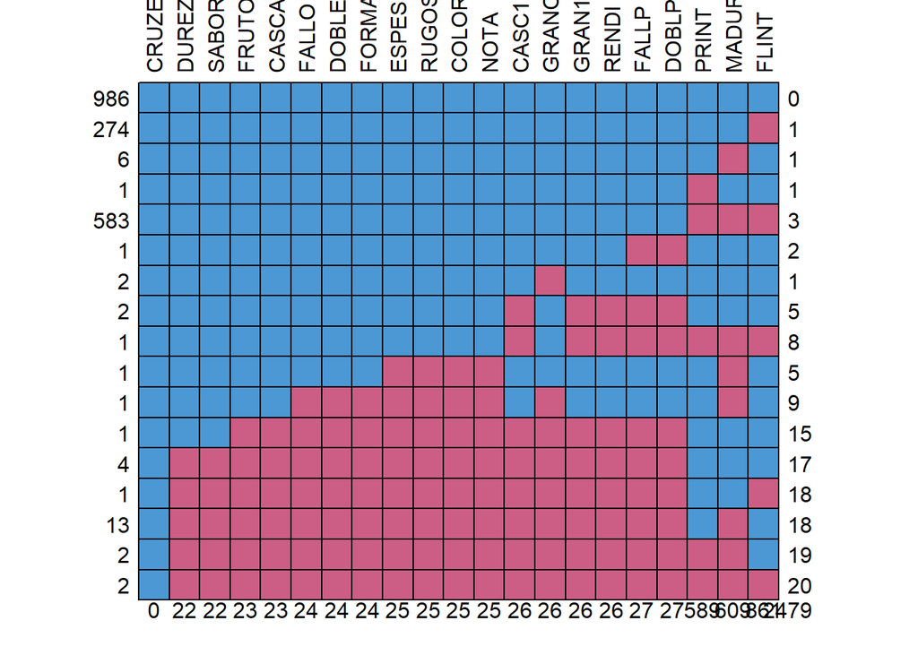

```
##     CRUZE DUREZ SABOR FRUTO CASCA FALLO DOBLE FORMA ESPES RUGOS COLOR NOTA
## 986     1     1     1     1     1     1     1     1     1     1     1    1
## 274     1     1     1     1     1     1     1     1     1     1     1    1
## 6       1     1     1     1     1     1     1     1     1     1     1    1
## 1       1     1     1     1     1     1     1     1     1     1     1    1
## 583     1     1     1     1     1     1     1     1     1     1     1    1
## 1       1     1     1     1     1     1     1     1     1     1     1    1
## 2       1     1     1     1     1     1     1     1     1     1     1    1
## 2       1     1     1     1     1     1     1     1     1     1     1    1
## 1       1     1     1     1     1     1     1     1     1     1     1    1
## 1       1     1     1     1     1     1     1     1     0     0     0    0
## 1       1     1     1     1     1     0     0     0     0     0     0    0
## 1       1     1     1     0     0     0     0     0     0     0     0    0
## 4       1     0     0     0     0     0     0     0     0     0     0    0
## 1       1     0     0     0     0     0     0     0     0     0     0    0
```

[output cut: 23 more lines]

```r
library(forcats)
data <- datos[, c("CRUZE", "FLINT", "PRINT", "MADUR", "FRUTO", "CASCA", "CASC1", "DUREZ", "GRANO", "GRAN1", "RENDI", "FALLO", "FALLP", "DOBLE", "DOBLP", "FORMA", "ESPES", "RUGOS", "COLOR", "SABOR", "NOTA")]
md.pattern(data,rotate.names = T)
```

```r
library(dplyr)
datosred <- data[complete.cases(data), ]
table(datosred$CRUZE)
```

```
##
##            A1353XA1353          A2146XDesmayo          A2198XMarcona
##                      3                     17                     16
##        A2198XNonpareil      AntonetaXAntoneta       AntonetaXMarcona
##                      1                     20                     58
##         AntonetaXMarta     AntonetaXNonpareil          C1126XMarcona
##                     23                      1                      7
##         C3091XLauranne          D00i072XA2198        D00i072XD01i466
##                      2                      2                     24
##        D00i072XD01i467        D00i072XD01i560        D00i072XD98i672
##                      3                      2                     16
##          D00i072XR1000        D00i078XD00i072        D00i078XD00i078
##                      8                      5                     25
##        D00i078XD01i466        D00i078XD01i467        D00i078XD98i672
##                     17                     38                     28
##        D00i078XMarcona      D00i078XNonpareil          D00i127XA2198
##                      2                      2                     14
##        D00i127XD00i072        D00i127XD01i466          D00i127XR1000
##                      3                      6                      1
##        D00i203XD00i203        D01i203XD01i203        D01i466XD00i078
##                      6                     12                      2
##        D01i467XD00i072        D01i467XD00i078        D01i467XD01i560
##                      3                     14                      1
##      D01i467XNonpareil        D01i560XD01i467        D98i672XD00i072
##                      5                      2                      1
##        D98i672XD01i560       D98i694XAntoneta          D98i694XMarta
##                      5                      4                     10
##       D98i707XAntoneta FerrxTuono283XAntoneta    FerrxTuono283XMarta
##                      3                      2                      4
##      GlorietaXAntoneta         GlorietaXMarta        MarconaXD01i188
##                      6                      2                     10
##         MartaXAntoneta            MartaXMarta     MasboveraXAntoneta
##                     30                     13                      8
##        MasboveraXMarta            R1000XA2198          R1000XD01i466
##                      2                      4                     16
##          R1000XD98i694          R1000XD98i707            R1000XS5133
##                     19                     43                     30
##          S2332XDesmayo        S2332XRamillete          S4017XMarcona
##                      5                     33                     50
##            S5133XA2198         S5133XAntoneta    S5133XFerrxTuono283
##                     76                     20                      4
##         S5133XLauranne            S5133XMarta        S5133XPscoparia
##                     35                     34                      3
##           S5133XPwebbi            S5133XR1000
##                     33                     92
```

# 3. TEST DE SHAPIRO-WILK

Vamos a llevart a cabo un saphiro-test para ver la normalidad de las variables

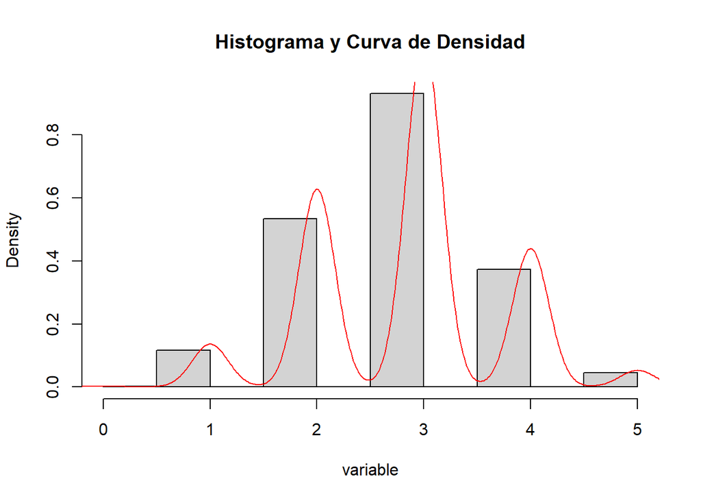

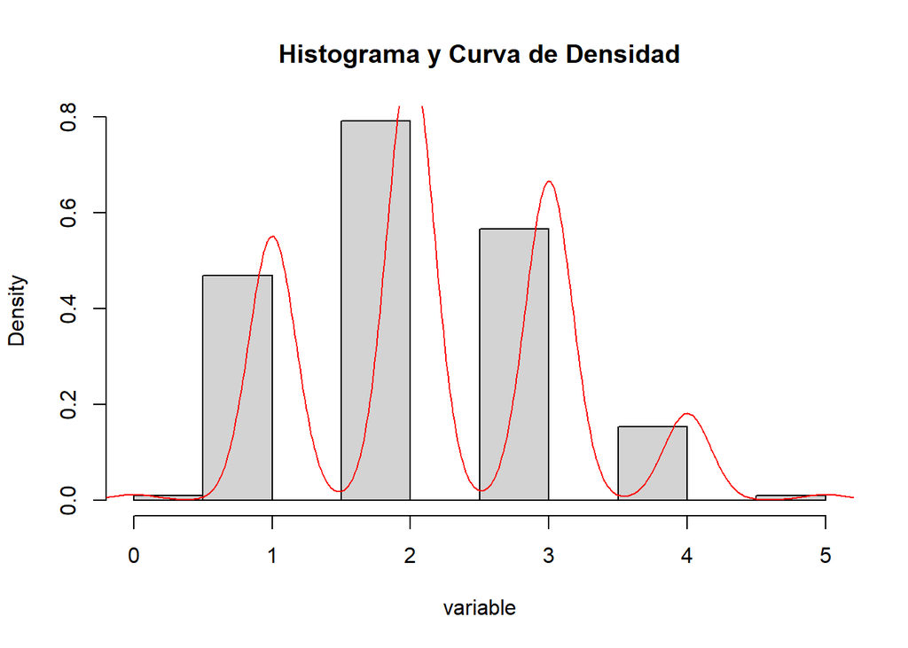

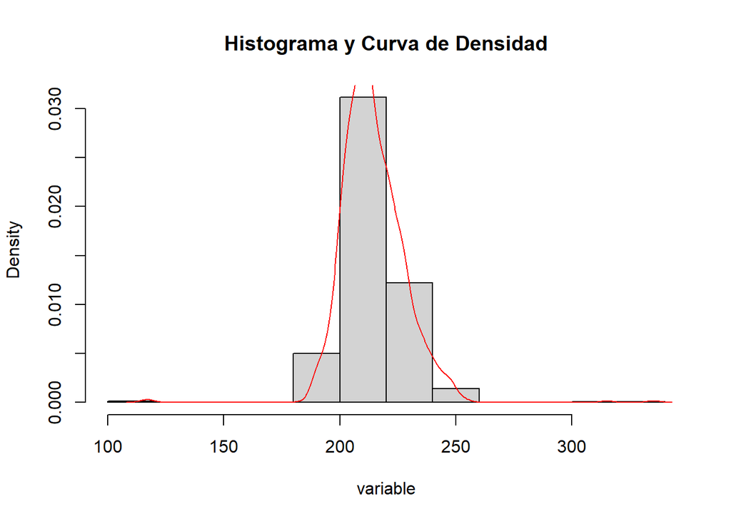

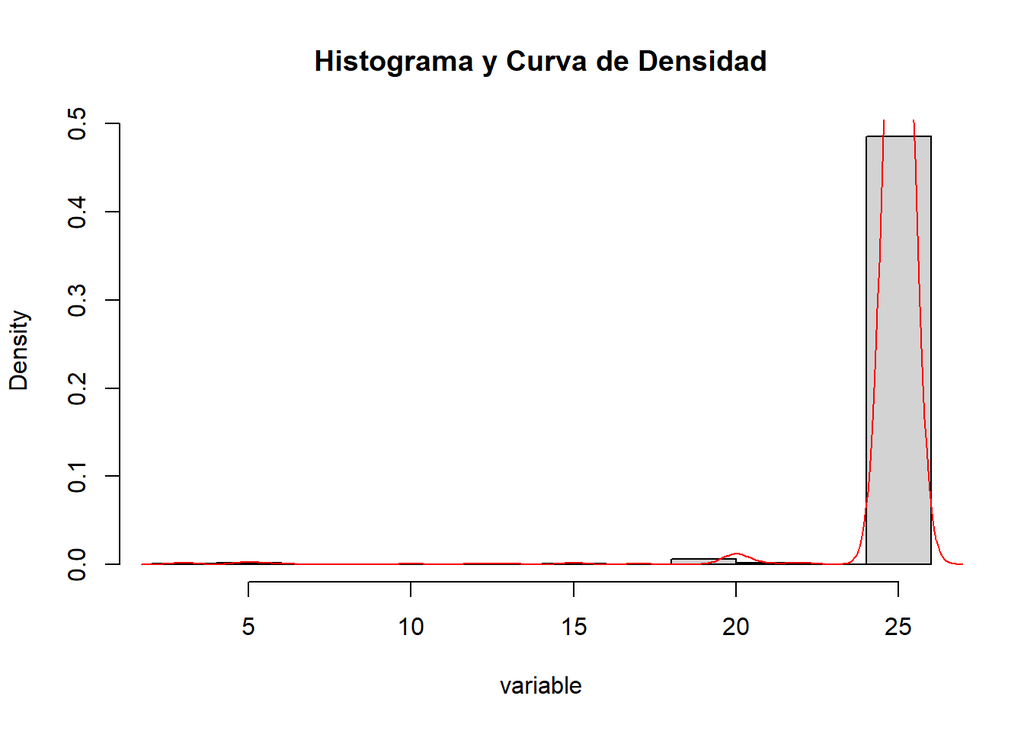

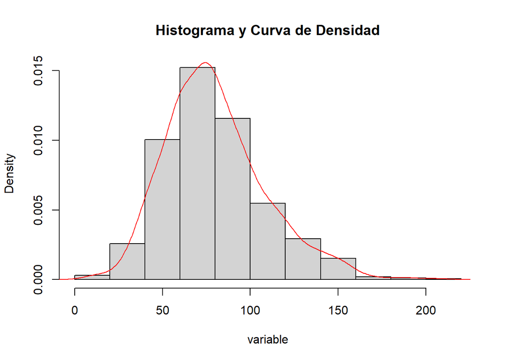

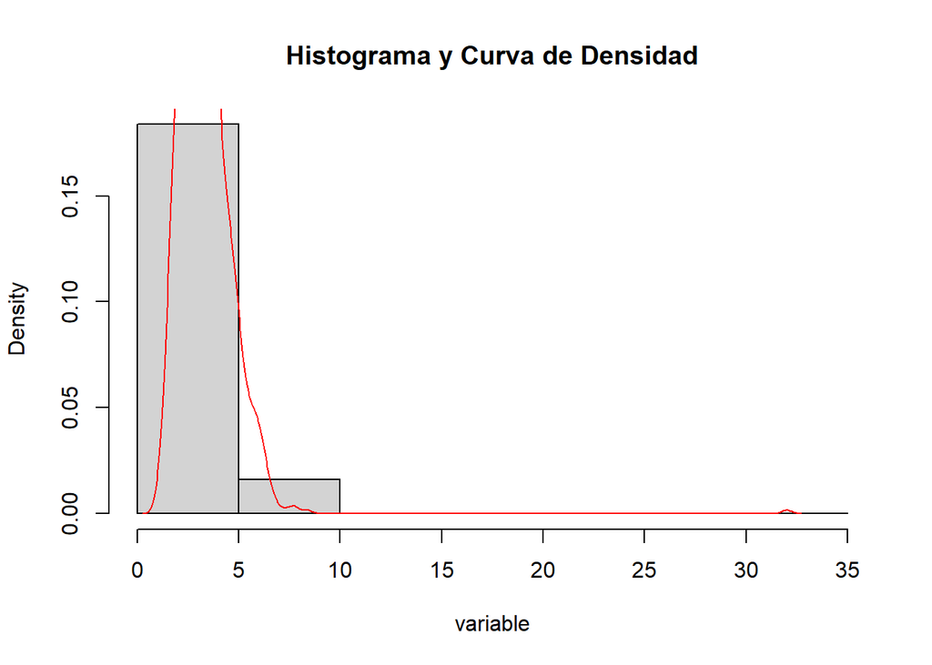

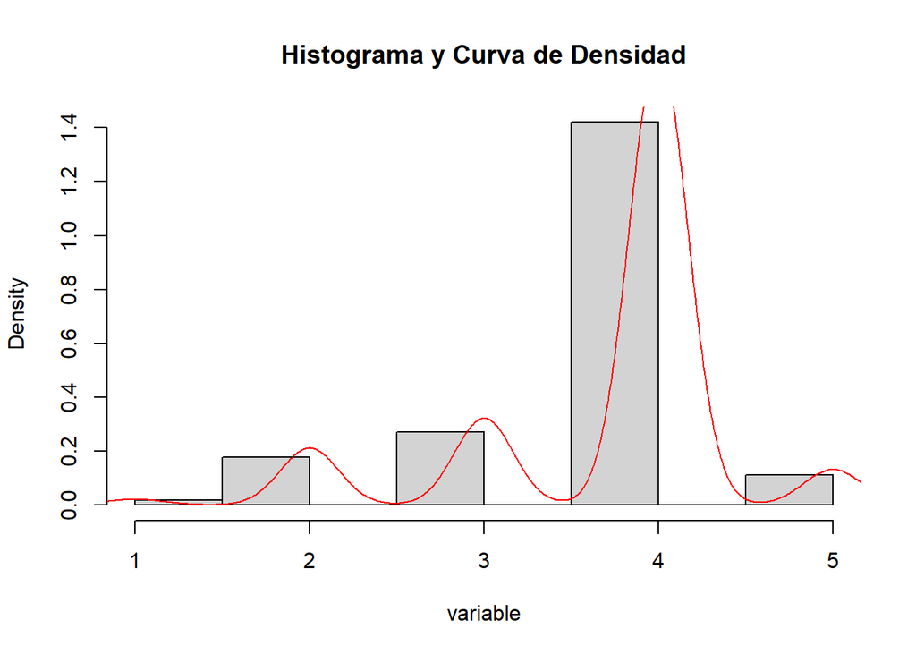

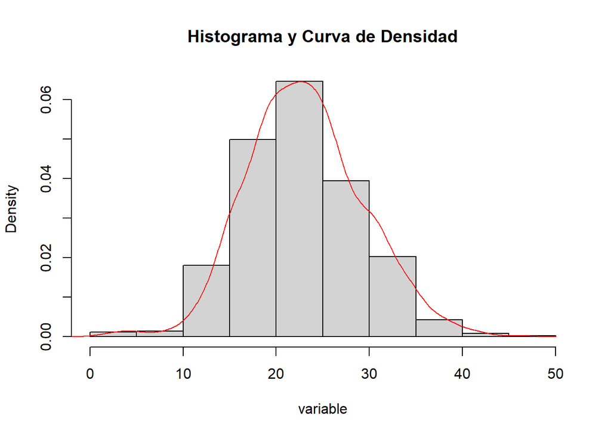

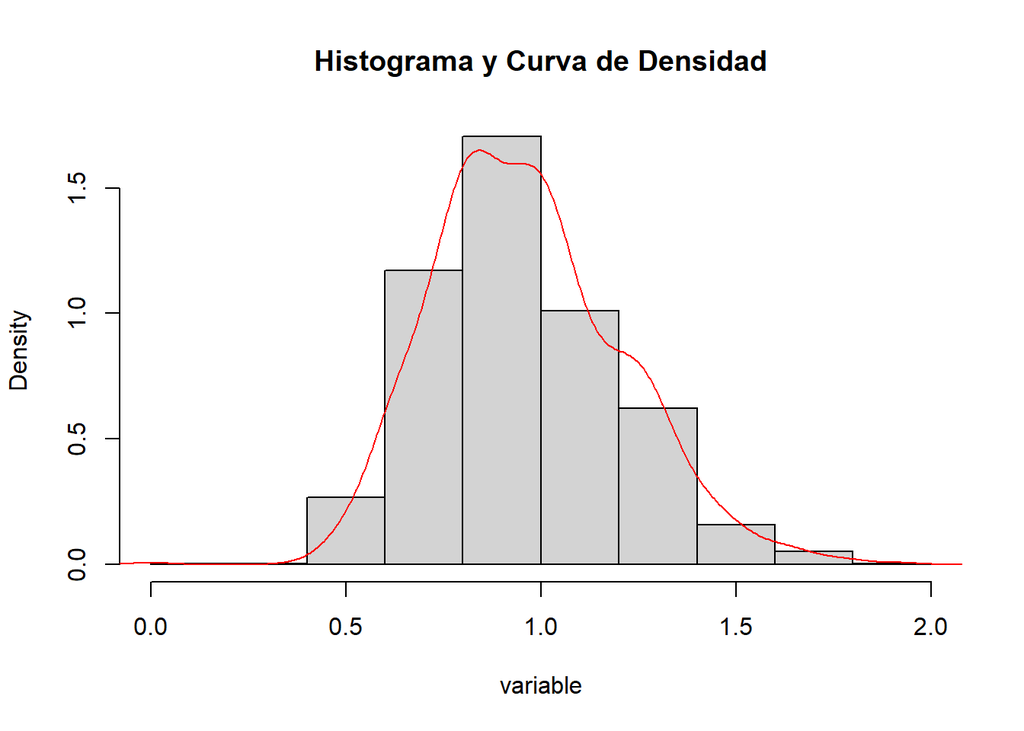

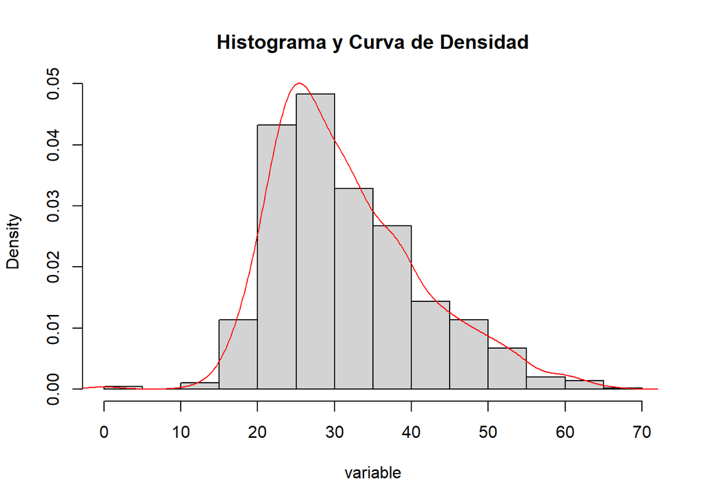

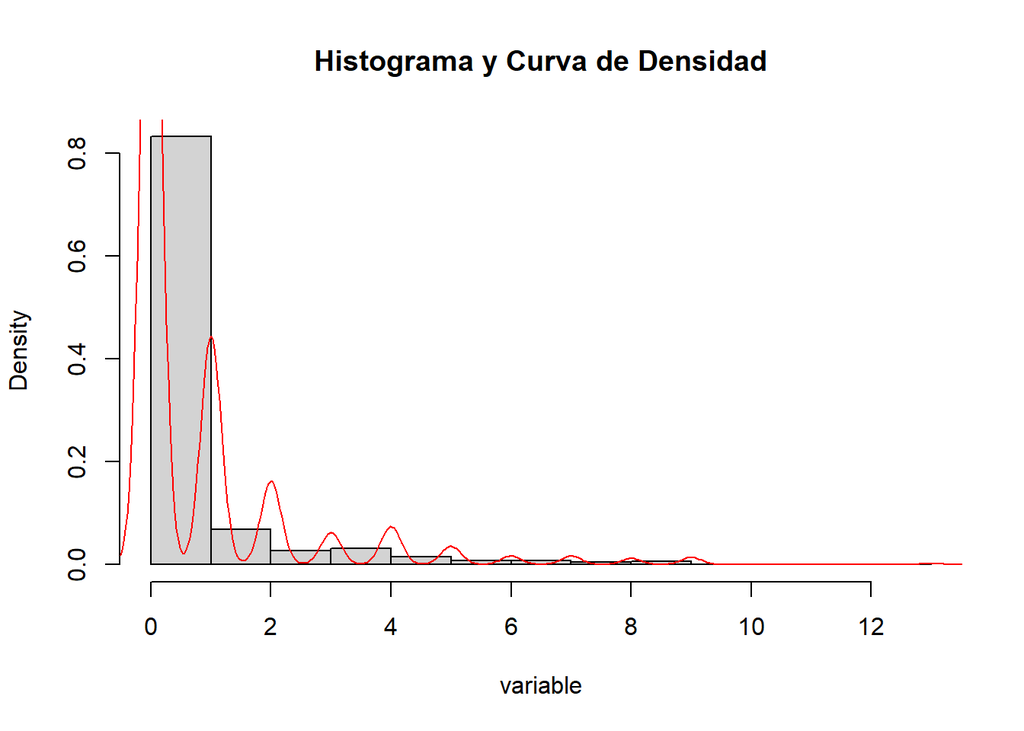

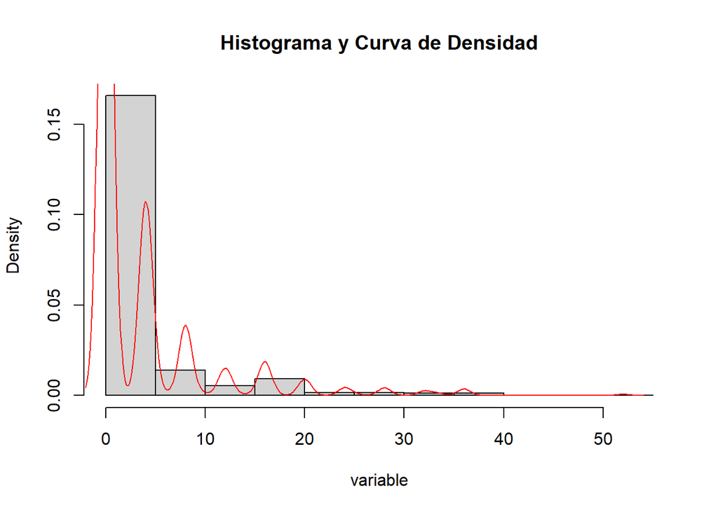

[8 more figures not shown]

```r
# Función para realizar la prueba de normalidad (Shapiro-Wilk) y generar el gráfico
perform_normality_test <- function(variable) {
  # Prueba de normalidad (Shapiro-Wilk)
  normality_test <- shapiro.test(variable)

  # Gráfico de histograma y curva de densidad
  hist(variable, freq = FALSE, main = "Histograma y Curva de Densidad")
  lines(density(variable), col = "red")

  # Retornar el resultado de la prueba de normalidad
  return(normality_test)
}

# Aplicar la función a todas las variables del conjunto de datos
normality_results <- lapply(datosred[, 2:21], perform_normality_test)
```

```r
# Imprimir los resultados de las pruebas de normalidad
names(normality_results) <- colnames(data[, 2:21])
print(normality_results)
```

```
## $FLINT
##
##  Shapiro-Wilk normality test
##
## data:  variable
## W = 0.88854, p-value < 2.2e-16
##
##
## $PRINT
##
##  Shapiro-Wilk normality test
##
## data:  variable
## W = 0.88683, p-value < 2.2e-16
##
##
## $MADUR
##
##  Shapiro-Wilk normality test
##
## data:  variable
## W = 0.89493, p-value < 2.2e-16
##
##
## $FRUTO
##
##  Shapiro-Wilk normality test
##
## data:  variable
## W = 0.12778, p-value < 2.2e-16
##
##
## $CASCA
##
##  Shapiro-Wilk normality test
##
## data:  variable
## W = 0.97252, p-value = 1.048e-12
##
##
```

[output cut: 103 more lines]

```
##
## $SABOR
##
##  Shapiro-Wilk normality test
##
## data:  variable
## W = 0.32262, p-value < 2.2e-16
##
##
## $NOTA
##
##  Shapiro-Wilk normality test
##
## data:  variable
## W = 0.87884, p-value < 2.2e-16
```

Podemos observar como no se distribuyen de forma normal. Tendremos que utilizar métodos no paramétricos.

# 4. ANALISIS DE CORRELACION

```r
library(corrplot)
library(ggplot2)
# Calcular la matriz de correlación
datosred.cor <- cor(datosred[,2:21], method = "spearman")
round(datosred.cor, digits = 2) #Redondeamos los datos a dos digitos.
```

```
##       FLINT PRINT MADUR FRUTO CASCA CASC1 DUREZ GRANO GRAN1 RENDI FALLO FALLP
## FLINT  1.00  0.39  0.13  0.12 -0.08 -0.11  0.04 -0.05 -0.08  0.07 -0.05 -0.06
## PRINT  0.39  1.00  0.06  0.19  0.05  0.01  0.11  0.18  0.10  0.07 -0.24 -0.24
## MADUR  0.13  0.06  1.00  0.06  0.23  0.23  0.12  0.25  0.28 -0.04  0.04  0.04
## FRUTO  0.12  0.19  0.06  1.00  0.18  0.04  0.08  0.22  0.06  0.02 -0.06 -0.10
## CASCA -0.08  0.05  0.23  0.18  1.00  0.97  0.48  0.55  0.53 -0.68 -0.02 -0.03
## CASC1 -0.11  0.01  0.23  0.04  0.97  1.00  0.47  0.51  0.54 -0.69  0.03  0.02
## DUREZ  0.04  0.11  0.12  0.08  0.48  0.47  1.00  0.01 -0.02 -0.57 -0.10 -0.11
## GRANO -0.05  0.18  0.25  0.22  0.55  0.51  0.01  1.00  0.95  0.18 -0.23 -0.24
## GRAN1 -0.08  0.10  0.28  0.06  0.53  0.54 -0.02  0.95  1.00  0.18 -0.04 -0.05
## RENDI  0.07  0.07 -0.04  0.02 -0.68 -0.69 -0.57  0.18  0.18  1.00 -0.05 -0.05
## FALLO -0.05 -0.24  0.04 -0.06 -0.02  0.03 -0.10 -0.23 -0.04 -0.05  1.00  1.00
## FALLP -0.06 -0.24  0.04 -0.10 -0.03  0.02 -0.11 -0.24 -0.05 -0.05  1.00  1.00
## DOBLE -0.07  0.11 -0.02  0.09  0.11  0.09  0.04  0.27  0.23  0.10 -0.09 -0.09
## DOBLP -0.07  0.11 -0.03  0.09  0.11  0.10  0.04  0.27  0.23  0.09 -0.09 -0.09
## FORMA -0.13 -0.10  0.06  0.02  0.27  0.27  0.07  0.19  0.20 -0.16  0.05  0.05
## ESPES  0.19  0.26  0.11  0.04 -0.22 -0.23  0.04  0.06  0.02  0.26 -0.18 -0.18
## RUGOS -0.15 -0.09 -0.19 -0.01  0.11  0.12 -0.06  0.11  0.12 -0.04  0.04  0.03
## COLOR -0.06  0.06  0.15  0.04  0.13  0.12  0.01  0.15  0.14 -0.03 -0.03 -0.03
## SABOR  0.09  0.00  0.19  0.03  0.08  0.08 -0.01  0.08  0.08 -0.02  0.03  0.04
## NOTA   0.08  0.20  0.21  0.09  0.35  0.33  0.17  0.48  0.42 -0.06 -0.29 -0.29
##       DOBLE DOBLP FORMA ESPES RUGOS COLOR SABOR  NOTA
## FLINT -0.07 -0.07 -0.13  0.19 -0.15 -0.06  0.09  0.08
## PRINT  0.11  0.11 -0.10  0.26 -0.09  0.06  0.00  0.20
## MADUR -0.02 -0.03  0.06  0.11 -0.19  0.15  0.19  0.21
## FRUTO  0.09  0.09  0.02  0.04 -0.01  0.04  0.03  0.09
## CASCA  0.11  0.11  0.27 -0.22  0.11  0.13  0.08  0.35
## CASC1  0.09  0.10  0.27 -0.23  0.12  0.12  0.08  0.33
## DUREZ  0.04  0.04  0.07  0.04 -0.06  0.01 -0.01  0.17
## GRANO  0.27  0.27  0.19  0.06  0.11  0.15  0.08  0.48
## GRAN1  0.23  0.23  0.20  0.02  0.12  0.14  0.08  0.42
## RENDI  0.10  0.09 -0.16  0.26 -0.04 -0.03 -0.02 -0.06
## FALLO -0.09 -0.09  0.05 -0.18  0.04 -0.03  0.03 -0.29
## FALLP -0.09 -0.09  0.05 -0.18  0.03 -0.03  0.04 -0.29
## DOBLE  1.00  1.00 -0.01  0.06 -0.03 -0.03  0.02 -0.01
## DOBLP  1.00  1.00  0.00  0.06 -0.03 -0.03  0.02 -0.01
## FORMA -0.01  0.00  1.00 -0.01  0.15  0.07 -0.03  0.08
## ESPES  0.06  0.06 -0.01  1.00 -0.19 -0.07 -0.07  0.12
## RUGOS -0.03 -0.03  0.15 -0.19  1.00  0.28 -0.02 -0.12
## COLOR -0.03 -0.03  0.07 -0.07  0.28  1.00  0.09  0.05
## SABOR  0.02  0.02 -0.03 -0.07 -0.02  0.09  1.00  0.30
## NOTA  -0.01 -0.01  0.08  0.12 -0.12  0.05  0.30  1.00
```

Utilizamos la función corrplot para representar los resultados y observar las correlaciones existentes entre las distintas variables numericas.

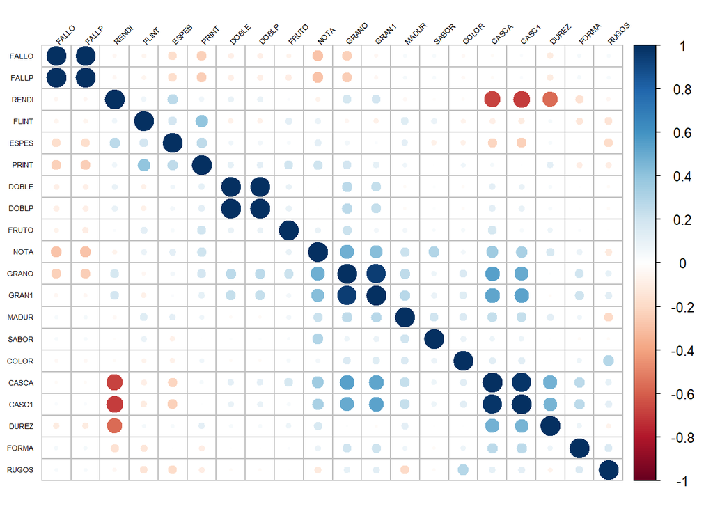

```r
corrplot(datosred.cor, tl.cex = 0.45, method = "circle", shade.col = NA, tl.col = "black", tl.srt = 45, order = "AOE", diag = T, win.asp = 0.75)
```

Aqui observamos las correlaciones entre las distintas variables.

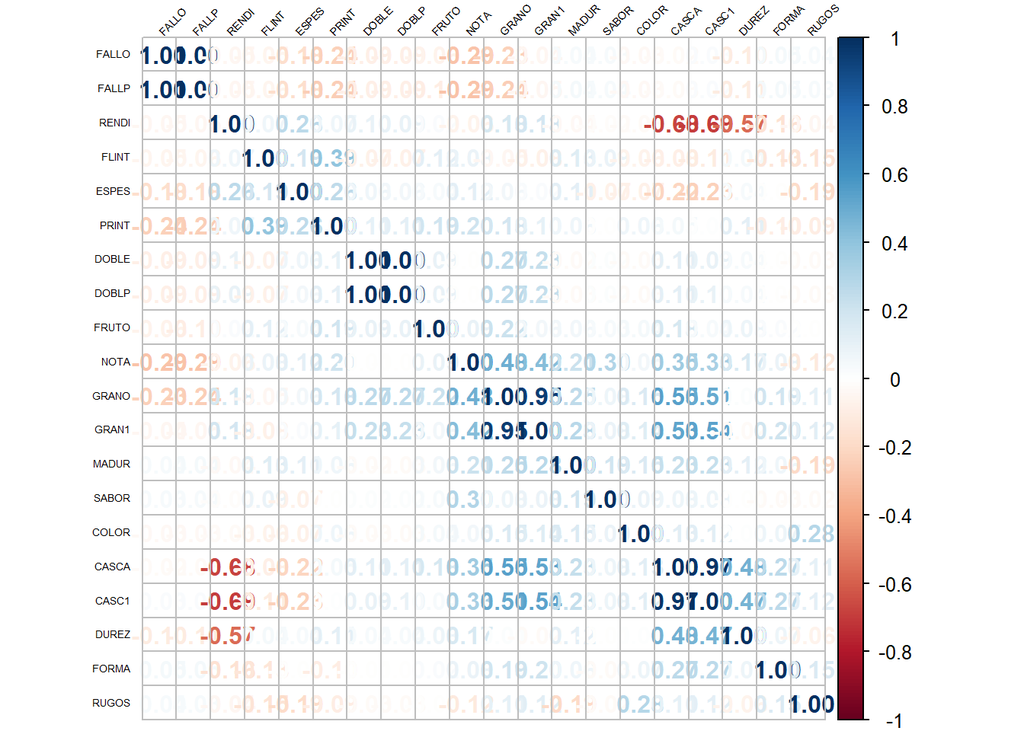

```r
corrplot(datosred.cor, tl.cex = 0.45, method = "number", shade.col = NA, tl.col = "black", tl.srt = 45, order = "AOE", diag = T)
```

# 5. GENERACION DE MODELOS MULTIPLES PARA CRUCE

Seleccionamos los cruces con mas de 15 observaciones

```r
# Calcular el recuento de observaciones por cruce
recuentocruces <- table(datosred$CRUZE)

# Obtener los cruces con más de 15 observaciones
crucessel <- names(recuentocruces)[recuentocruces > 15]

# Crear un nuevo conjunto de datos con los cruces seleccionados
datosc <- datosred[datosred$CRUZE %in% crucessel, ]
```

```r
datosc$CRUZE <- as.factor(datosc$CRUZE)
table(datosc$CRUZE)
```

```
##
##     A2146XDesmayo     A2198XMarcona AntonetaXAntoneta  AntonetaXMarcona
##                17                16                20                58
##    AntonetaXMarta   D00i072XD01i466   D00i072XD98i672   D00i078XD00i078
##                23                24                16                25
##   D00i078XD01i466   D00i078XD01i467   D00i078XD98i672    MartaXAntoneta
##                17                38                28                30
##     R1000XD01i466     R1000XD98i694     R1000XD98i707       R1000XS5133
##                16                19                43                30
##   S2332XRamillete     S4017XMarcona       S5133XA2198    S5133XAntoneta
##                33                50                76                20
##    S5133XLauranne       S5133XMarta      S5133XPwebbi       S5133XR1000
##                35                34                33                92
```

```r
str(datosc)
```

```
## tibble [793 × 21] (S3: tbl_df/tbl/data.frame)
##  $ CRUZE: Factor w/ 24 levels "A2146XDesmayo",..: 24 24 24 24 24 24 24 24 24 24 ...
##  $ FLINT: num [1:793] 3 3 3 3 2 2 3 3 3 2 ...
##  $ PRINT: num [1:793] 2 3 1 3 1 1 2 1 2 1 ...
##  $ MADUR: num [1:793] 221 235 224 208 208 214 211 208 214 207 ...
##  $ FRUTO: num [1:793] 25 25 25 25 25 25 25 20 25 25 ...
##  $ CASCA: num [1:793] 83 44 50 69 77 40 53 30 69 69 ...
##  $ CASC1: num [1:793] 3.32 1.76 2.12 2.76 3.11 ...
##  $ DUREZ: num [1:793] 5 2 2 4 4 2 3 2 4 4 ...
##  $ GRANO: num [1:793] 23 23 22 23 18 14 23 12 19 22 ...
##  $ GRAN1: num [1:793] 0.92 0.92 1 0.92 0.75 ...
##  $ RENDI: num [1:793] 27.7 52.3 47.2 33.3 24.1 ...
##  $ FALLO: num [1:793] 0 0 3 0 1 8 1 5 0 1 ...
##  $ FALLP: num [1:793] 0 0 12 0 4 32 4 25 0 4 ...
##  $ DOBLE: num [1:793] 0 1 0 14 0 0 0 0 0 3 ...
##  $ DOBLP: num [1:793] 0 4 0 56 0 0 0 0 0 12 ...
##  $ FORMA: num [1:793] 11 5 4 4 8 7 8 1 5 4 ...
##  $ ESPES: num [1:793] 2 3 2 2 2 1 2 2 3 2 ...
##  $ RUGOS: num [1:793] 1 1 2 2 2 1 3 2 2 2 ...
##  $ COLOR: num [1:793] 2 4 2 1 1 2 3 3 2 2 ...
##  $ SABOR: num [1:793] 3 3 3 2 3 3 3 3 3 3 ...
##  $ NOTA : num [1:793] 3 3 3 2 2 2 3 1 2 3 ...
```

Ahora visualizamos de forma grafica el numero de niveles por cruce

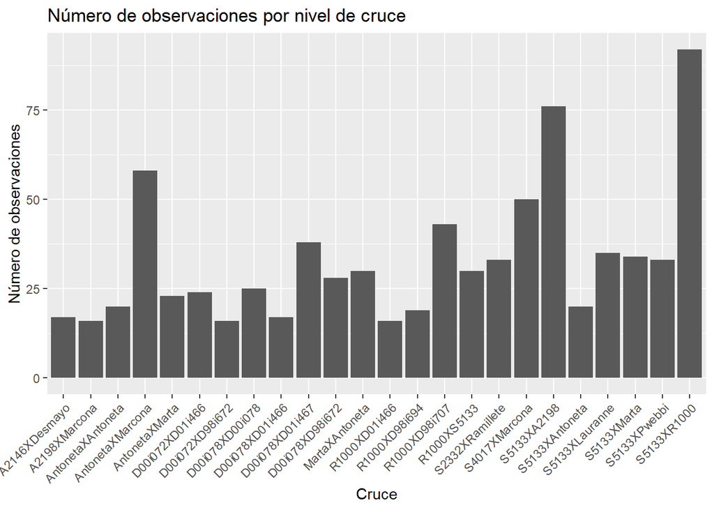

```r
ggplot(datosc, aes(x = CRUZE)) +
  geom_bar() +
  labs(x = "Cruce", y = "Número de observaciones", title = "Número de observaciones por nivel de cruce") +
  theme(axis.text.x = element_text(angle = 45, hjust = 1))
```

## 5.1 SELECCION DE VARIABLES POR RANDOM FOREST

En este punto podemos llevar a cabo la seleccion de variables para luego comprobar los resultados.

```r
library(caret)
set.seed(12345)
datoscpart <- createDataPartition(datosc$CRUZE,p=0.8,list = FALSE)
datosc.train <- datosc[datoscpart,]
datosc.test <- datosc[-datoscpart,]
```

```r
subsets <- c(3:21) #Indicamos que cree subgrupos de entre 3 y 21 variables.

seeds <- vector(mode = "list", length = 6)

for(i in 1:10) seeds[[i]] <- sample.int(1000, length(subsets) + 1)
seeds[[11]] <- sample.int(1000, 1)

ctrl.treebag.rfe.cv.10 <- rfeControl(functions=rfFuncs ,
                                     method = "cv",
                                     number = 10,
                                     seeds = seeds,
                                     returnResamp="final",
                                     verbose = TRUE,
                                     allowParallel = TRUE)
```

```r
treebag.rfe.cv.10 <- rfe(CRUZE~., data=datosc.train,
                         sizes=subsets,
                         rfeControl=ctrl.treebag.rfe.cv.10)
```

Le quitamos el contenido de fit, para que no tenga tanto peso el archivo y guardammos el rds.

```r
treebag.rfe.cv.10$fit = NULL
saveRDS(treebag.rfe.cv.10, "C:/Users/gonza/Documents/TFM/treebag.fre.cv.10.rds")
```

```r
varseleccruce <- readRDS("C:/Users/gonza/Documents/TFM/treebag.fre.cv.10.rds")
varseleccruce$optVariables
```

```
##  [1] "MADUR" "GRANO" "GRAN1" "RENDI" "SABOR" "CASCA" "CASC1" "FORMA" "NOTA"
## [10] "COLOR" "PRINT" "ESPES" "RUGOS" "FLINT" "DUREZ"
```

Nuestro modelo nos dice que las variables que mayor importancia tienen son: “MADUR” “GRAN1” “GRANO” “RENDI” “SABOR” “CASCA” “CASC1” “FORMA” “NOTA” “COLOR” “PRINT” “DUREZ” “ESPES” “RUGOS” “FLINT”

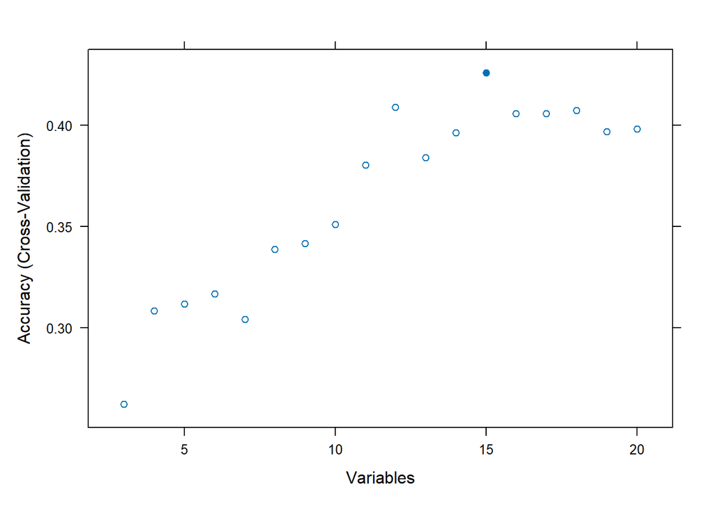

```r
plot(varseleccruce)
```

```r
varseleccruce$results
```

```
##    Variables  Accuracy     Kappa AccuracySD    KappaSD
## 1          3 0.2624254 0.2149122 0.04353030 0.04463699
## 2          4 0.3085785 0.2652608 0.07047352 0.07563433
## 3          5 0.3119326 0.2679492 0.07067244 0.07585148
## 4          6 0.3167465 0.2711863 0.07338867 0.07912748
## 5          7 0.3043987 0.2569353 0.06600379 0.07109281
## 6          8 0.3388761 0.2943088 0.05039415 0.05303694
## 7          9 0.3417737 0.2980345 0.05800187 0.06381063
## 8         10 0.3511299 0.3077388 0.04352157 0.04719651
## 9         11 0.3804211 0.3377672 0.05425901 0.05858121
## 10        12 0.4086601 0.3673152 0.05031967 0.05414924
## 11        13 0.3839589 0.3410311 0.04073325 0.04466359
## 12        14 0.3961446 0.3540075 0.04513602 0.04942474
## 13        15 0.4258343 0.3866440 0.05920374 0.06440081
## 14        16 0.4056266 0.3656887 0.05394631 0.05905284
## 15        17 0.4057197 0.3646448 0.04580701 0.05096531
## 16        18 0.4072107 0.3662318 0.03494120 0.04004773
## 17        19 0.3967110 0.3542957 0.03244541 0.03673948
## 18        20 0.3979817 0.3561729 0.04380500 0.04876183
```

```r
varseleccruce$bestSubset
```

```
## [1] 15
```

## 5.2 GENERACION DE MODELOS MULTIPLES CON DATOS SELECCION DE VARIABLES

```r
datoscsv <- datosc[,c("CRUZE", "MADUR", "GRAN1", "GRANO", "RENDI", "SABOR", "CASCA", "CASC1", "FORMA", "NOTA", "COLOR", "PRINT", "DUREZ", "ESPES", "RUGOS", "FLINT")]
```

Primero balanceamos los datos

```r
# Crear una tabla con el recuento de los niveles de la variable "cruce"
tablacrucesv <- table(datoscsv$CRUZE)

# Encontrar el nivel con el menor número de observaciones
minobscsv <- min(tablacrucesv)

# Crear una lista vacía para almacenar los datos balanceados
datosbcrucesv <- data.frame()

# Iterar sobre cada nivel de la variable "cruce"
for (nivel in levels(datoscsv$CRUZE)) {
  # Subconjunto de datos para el nivel actual
  datosnivelcsv <- subset(datoscsv, CRUZE == nivel)

  # Muestreo aleatorio de observaciones para igualar el número mínimo de observaciones
  datosmuestrcsv <- datosnivelcsv[sample(1:nrow(datosnivelcsv), minobscsv), ]

  # Agregar los datos muestreados al conjunto de datos balanceados
  datosbcrucesv <- rbind(datosbcrucesv, datosmuestrcsv)
}

# Verificar el balance resultante
table(datosbcrucesv$CRUZE)
```

```
##
##     A2146XDesmayo     A2198XMarcona AntonetaXAntoneta  AntonetaXMarcona
##                16                16                16                16
##    AntonetaXMarta   D00i072XD01i466   D00i072XD98i672   D00i078XD00i078
##                16                16                16                16
##   D00i078XD01i466   D00i078XD01i467   D00i078XD98i672    MartaXAntoneta
##                16                16                16                16
##     R1000XD01i466     R1000XD98i694     R1000XD98i707       R1000XS5133
##                16                16                16                16
##   S2332XRamillete     S4017XMarcona       S5133XA2198    S5133XAntoneta
##                16                16                16                16
##    S5133XLauranne       S5133XMarta      S5133XPwebbi       S5133XR1000
##                16                16                16                16
```

Creamos los datos de entrenamiento y de test.

```r
datoscsv.id <- createDataPartition(datosbcrucesv$CRUZE,p=0.8,list = FALSE)
datoscsv.tr <- datosbcrucesv[datoscsv.id,]
datoscsv.te <- datosbcrucesv[-datoscsv.id,]
datoscsv.tr_x <- datoscsv.tr
datoscsv.tr_x$CRUZE=NULL

table(datoscsv.tr$CRUZE)
```

```
##
##     A2146XDesmayo     A2198XMarcona AntonetaXAntoneta  AntonetaXMarcona
##                13                13                13                13
##    AntonetaXMarta   D00i072XD01i466   D00i072XD98i672   D00i078XD00i078
##                13                13                13                13
##   D00i078XD01i466   D00i078XD01i467   D00i078XD98i672    MartaXAntoneta
##                13                13                13                13
##     R1000XD01i466     R1000XD98i694     R1000XD98i707       R1000XS5133
##                13                13                13                13
##   S2332XRamillete     S4017XMarcona       S5133XA2198    S5133XAntoneta
##                13                13                13                13
##    S5133XLauranne       S5133XMarta      S5133XPwebbi       S5133XR1000
##                13                13                13                13
```

### 5.2.1 Modelo ranger

```r
TrainCtrlRanger.3cv10 <- trainControl( # Crosvalidación de 10 pliegues con 3 repeticiones
  method = "repeatedcv",
  number = 10,
  repeats = 3,
  verboseIter=TRUE)
```

```r
modeloranger.3cv10.crucesv <- train(x = datoscsv.tr_x,
                         y = datoscsv.tr$CRUZE,
                         method = "ranger",  #En este caso el metodo ranger
                         trControl = TrainCtrlRanger.3cv10)
```

```r
saveRDS(modeloranger.3cv10.crucesv, "modelorangercrucesv.rds")
```

```r
modelorangercrucesv <- readRDS("C:/Users/gonza/Documents/TFM/modelorangercrucesv.rds")
modelorangercrucesv
```

```
## Random Forest
##
## 312 samples
##  15 predictor
##  24 classes: 'A2146XDesmayo', 'A2198XMarcona', 'AntonetaXAntoneta', 'AntonetaXMarcona', 'AntonetaXMarta', 'D00i072XD01i466', 'D00i072XD98i672', 'D00i078XD00i078', 'D00i078XD01i466', 'D00i078XD01i467', 'D00i078XD98i672', 'MartaXAntoneta', 'R1000XD01i466', 'R1000XD98i694', 'R1000XD98i707', 'R1000XS…
##
## No pre-processing
## Resampling: Cross-Validated (10 fold, repeated 3 times)
## Summary of sample sizes: 276, 280, 281, 284, 280, 285, ...
## Resampling results across tuning parameters:
##
##   mtry  splitrule   Accuracy   Kappa
##    2    gini        0.3437771  0.3152139
##    2    extratrees  0.3581555  0.3300614
##    8    gini        0.3230202  0.2938053
##    8    extratrees  0.3571720  0.3286813
##   15    gini        0.3157864  0.2860964
##   15    extratrees  0.3409695  0.3120066
##
## Tuning parameter 'min.node.size' was held constant at a value of 1
## Accuracy was used to select the optimal model using the largest value.
## The final values used for the model were mtry = 2, splitrule = extratrees
##  and min.node.size = 1.
```

```
## Confusion Matrix and Statistics
##
##                    Reference
## Prediction          A2146XDesmayo A2198XMarcona AntonetaXAntoneta
##   A2146XDesmayo                 3             0                 0
##   A2198XMarcona                 0             3                 0
##   AntonetaXAntoneta             0             0                 3
##   AntonetaXMarcona              0             0                 0
##   AntonetaXMarta                0             0                 0
##   D00i072XD01i466               0             0                 0
##   D00i072XD98i672               0             0                 0
##   D00i078XD00i078               0             0                 0
##   D00i078XD01i466               0             0                 0
##   D00i078XD01i467               0             0                 0
##   D00i078XD98i672               0             0                 0
##   MartaXAntoneta                0             0                 0
##   R1000XD01i466                 0             0                 0
##   R1000XD98i694                 0             0                 0
##   R1000XD98i707                 0             0                 0
##   R1000XS5133                   0             0                 0
##   S2332XRamillete               0             0                 0
##   S4017XMarcona                 0             0                 0
##   S5133XA2198                   0             0                 0
##   S5133XAntoneta                0             0                 0
##   S5133XLauranne                0             0                 0
##   S5133XMarta                   0             0                 0
##   S5133XPwebbi                  0             0                 0
##   S5133XR1000                   0             0                 0
##                    Reference
## Prediction          AntonetaXMarcona AntonetaXMarta D00i072XD01i466
##   A2146XDesmayo                    0              0               0
##   A2198XMarcona                    0              0               0
##   AntonetaXAntoneta                0              0               0
##   AntonetaXMarcona                 3              0               0
##   AntonetaXMarta                   0              2               0
##   D00i072XD01i466                  0              0               3
##   D00i072XD98i672                  0              0               0
##   D00i078XD00i078                  0              0               0
##   D00i078XD01i466                  0              0               0
##   D00i078XD01i467                  0              0               0
```

[output cut: 251 more lines]

```
## Pos Pred Value                     0.33333            0.66667
## Neg Pred Value                     0.97101            0.98551
## Prevalence                         0.04167            0.04167
## Detection Rate                     0.01389            0.02778
## Detection Prevalence               0.04167            0.04167
## Balanced Accuracy                  0.65217            0.82609
##                      Class: S5133XPwebbi Class: S5133XR1000
## Sensitivity                      1.00000            0.33333
## Specificity                      0.98551            0.97101
## Pos Pred Value                   0.75000            0.33333
## Neg Pred Value                   1.00000            0.97101
## Prevalence                       0.04167            0.04167
## Detection Rate                   0.04167            0.01389
## Detection Prevalence             0.05556            0.04167
## Balanced Accuracy                0.99275            0.65217
```

### 5.2.2 Modelo random forest

```r
TrainCtrlRf.3cv10 <- trainControl( # Crosvalidación de 10 pliegues con 3 repeticiones
  method = "repeatedcv",
  number = 10,
  repeats = 3,
  verboseIter=TRUE)
```

```r
modelorf.3cv10.crucesv <- train(x = datoscsv.tr_x,
                         y = datoscsv.tr$CRUZE,
                         method = "rf",  #En este caso el metodo rf
                         trControl = TrainCtrlRf.3cv10)
```

```r
saveRDS(modelorf.3cv10.crucesv, "modelorfcrucesv.rds")
```

```r
modelorfcrucesv <- readRDS("C:/Users/gonza/Documents/TFM/modelorfcrucesv.rds")
modelorfcrucesv
```

```
## Random Forest
##
## 312 samples
##  15 predictor
##  24 classes: 'A2146XDesmayo', 'A2198XMarcona', 'AntonetaXAntoneta', 'AntonetaXMarcona', 'AntonetaXMarta', 'D00i072XD01i466', 'D00i072XD98i672', 'D00i078XD00i078', 'D00i078XD01i466', 'D00i078XD01i467', 'D00i078XD98i672', 'MartaXAntoneta', 'R1000XD01i466', 'R1000XD98i694', 'R1000XD98i707', 'R1000XS…
##
## No pre-processing
## Resampling: Cross-Validated (10 fold, repeated 3 times)
## Summary of sample sizes: 279, 284, 285, 282, 278, 279, ...
## Resampling results across tuning parameters:
##
##   mtry  Accuracy   Kappa
##    2    0.3186162  0.2886909
##    8    0.3253523  0.2955151
##   15    0.3287382  0.2990094
##
## Accuracy was used to select the optimal model using the largest value.
## The final value used for the model was mtry = 15.
```

```
## Confusion Matrix and Statistics
##
##                    Reference
## Prediction          A2146XDesmayo A2198XMarcona AntonetaXAntoneta
##   A2146XDesmayo                 3             0                 0
##   A2198XMarcona                 0             3                 0
##   AntonetaXAntoneta             0             0                 3
##   AntonetaXMarcona              0             0                 0
##   AntonetaXMarta                0             0                 0
##   D00i072XD01i466               0             0                 0
##   D00i072XD98i672               0             0                 0
##   D00i078XD00i078               0             0                 0
##   D00i078XD01i466               0             0                 0
##   D00i078XD01i467               0             0                 0
##   D00i078XD98i672               0             0                 0
##   MartaXAntoneta                0             0                 0
##   R1000XD01i466                 0             0                 0
##   R1000XD98i694                 0             0                 0
##   R1000XD98i707                 0             0                 0
##   R1000XS5133                   0             0                 0
##   S2332XRamillete               0             0                 0
##   S4017XMarcona                 0             0                 0
##   S5133XA2198                   0             0                 0
##   S5133XAntoneta                0             0                 0
##   S5133XLauranne                0             0                 0
##   S5133XMarta                   0             0                 0
##   S5133XPwebbi                  0             0                 0
##   S5133XR1000                   0             0                 0
##                    Reference
## Prediction          AntonetaXMarcona AntonetaXMarta D00i072XD01i466
##   A2146XDesmayo                    0              0               0
##   A2198XMarcona                    0              0               0
##   AntonetaXAntoneta                0              1               0
##   AntonetaXMarcona                 3              0               0
##   AntonetaXMarta                   0              2               0
##   D00i072XD01i466                  0              0               3
##   D00i072XD98i672                  0              0               0
##   D00i078XD00i078                  0              0               0
##   D00i078XD01i466                  0              0               0
##   D00i078XD01i467                  0              0               0
```

[output cut: 251 more lines]

```
## Pos Pred Value                     0.33333            0.50000
## Neg Pred Value                     0.97101            0.98529
## Prevalence                         0.04167            0.04167
## Detection Rate                     0.01389            0.02778
## Detection Prevalence               0.04167            0.05556
## Balanced Accuracy                  0.65217            0.81884
##                      Class: S5133XPwebbi Class: S5133XR1000
## Sensitivity                      1.00000            0.33333
## Specificity                      0.98551            0.98551
## Pos Pred Value                   0.75000            0.50000
## Neg Pred Value                   1.00000            0.97143
## Prevalence                       0.04167            0.04167
## Detection Rate                   0.04167            0.01389
## Detection Prevalence             0.05556            0.02778
## Balanced Accuracy                0.99275            0.65942
```

### 5.2.3 Modelo SVM

```r
TrainCtrlSVM.3cv10 <- trainControl( # Crosvalidación de 10 pliegues con 3 repeticiones
  method = "repeatedcv",
  number = 10,
  repeats = 3,
  verboseIter=TRUE)
```

```r
modelorsvm.3cv10.crucesv <- train(x = datoscsv.tr_x,
                         y = datoscsv.tr$CRUZE,
                         method = "svmRadial",  #En este caso el metodo svmRadial
                         trControl = TrainCtrlSVM.3cv10)
```

```r
saveRDS(modelorsvm.3cv10.crucesv, "modelosvmcrucesv.rds")
```

```r
modelosvmcrucesv <- readRDS("C:/Users/gonza/Documents/TFM/modelosvmcrucesv.rds")
modelosvmcrucesv
```

```
## Support Vector Machines with Radial Basis Function Kernel
##
## 312 samples
##  15 predictor
##  24 classes: 'A2146XDesmayo', 'A2198XMarcona', 'AntonetaXAntoneta', 'AntonetaXMarcona', 'AntonetaXMarta', 'D00i072XD01i466', 'D00i072XD98i672', 'D00i078XD00i078', 'D00i078XD01i466', 'D00i078XD01i467', 'D00i078XD98i672', 'MartaXAntoneta', 'R1000XD01i466', 'R1000XD98i694', 'R1000XD98i707', 'R1000XS…
##
## No pre-processing
## Resampling: Cross-Validated (10 fold, repeated 3 times)
## Summary of sample sizes: 280, 285, 281, 278, 281, 277, ...
## Resampling results across tuning parameters:
##
##   C     Accuracy   Kappa
##   0.25  0.2167407  0.1902957
##   0.50  0.2993347  0.2724082
##   1.00  0.3394871  0.3110546
##
## Tuning parameter 'sigma' was held constant at a value of 0.05244696
## Accuracy was used to select the optimal model using the largest value.
## The final values used for the model were sigma = 0.05244696 and C = 1.
```

```
## Confusion Matrix and Statistics
##
##                    Reference
## Prediction          A2146XDesmayo A2198XMarcona AntonetaXAntoneta
##   A2146XDesmayo                 0             0                 0
##   A2198XMarcona                 0             0                 0
##   AntonetaXAntoneta             0             0                 0
##   AntonetaXMarcona              0             0                 0
##   AntonetaXMarta                0             0                 0
##   D00i072XD01i466               0             0                 0
##   D00i072XD98i672               0             0                 0
##   D00i078XD00i078               0             0                 0
##   D00i078XD01i466               0             0                 0
##   D00i078XD01i467               0             0                 0
##   D00i078XD98i672               0             0                 0
##   MartaXAntoneta                0             0                 0
##   R1000XD01i466                 0             0                 0
##   R1000XD98i694                 0             0                 0
##   R1000XD98i707                 0             0                 0
##   R1000XS5133                   0             0                 0
##   S2332XRamillete               0             0                 0
##   S4017XMarcona                 0             0                 0
##   S5133XA2198                   0             0                 0
##   S5133XAntoneta                0             0                 0
##   S5133XLauranne                0             0                 0
##   S5133XMarta                   0             0                 0
##   S5133XPwebbi                  0             0                 0
##   S5133XR1000                   0             0                 0
##                    Reference
## Prediction          AntonetaXMarcona AntonetaXMarta D00i072XD01i466
##   A2146XDesmayo                    0              0               0
##   A2198XMarcona                    0              0               0
##   AntonetaXAntoneta                0              0               0
##   AntonetaXMarcona                 0              0               0
##   AntonetaXMarta                   0              0               0
##   D00i072XD01i466                  0              0               0
##   D00i072XD98i672                  0              0               0
##   D00i078XD00i078                  0              0               0
##   D00i078XD01i466                  0              0               0
##   D00i078XD01i467                  0              0               0
```

[output cut: 251 more lines]

```
## Pos Pred Value                          NA                 NA
## Neg Pred Value                          NA                 NA
## Prevalence                             NaN                NaN
## Detection Rate                         NaN                NaN
## Detection Prevalence                   NaN                NaN
## Balanced Accuracy                       NA                 NA
##                      Class: S5133XPwebbi Class: S5133XR1000
## Sensitivity                           NA                 NA
## Specificity                           NA                 NA
## Pos Pred Value                        NA                 NA
## Neg Pred Value                        NA                 NA
## Prevalence                           NaN                NaN
## Detection Rate                       NaN                NaN
## Detection Prevalence                 NaN                NaN
## Balanced Accuracy                     NA                 NA
```

Observamos que el enfoque multiclase no da lugar a buenos resultados.

## 5.3 GENERACION DE MODELOS MULTIPLES CON DATOS COMPLETOS, SIN SELECCION DE VARIABLES

Primero balanceamos los datos

```r
# Crear una tabla con el recuento de los niveles de la variable "cruce"
tablacruceC <- table(datosc$CRUZE)

# Encontrar el nivel con el menor número de observaciones
minobscC <- min(tablacruceC)

# Crear una lista vacía para almacenar los datos balanceados
datosbcruceC <- data.frame()

# Iterar sobre cada nivel de la variable "cruce"
for (nivel in levels(datosc$CRUZE)) {
  # Subconjunto de datos para el nivel actual
  datosnivelcC <- subset(datosc, CRUZE == nivel)

  # Muestreo aleatorio de observaciones para igualar el número mínimo de observaciones
  datosmuestrcC <- datosnivelcC[sample(1:nrow(datosnivelcC), minobscC), ]

  # Agregar los datos muestreados al conjunto de datos balanceados
  datosbcruceC <- rbind(datosbcruceC, datosmuestrcC)
}

# Verificar el balance resultante
table(datosbcruceC$CRUZE)
```

```
##
##     A2146XDesmayo     A2198XMarcona AntonetaXAntoneta  AntonetaXMarcona
##                16                16                16                16
##    AntonetaXMarta   D00i072XD01i466   D00i072XD98i672   D00i078XD00i078
##                16                16                16                16
##   D00i078XD01i466   D00i078XD01i467   D00i078XD98i672    MartaXAntoneta
##                16                16                16                16
##     R1000XD01i466     R1000XD98i694     R1000XD98i707       R1000XS5133
##                16                16                16                16
##   S2332XRamillete     S4017XMarcona       S5133XA2198    S5133XAntoneta
##                16                16                16                16
##    S5133XLauranne       S5133XMarta      S5133XPwebbi       S5133XR1000
##                16                16                16                16
```

Creamos los datos de entrenamiento y de test.

```r
datoscC.id <- createDataPartition(datosbcruceC$CRUZE,p=0.8,list = FALSE)
datoscC.tr <- datosbcruceC[datoscC.id,]
datoscC.te <- datosbcruceC[-datoscC.id,]
datoscC.tr_x <- datoscC.tr
datoscC.tr_x$CRUZE=NULL

table(datoscC.tr$CRUZE)
```

```
##
##     A2146XDesmayo     A2198XMarcona AntonetaXAntoneta  AntonetaXMarcona
##                13                13                13                13
##    AntonetaXMarta   D00i072XD01i466   D00i072XD98i672   D00i078XD00i078
##                13                13                13                13
##   D00i078XD01i466   D00i078XD01i467   D00i078XD98i672    MartaXAntoneta
##                13                13                13                13
##     R1000XD01i466     R1000XD98i694     R1000XD98i707       R1000XS5133
##                13                13                13                13
##   S2332XRamillete     S4017XMarcona       S5133XA2198    S5133XAntoneta
##                13                13                13                13
##    S5133XLauranne       S5133XMarta      S5133XPwebbi       S5133XR1000
##                13                13                13                13
```

### 5.3.1 Modelo ranger

```r
modeloranger.3cv10.cruceC <- train(x = datoscC.tr_x,
                         y = datoscC.tr$CRUZE,
                         method = "ranger",  #En este caso el metodo ranger
                         trControl = TrainCtrlRanger.3cv10)
```

```r
saveRDS(modeloranger.3cv10.cruceC, "modelorangercruceC.rds")
```

```r
modelorangercruceC <- readRDS("C:/Users/gonza/Documents/TFM/modelorangercruceC.rds")
modelorangercruceC
```

```
## Random Forest
##
## 312 samples
##  20 predictor
##  24 classes: 'A2146XDesmayo', 'A2198XMarcona', 'AntonetaXAntoneta', 'AntonetaXMarcona', 'AntonetaXMarta', 'D00i072XD01i466', 'D00i072XD98i672', 'D00i078XD00i078', 'D00i078XD01i466', 'D00i078XD01i467', 'D00i078XD98i672', 'MartaXAntoneta', 'R1000XD01i466', 'R1000XD98i694', 'R1000XD98i707', 'R1000XS…
##
## No pre-processing
## Resampling: Cross-Validated (10 fold, repeated 3 times)
## Summary of sample sizes: 277, 283, 279, 284, 283, 282, ...
## Resampling results across tuning parameters:
##
##   mtry  splitrule   Accuracy   Kappa
##    2    gini        0.3235095  0.2936913
##    2    extratrees  0.3306567  0.3015770
##   11    gini        0.3343940  0.3051757
##   11    extratrees  0.3409798  0.3117804
##   20    gini        0.3263211  0.2966694
##   20    extratrees  0.3366590  0.3070912
##
## Tuning parameter 'min.node.size' was held constant at a value of 1
## Accuracy was used to select the optimal model using the largest value.
## The final values used for the model were mtry = 11, splitrule = extratrees
##  and min.node.size = 1.
```

```
## Confusion Matrix and Statistics
##
##                    Reference
## Prediction          A2146XDesmayo A2198XMarcona AntonetaXAntoneta
##   A2146XDesmayo                 3             1                 0
##   A2198XMarcona                 0             2                 0
##   AntonetaXAntoneta             0             0                 3
##   AntonetaXMarcona              0             0                 0
##   AntonetaXMarta                0             0                 0
##   D00i072XD01i466               0             0                 0
##   D00i072XD98i672               0             0                 0
##   D00i078XD00i078               0             0                 0
##   D00i078XD01i466               0             0                 0
##   D00i078XD01i467               0             0                 0
##   D00i078XD98i672               0             0                 0
##   MartaXAntoneta                0             0                 0
##   R1000XD01i466                 0             0                 0
##   R1000XD98i694                 0             0                 0
##   R1000XD98i707                 0             0                 0
##   R1000XS5133                   0             0                 0
##   S2332XRamillete               0             0                 0
##   S4017XMarcona                 0             0                 0
##   S5133XA2198                   0             0                 0
##   S5133XAntoneta                0             0                 0
##   S5133XLauranne                0             0                 0
##   S5133XMarta                   0             0                 0
##   S5133XPwebbi                  0             0                 0
##   S5133XR1000                   0             0                 0
##                    Reference
## Prediction          AntonetaXMarcona AntonetaXMarta D00i072XD01i466
##   A2146XDesmayo                    0              0               0
##   A2198XMarcona                    0              0               0
##   AntonetaXAntoneta                1              1               0
##   AntonetaXMarcona                 1              0               0
##   AntonetaXMarta                   0              2               0
##   D00i072XD01i466                  0              0               2
##   D00i072XD98i672                  0              0               0
##   D00i078XD00i078                  0              0               0
##   D00i078XD01i466                  0              0               0
##   D00i078XD01i467                  0              0               0
```

[output cut: 251 more lines]

```
## Pos Pred Value                     1.00000            0.50000
## Neg Pred Value                     0.98571            0.98529
## Prevalence                         0.04167            0.04167
## Detection Rate                     0.02778            0.02778
## Detection Prevalence               0.02778            0.05556
## Balanced Accuracy                  0.83333            0.81884
##                      Class: S5133XPwebbi Class: S5133XR1000
## Sensitivity                      1.00000            0.00000
## Specificity                      0.97101            0.98551
## Pos Pred Value                   0.60000            0.00000
## Neg Pred Value                   1.00000            0.95775
## Prevalence                       0.04167            0.04167
## Detection Rate                   0.04167            0.00000
## Detection Prevalence             0.06944            0.01389
## Balanced Accuracy                0.98551            0.49275
```

### 5.3.2 Modelo random forest

```r
modelorf.3cv10.cruceC <- train(x = datoscC.tr_x,
                         y = datoscC.tr$CRUZE,
                         method = "rf",  #En este caso el metodo rf
                         trControl = TrainCtrlRf.3cv10)
```

```r
saveRDS(modelorf.3cv10.cruceC, "modelorfcruceC.rds")
```

```r
modelorfcruceC <- readRDS("C:/Users/gonza/Documents/TFM/modelorfcruceC.rds")
modelorfcruceC
```

```
## Random Forest
##
## 312 samples
##  20 predictor
##  24 classes: 'A2146XDesmayo', 'A2198XMarcona', 'AntonetaXAntoneta', 'AntonetaXMarcona', 'AntonetaXMarta', 'D00i072XD01i466', 'D00i072XD98i672', 'D00i078XD00i078', 'D00i078XD01i466', 'D00i078XD01i467', 'D00i078XD98i672', 'MartaXAntoneta', 'R1000XD01i466', 'R1000XD98i694', 'R1000XD98i707', 'R1000XS…
##
## No pre-processing
## Resampling: Cross-Validated (10 fold, repeated 3 times)
## Summary of sample sizes: 280, 284, 282, 279, 283, 281, ...
## Resampling results across tuning parameters:
##
##   mtry  Accuracy   Kappa
##    2    0.3210648  0.2912659
##   11    0.3319310  0.3025365
##   20    0.3282532  0.2985181
##
## Accuracy was used to select the optimal model using the largest value.
## The final value used for the model was mtry = 11.
```

```
## Confusion Matrix and Statistics
##
##                    Reference
## Prediction          A2146XDesmayo A2198XMarcona AntonetaXAntoneta
##   A2146XDesmayo                 3             1                 0
##   A2198XMarcona                 0             2                 0
##   AntonetaXAntoneta             0             0                 3
##   AntonetaXMarcona              0             0                 0
##   AntonetaXMarta                0             0                 0
##   D00i072XD01i466               0             0                 0
##   D00i072XD98i672               0             0                 0
##   D00i078XD00i078               0             0                 0
##   D00i078XD01i466               0             0                 0
##   D00i078XD01i467               0             0                 0
##   D00i078XD98i672               0             0                 0
##   MartaXAntoneta                0             0                 0
##   R1000XD01i466                 0             0                 0
##   R1000XD98i694                 0             0                 0
##   R1000XD98i707                 0             0                 0
##   R1000XS5133                   0             0                 0
##   S2332XRamillete               0             0                 0
##   S4017XMarcona                 0             0                 0
##   S5133XA2198                   0             0                 0
##   S5133XAntoneta                0             0                 0
##   S5133XLauranne                0             0                 0
##   S5133XMarta                   0             0                 0
##   S5133XPwebbi                  0             0                 0
##   S5133XR1000                   0             0                 0
##                    Reference
## Prediction          AntonetaXMarcona AntonetaXMarta D00i072XD01i466
##   A2146XDesmayo                    0              0               0
##   A2198XMarcona                    0              0               0
##   AntonetaXAntoneta                1              0               0
##   AntonetaXMarcona                 1              0               0
##   AntonetaXMarta                   1              2               0
##   D00i072XD01i466                  0              0               2
##   D00i072XD98i672                  0              0               0
##   D00i078XD00i078                  0              0               0
##   D00i078XD01i466                  0              0               0
##   D00i078XD01i467                  0              0               0
```

[output cut: 251 more lines]

```
## Pos Pred Value                     0.50000            0.50000
## Neg Pred Value                     0.98529            0.98529
## Prevalence                         0.04167            0.04167
## Detection Rate                     0.02778            0.02778
## Detection Prevalence               0.05556            0.05556
## Balanced Accuracy                  0.81884            0.81884
##                      Class: S5133XPwebbi Class: S5133XR1000
## Sensitivity                      1.00000            0.00000
## Specificity                      0.97101            0.98551
## Pos Pred Value                   0.60000            0.00000
## Neg Pred Value                   1.00000            0.95775
## Prevalence                       0.04167            0.04167
## Detection Rate                   0.04167            0.00000
## Detection Prevalence             0.06944            0.01389
## Balanced Accuracy                0.98551            0.49275
```

### 5.3.3 Modelo SVM

```r
modelorsvm.3cv10.cruceC <- train(x = datoscC.tr_x,
                         y = datoscC.tr$CRUZE,
                         method = "svmRadial",  #En este caso el metodo svmRadial
                         trControl = TrainCtrlSVM.3cv10)
```

```r
saveRDS(modelorsvm.3cv10.cruceC, "modelosvmcruceC.rds")
```

```r
modelosvmcruceC <- readRDS("C:/Users/gonza/Documents/TFM/modelosvmcruceC.rds")
modelosvmcruceC
```

```
## Support Vector Machines with Radial Basis Function Kernel
##
## 312 samples
##  20 predictor
##  24 classes: 'A2146XDesmayo', 'A2198XMarcona', 'AntonetaXAntoneta', 'AntonetaXMarcona', 'AntonetaXMarta', 'D00i072XD01i466', 'D00i072XD98i672', 'D00i078XD00i078', 'D00i078XD01i466', 'D00i078XD01i467', 'D00i078XD98i672', 'MartaXAntoneta', 'R1000XD01i466', 'R1000XD98i694', 'R1000XD98i707', 'R1000XS…
##
## No pre-processing
## Resampling: Cross-Validated (10 fold, repeated 3 times)
## Summary of sample sizes: 281, 277, 280, 280, 283, 280, ...
## Resampling results across tuning parameters:
##
##   C     Accuracy   Kappa
##   0.25  0.2151730  0.1886310
##   0.50  0.2762363  0.2486066
##   1.00  0.3205418  0.2913553
##
## Tuning parameter 'sigma' was held constant at a value of 0.04172284
## Accuracy was used to select the optimal model using the largest value.
## The final values used for the model were sigma = 0.04172284 and C = 1.
```

```
## Confusion Matrix and Statistics
##
##                    Reference
## Prediction          A2146XDesmayo A2198XMarcona AntonetaXAntoneta
##   A2146XDesmayo                 0             0                 0
##   A2198XMarcona                 0             0                 0
##   AntonetaXAntoneta             0             0                 0
##   AntonetaXMarcona              0             0                 0
##   AntonetaXMarta                0             0                 0
##   D00i072XD01i466               0             0                 0
##   D00i072XD98i672               0             0                 0
##   D00i078XD00i078               0             0                 0
##   D00i078XD01i466               0             0                 0
##   D00i078XD01i467               0             0                 0
##   D00i078XD98i672               0             0                 0
##   MartaXAntoneta                0             0                 0
##   R1000XD01i466                 0             0                 0
##   R1000XD98i694                 0             0                 0
##   R1000XD98i707                 0             0                 0
##   R1000XS5133                   0             0                 0
##   S2332XRamillete               0             0                 0
##   S4017XMarcona                 0             0                 0
##   S5133XA2198                   0             0                 0
##   S5133XAntoneta                0             0                 0
##   S5133XLauranne                0             0                 0
##   S5133XMarta                   0             0                 0
##   S5133XPwebbi                  0             0                 0
##   S5133XR1000                   0             0                 0
##                    Reference
## Prediction          AntonetaXMarcona AntonetaXMarta D00i072XD01i466
##   A2146XDesmayo                    0              0               0
##   A2198XMarcona                    0              0               0
##   AntonetaXAntoneta                0              0               0
##   AntonetaXMarcona                 0              0               0
##   AntonetaXMarta                   0              0               0
##   D00i072XD01i466                  0              0               0
##   D00i072XD98i672                  0              0               0
##   D00i078XD00i078                  0              0               0
##   D00i078XD01i466                  0              0               0
##   D00i078XD01i467                  0              0               0
```

[output cut: 251 more lines]

```
## Pos Pred Value                          NA                 NA
## Neg Pred Value                          NA                 NA
## Prevalence                             NaN                NaN
## Detection Rate                         NaN                NaN
## Detection Prevalence                   NaN                NaN
## Balanced Accuracy                       NA                 NA
##                      Class: S5133XPwebbi Class: S5133XR1000
## Sensitivity                           NA                 NA
## Specificity                           NA                 NA
## Pos Pred Value                        NA                 NA
## Neg Pred Value                        NA                 NA
## Prevalence                           NaN                NaN
## Detection Rate                       NaN                NaN
## Detection Prevalence                 NaN                NaN
## Balanced Accuracy                     NA                 NA
```

## 5.4 COMPARACION DE MODELOS

```r
listamodeloscruces <- list(Rangervarselec=modelorangercrucesv,RandomForestvarselec=modelorfcrucesv,SupportVectorMachinevarselec=modelosvmcrucesv,Rangervarcomp=modelorangercruceC, RandomForestvarcomp=modelorfcruceC, SupportVectorMachinevarcomp=modelosvmcruceC)
modelos.resample <- resamples(listamodeloscruces)
summary(modelos.resample)
```

```
##
## Call:
## summary.resamples(object = modelos.resample)
##
## Models: Rangervarselec, RandomForestvarselec, SupportVectorMachinevarselec, Rangervarcomp, RandomForestvarcomp, SupportVectorMachinevarcomp
## Number of resamples: 30
##
## Accuracy
##                                   Min.   1st Qu.    Median      Mean   3rd Qu.
## Rangervarselec               0.2058824 0.3003472 0.3708333 0.3581555 0.4262673
## RandomForestvarselec         0.2000000 0.2771261 0.3178571 0.3287382 0.3793103
## SupportVectorMachinevarselec 0.1764706 0.2892857 0.3333333 0.3394871 0.3984375
## Rangervarcomp                0.2142857 0.2903226 0.3385417 0.3409798 0.4000000
## RandomForestvarcomp          0.2333333 0.3005592 0.3284314 0.3319310 0.3614370
## SupportVectorMachinevarcomp  0.1714286 0.2812500 0.3279570 0.3205418 0.3509128
##                                   Max. NA's
## Rangervarselec               0.5000000    0
## RandomForestvarselec         0.4666667    0
## SupportVectorMachinevarselec 0.5000000    0
## Rangervarcomp                0.4571429    0
## RandomForestvarcomp          0.4848485    0
## SupportVectorMachinevarcomp  0.4827586    0
##
## Kappa
##                                   Min.   1st Qu.    Median      Mean   3rd Qu.
## Rangervarselec               0.1737174 0.2702832 0.3411207 0.3300614 0.4017257
## RandomForestvarselec         0.1618161 0.2491609 0.2885530 0.2990094 0.3511430
## SupportVectorMachinevarselec 0.1431143 0.2570800 0.3052326 0.3110546 0.3704770
## Rangervarcomp                0.1841060 0.2588929 0.3085431 0.3117804 0.3717271
## RandomForestvarcomp          0.1995360 0.2703984 0.2981868 0.3025365 0.3321702
## SupportVectorMachinevarcomp  0.1354344 0.2501221 0.2992952 0.2913553 0.3225310
##                                   Max. NA's
## Rangervarselec               0.4775510    0
## RandomForestvarselec         0.4444444    0
## SupportVectorMachinevarselec 0.4801061    0
## Rangervarcomp                0.4345238    0
## RandomForestvarcomp          0.4595376    0
## SupportVectorMachinevarcomp  0.4602978    0
```

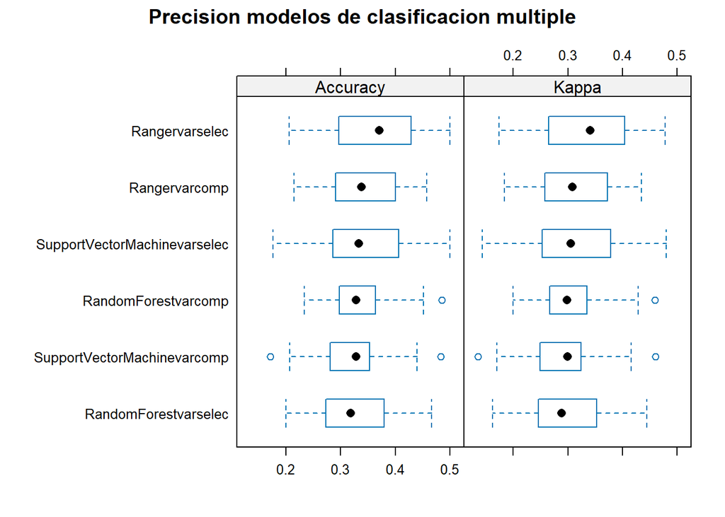

```r
bwplot(modelos.resample, main="Precision modelos de clasificacion multiple")
```

El modelo que obtiene unos mejores resultados en casos de clasificacion multiclase es el algoritmo Ranger, con los datos de la seleccion de variables.

```r
difest <- diff(modelos.resample, adjustment = "none")
summary(difest)
```

```
##
## Call:
## summary.diff.resamples(object = difest)
##
## Upper diagonal: estimates of the difference
## Lower diagonal: p-value for H0: difference = 0
##
## Accuracy
##                              Rangervarselec RandomForestvarselec
## Rangervarselec                               0.029417
## RandomForestvarselec         0.1684
## SupportVectorMachinevarselec 0.3578         0.6006
## Rangervarcomp                0.3604         0.5087
## RandomForestvarcomp          0.2139         0.8355
## SupportVectorMachinevarcomp  0.0789         0.6582
##                              SupportVectorMachinevarselec Rangervarcomp
## Rangervarselec                0.018668                     0.017176
## RandomForestvarselec         -0.010749                    -0.012242
## SupportVectorMachinevarselec                              -0.001493
## Rangervarcomp                0.9400
## RandomForestvarcomp          0.6571                       0.5846
## SupportVectorMachinevarcomp  0.3191                       0.2872
##                              RandomForestvarcomp SupportVectorMachinevarcomp
## Rangervarselec                0.026225            0.037614
## RandomForestvarselec         -0.003193            0.008196
## SupportVectorMachinevarselec  0.007556            0.018945
## Rangervarcomp                 0.009049            0.020438
## RandomForestvarcomp                               0.011389
## SupportVectorMachinevarcomp  0.4774
##
## Kappa
##                              Rangervarselec RandomForestvarselec
## Rangervarselec                               0.0310520
## RandomForestvarselec         0.16043
## SupportVectorMachinevarselec 0.36868        0.57436
## Rangervarcomp                0.34355        0.50643
## RandomForestvarcomp          0.20601        0.82371
## SupportVectorMachinevarcomp  0.08173        0.69276
##                              SupportVectorMachinevarselec Rangervarcomp
## Rangervarselec                0.0190067                    0.0182810
## RandomForestvarselec         -0.0120452                   -0.0127710
## SupportVectorMachinevarselec                              -0.0007257
## Rangervarcomp                0.97198
## RandomForestvarcomp          0.63024                      0.58824
## SupportVectorMachinevarcomp  0.32185                      0.30365
##                              RandomForestvarcomp SupportVectorMachinevarcomp
## Rangervarselec                0.0275248           0.0387060
## RandomForestvarselec         -0.0035271           0.0076541
## SupportVectorMachinevarselec  0.0085181           0.0196993
## Rangervarcomp                 0.0092438           0.0204250
## RandomForestvarcomp                               0.0111812
## SupportVectorMachinevarcomp  0.49994
```

# 6. GENERACION DE MODELOS DE CLASIFICACIÓN BINARIA PARA CRUCE

## 6.1 GENERACION DE MODELOS DE CLASIFICACION BINARIA PARA CLASE POSITIVA S5133 X A2198.

### 6.1.1 MODELOS CON DATOS SELECCION DE VARIABLES.

Primero llevamos a cabo la seleccion de variables

```r
library(forcats)
datos1sv <- datosc
datos1sv$CRUZE <- fct_other(datos1sv$CRUZE, keep = "S5133XA2198", other_level = "OTROS")
table(datos1sv$CRUZE)
```

```
##
## S5133XA2198       OTROS
##          76         717
```

```r
set.seed(12345)
datos1svpart <- createDataPartition(datos1sv$CRUZE,p=0.8,list = FALSE)
datos1sv.train <- datos1sv[datos1svpart,]
datos1sv.test <- datos1sv[-datos1svpart,]
```

Balanceamos los datos

```r
datos1sv.train_x = datos1sv.train

maskneg = which(datos1sv.train_x$CRUZE == "OTROS") #Seleccionamos las clases distintas
maskpos = which(datos1sv.train_x$CRUZE == "S5133XA2198") #Seleccinamos la clase
datos1sv.train_x = datos1sv.train_x[c(maskpos,sample(maskneg,length(maskpos))),]

datos1sv.train_x = datos1sv.train_x[sample(1:nrow(datos1sv.train_x),nrow(datos1sv.train_x)),]

datos1sv.train_y = datos1sv.train_x$CRUZE

table(datos1sv.train_x$CRUZE)
```

```
##
## S5133XA2198       OTROS
##          61          61
```

```r
subsets <- c(3:20) #Indicamos que cree subgrupos de entre 3 y 20 variables.

seeds <- vector(mode = "list", length = 6)

for(i in 1:10) seeds[[i]] <- sample.int(1000, length(subsets) + 1)
seeds[[11]] <- sample.int(1000, 1)

ctrl.treebag.rfe.cv.10bin <- rfeControl(functions=rfFuncs ,
                                     method = "cv",
                                     number = 10,
                                     seeds = seeds,
                                     returnResamp="final",
                                     verbose = TRUE,
                                     allowParallel = TRUE)
```

```r
treebag.rfe.cv.10bin <- rfe(CRUZE~., data=datos1sv.train_x,
                         sizes=subsets,
                         rfeControl=ctrl.treebag.rfe.cv.10bin)
```

```r
treebag.rfe.cv.10bin$fit = NULL
saveRDS(treebag.rfe.cv.10bin, "C:/Users/gonza/Documents/TFM/treebag.fre.cv.10bin.rds")
```

```r
varseleccrucebin <- readRDS("C:/Users/gonza/Documents/TFM/treebag.fre.cv.10bin.rds")
varseleccrucebin$optVariables
```

```
##  [1] "RENDI" "ESPES" "MADUR" "GRANO" "CASCA" "CASC1" "DUREZ" "GRAN1" "RUGOS"
## [10] "FORMA" "PRINT" "COLOR" "FALLP" "FLINT" "FALLO" "FRUTO" "DOBLE" "NOTA"
## [19] "SABOR"
```

Las variables seleccionadas son : “RENDI” “ESPES” “MADUR” “GRANO” “CASCA” “CASC1” “DUREZ” “GRAN1” “RUGOS” “FORMA” “PRINT” “COLOR” “FALLP” “FLINT” “FALLO” “FRUTO” “DOBLE” “NOTA” “SABOR”.

Ahora llevaremos a cabo los modelos con estas variables para comprobar la precision

Primero volveremos a seleccionar de los datos reducidos las variables de interes

```r
datos1 <- datosc[, c("CRUZE", "RENDI" ,"ESPES", "MADUR" ,"GRANO" ,"CASCA" ,"CASC1" ,"DUREZ", "GRAN1" ,"RUGOS" ,"FORMA" ,"PRINT","COLOR" ,"FALLP" ,"FLINT", "FALLO", "FRUTO", "DOBLE" ,"NOTA" , "SABOR")]
datos1$CRUZE <- fct_other(datos1$CRUZE, keep = "S5133XA2198", other_level = "OTROS")
table(datos1$CRUZE)
```

```
##
## S5133XA2198       OTROS
##          76         717
```

Balanceamos los datos.

```r
datos1.id <- createDataPartition(datos1$CRUZE, p=0.7, list = FALSE)
datos1.train <- datos1[datos1.id,]
datos1.test <- datos1[-datos1.id,]
```

Ahora balancearemos los datos del train de cara a entrenar los modelos.

```r
datos1.train_x = datos1.train

maskneg = which(datos1.train_x$CRUZE == "OTROS") #Seleccionamos las clases distintas
maskpos = which(datos1.train_x$CRUZE == "S5133XA2198") #Seleccinamos la clase
datos1.train_x = datos1.train_x[c(maskpos,sample(maskneg,length(maskpos))),]

datos1.train_x = datos1.train_x[sample(1:nrow(datos1.train_x),nrow(datos1.train_x)),]

datos1.train_y = datos1.train_x$CRUZE

table(datos1.train_x$CRUZE)
```

```
##
## S5133XA2198       OTROS
##          54          54
```

```r
datos1.train_x$CRUZE=NULL
```

Caret define por defecto la tecnica de remuestreo en la mitica bootstrap, sin embargo nosotros utilizaremos la crossvalidacion cruzada, en este caso de 10 pliegues con 3 repeticiones cada una (number=numero de pliegues -> 10 , repeats=numero de repeticiones -> 3). Además, añadimos la linea de comando verboseIter=TRUE para poder observar el avance del remuestreo en el entrenamiento del modelo.

```r
TrainCtrlRanger.3cv10 <- trainControl( # Crosvalidación de 10 pliegues con 3 repeticiones
  method = "repeatedcv",
  number = 10,
  repeats = 3,
  verboseIter=TRUE)
```

```r
modeloranger.3cv10.S5133XA2198sv <- train(x = datos1.train_x,
                         y = datos1.train_y,
                         method = "ranger",  #En este caso el metodo ranger
                         trControl = TrainCtrlRanger.3cv10)
```

```r
saveRDS(modeloranger.3cv10.S5133XA2198sv, "modelorangercrucesvbin.rds")
```

```r
modelorangercrucesvbin <- readRDS("C:/Users/gonza/Documents/TFM/modelorangercrucesvbin.rds")
modelorangercrucesvbin
```

```
## Random Forest
##
## 108 samples
##  19 predictor
##   2 classes: 'S5133XA2198', 'OTROS'
##
## No pre-processing
## Resampling: Cross-Validated (10 fold, repeated 3 times)
## Summary of sample sizes: 98, 97, 97, 96, 98, 96, ...
## Resampling results across tuning parameters:
##
##   mtry  splitrule   Accuracy   Kappa
##    2    gini        0.8247475  0.6501480
##    2    extratrees  0.8532828  0.7044443
##   10    gini        0.8222222  0.6446335
##   10    extratrees  0.8318687  0.6624052
##   19    gini        0.8399495  0.6811466
##   19    extratrees  0.8440909  0.6862244
##
## Tuning parameter 'min.node.size' was held constant at a value of 1
## Accuracy was used to select the optimal model using the largest value.
## The final values used for the model were mtry = 2, splitrule = extratrees
##  and min.node.size = 1.
```

```
## Confusion Matrix and Statistics
##
##              Reference
## Prediction    S5133XA2198 OTROS
##   S5133XA2198          22    39
##   OTROS                 0   176
##
##                Accuracy : 0.8354
##                  95% CI : (0.782, 0.8803)
##     No Information Rate : 0.9072
##     P-Value [Acc > NIR] : 0.9998
##
##                   Kappa : 0.4559
##
##  Mcnemar's Test P-Value : 1.166e-09
##
##             Sensitivity : 1.00000
##             Specificity : 0.81860
##          Pos Pred Value : 0.36066
##          Neg Pred Value : 1.00000
##              Prevalence : 0.09283
##          Detection Rate : 0.09283
##    Detection Prevalence : 0.25738
##       Balanced Accuracy : 0.90930
##
##        'Positive' Class : S5133XA2198
##
```

Ahora el modelo rf

```r
TrainCtrlRf.3cv10 <- trainControl( # Crosvalidación de 10 pliegues con 3 repeticiones
  method = "repeatedcv",
  number = 10,
  repeats = 3,
  verboseIter=TRUE)
```

```r
modelorf.3cv10.S5133XA2198sv <- train(x = datos1.train_x,
                         y = datos1.train_y,
                         method = "rf",  #En este caso el metodo rf
                         trControl = TrainCtrlRf.3cv10)
```

```r
saveRDS(modelorf.3cv10.S5133XA2198sv, "modelorfcrucesvbin.rds")
```

```r
modelorfcrucesvbin <- readRDS("C:/Users/gonza/Documents/TFM/modelorfcrucesvbin.rds")
modelorfcrucesvbin
```

```
## Random Forest
##
## 108 samples
##  19 predictor
##   2 classes: 'S5133XA2198', 'OTROS'
##
## No pre-processing
## Resampling: Cross-Validated (10 fold, repeated 3 times)
## Summary of sample sizes: 97, 96, 98, 98, 98, 97, ...
## Resampling results across tuning parameters:
##
##   mtry  Accuracy   Kappa
##    2    0.8392929  0.6772971
##   10    0.8073737  0.6140932
##   19    0.8315152  0.6629832
##
## Accuracy was used to select the optimal model using the largest value.
## The final value used for the model was mtry = 2.
```

```
## Confusion Matrix and Statistics
##
##              Reference
## Prediction    S5133XA2198 OTROS
##   S5133XA2198          22    43
##   OTROS                 0   172
##
##                Accuracy : 0.8186
##                  95% CI : (0.7635, 0.8655)
##     No Information Rate : 0.9072
##     P-Value [Acc > NIR] : 1
##
##                   Kappa : 0.4262
##
##  Mcnemar's Test P-Value : 1.504e-10
##
##             Sensitivity : 1.00000
##             Specificity : 0.80000
##          Pos Pred Value : 0.33846
##          Neg Pred Value : 1.00000
##              Prevalence : 0.09283
##          Detection Rate : 0.09283
##    Detection Prevalence : 0.27426
##       Balanced Accuracy : 0.90000
##
##        'Positive' Class : S5133XA2198
##
```

Ahora el algoritmo SVM

```r
TrainCtrlsvm.3cv10 <- trainControl( # Crosvalidación de 10 pliegues con 3 repeticiones
  method = "repeatedcv",
  number = 10,
  repeats = 3,
  verboseIter=TRUE)
```

```r
modelosvm.3cv10.S5133XA2198sv <- train(x = datos1.train_x,
                         y = datos1.train_y,
                         method = "svmRadial",  #En este caso el metodo svm
                         trControl = TrainCtrlsvm.3cv10)
```

```r
saveRDS(modelosvm.3cv10.S5133XA2198sv, "modelosvmcrucesvbin.rds")
```

```r
modelosvmcrucesvbin <- readRDS("C:/Users/gonza/Documents/TFM/modelosvmcrucesvbin.rds")
modelosvmcrucesvbin
```

```
## Support Vector Machines with Radial Basis Function Kernel
##
## 108 samples
##  19 predictor
##   2 classes: 'S5133XA2198', 'OTROS'
##
## No pre-processing
## Resampling: Cross-Validated (10 fold, repeated 3 times)
## Summary of sample sizes: 97, 96, 96, 98, 97, 97, ...
## Resampling results across tuning parameters:
##
##   C     Accuracy   Kappa
##   0.25  0.8203030  0.6393495
##   0.50  0.8448990  0.6885217
##   1.00  0.8418182  0.6827112
##
## Tuning parameter 'sigma' was held constant at a value of 0.04758903
## Accuracy was used to select the optimal model using the largest value.
## The final values used for the model were sigma = 0.04758903 and C = 0.5.
```

```
## Confusion Matrix and Statistics
##
##              Reference
## Prediction    S5133XA2198 OTROS
##   S5133XA2198           0     0
##   OTROS                 0     0
##
##                Accuracy : NaN
##                  95% CI : (NA, NA)
##     No Information Rate : NA
##     P-Value [Acc > NIR] : NA
##
##                   Kappa : NaN
##
##  Mcnemar's Test P-Value : NA
##
##             Sensitivity :  NA
##             Specificity :  NA
##          Pos Pred Value :  NA
##          Neg Pred Value :  NA
##              Prevalence : NaN
##          Detection Rate : NaN
##    Detection Prevalence : NaN
##       Balanced Accuracy :  NA
##
##        'Positive' Class : S5133XA2198
##
```

### 6.1.2 MODELOS CON DATOS COMPLETOS

```r
datos2 <- datosc
datos2$CRUZE <- fct_other(datos2$CRUZE, keep = "S5133XA2198", other_level = "OTROS")
table(datos2$CRUZE)
```

```
##
## S5133XA2198       OTROS
##          76         717
```

Balanceamos los datos.

```r
datos2.id <- createDataPartition(datos2$CRUZE, p=0.7, list = FALSE)
datos2.train <- datos2[datos2.id,]
datos2.test <- datos2[-datos2.id,]
```

Ahora balancearemos los datos del train de cara a entrenar los modelos.

```r
datos2.train_x = datos2.train

maskneg = which(datos2.train_x$CRUZE == "OTROS") #Seleccionamos las clases distintas
maskpos = which(datos2.train_x$CRUZE == "S5133XA2198") #Seleccinamos la clase
datos2.train_x = datos2.train_x[c(maskpos,sample(maskneg,length(maskpos))),]

datos2.train_x = datos2.train_x[sample(1:nrow(datos2.train_x),nrow(datos2.train_x)),]

datos2.train_y = datos2.train_x$CRUZE

table(datos2.train_x$CRUZE)
```

```
##
## S5133XA2198       OTROS
##          54          54
```

```r
datos2.train_x$CRUZE=NULL
```

Caret define por defecto la tecnica de remuestreo en la mitica bootstrap, sin embargo nosotros utilizaremos la crossvalidacion cruzada, en este caso de 10 pliegues con 3 repeticiones cada una (number=numero de pliegues -> 10 , repeats=numero de repeticiones -> 3). Además, añadimos la linea de comando verboseIter=TRUE para poder observar el avance del remuestreo en el entrenamiento del modelo.

```r
modeloranger.3cv10.S5133XA2198C <- train(x = datos2.train_x,
                         y = datos2.train_y,
                         method = "ranger",  #En este caso el metodo ranger
                         trControl = TrainCtrlRanger.3cv10)
```

```r
saveRDS(modeloranger.3cv10.S5133XA2198C, "modelorangercruceCbin.rds")
```

```r
modelorangercruceCbin <- readRDS("C:/Users/gonza/Documents/TFM/modelorangercruceCbin.rds")
modelorangercruceCbin
```

```
## Random Forest
##
## 108 samples
##  20 predictor
##   2 classes: 'S5133XA2198', 'OTROS'
##
## No pre-processing
## Resampling: Cross-Validated (10 fold, repeated 3 times)
## Summary of sample sizes: 97, 98, 96, 97, 98, 98, ...
## Resampling results across tuning parameters:
##
##   mtry  splitrule   Accuracy   Kappa
##    2    gini        0.8296465  0.6594187
##    2    extratrees  0.7851010  0.5704483
##   11    gini        0.8001010  0.5998336
##   11    extratrees  0.8007576  0.6010463
##   20    gini        0.8117172  0.6233846
##   20    extratrees  0.8235354  0.6461943
##
## Tuning parameter 'min.node.size' was held constant at a value of 1
## Accuracy was used to select the optimal model using the largest value.
## The final values used for the model were mtry = 2, splitrule = gini
##  and min.node.size = 1.
```

```
## Confusion Matrix and Statistics
##
##              Reference
## Prediction    S5133XA2198 OTROS
##   S5133XA2198          21    35
##   OTROS                 1   180
##
##                Accuracy : 0.8481
##                  95% CI : (0.796, 0.8913)
##     No Information Rate : 0.9072
##     P-Value [Acc > NIR] : 0.9987
##
##                   Kappa : 0.4675
##
##  Mcnemar's Test P-Value : 3.798e-08
##
##             Sensitivity : 0.95455
##             Specificity : 0.83721
##          Pos Pred Value : 0.37500
##          Neg Pred Value : 0.99448
##              Prevalence : 0.09283
##          Detection Rate : 0.08861
##    Detection Prevalence : 0.23629
##       Balanced Accuracy : 0.89588
##
##        'Positive' Class : S5133XA2198
##
```

Ahora el modelo rf

```r
modelorf.3cv10.S5133XA2198C <- train(x = datos2.train_x,
                         y = datos2.train_y,
                         method = "rf",  #En este caso el metodo rf
                         trControl = TrainCtrlRf.3cv10)
```

```r
saveRDS(modelorf.3cv10.S5133XA2198C, "modelorfcruceCbin.rds")
```

```r
modelorfcruceCbin <- readRDS("C:/Users/gonza/Documents/TFM/modelorfcruceCbin.rds")
modelorfcruceCbin
```

```
## Random Forest
##
## 108 samples
##  20 predictor
##   2 classes: 'S5133XA2198', 'OTROS'
##
## No pre-processing
## Resampling: Cross-Validated (10 fold, repeated 3 times)
## Summary of sample sizes: 98, 98, 97, 98, 96, 97, ...
## Resampling results across tuning parameters:
##
##   mtry  Accuracy   Kappa
##    2    0.8139394  0.6263946
##   11    0.8114646  0.6214843
##   20    0.8165152  0.6321061
##
## Accuracy was used to select the optimal model using the largest value.
## The final value used for the model was mtry = 20.
```

```r
caret::varImp(modelorfcruceCbin)
```

```
## rf variable importance
##
##       Overall
## RENDI 100.000
## MADUR  70.459
## FORMA  33.614
## GRAN1  32.517
## COLOR  31.103
## GRANO  16.791
## CASC1  12.352
## CASCA  10.501
## DUREZ   8.218
## PRINT   7.216
## FALLP   6.019
## ESPES   4.930
## RUGOS   4.488
## FALLO   4.446
## FLINT   3.258
## NOTA    2.954
## DOBLE   2.218
## DOBLP   2.020
## FRUTO   0.433
## SABOR   0.000
```

```
## Confusion Matrix and Statistics
##
##              Reference
## Prediction    S5133XA2198 OTROS
##   S5133XA2198          21    40
##   OTROS                 1   175
##
##                Accuracy : 0.827
##                  95% CI : (0.7727, 0.8729)
##     No Information Rate : 0.9072
##     P-Value [Acc > NIR] : 1
##
##                   Kappa : 0.428
##
##  Mcnemar's Test P-Value : 2.946e-09
##
##             Sensitivity : 0.95455
##             Specificity : 0.81395
##          Pos Pred Value : 0.34426
##          Neg Pred Value : 0.99432
##              Prevalence : 0.09283
##          Detection Rate : 0.08861
##    Detection Prevalence : 0.25738
##       Balanced Accuracy : 0.88425
##
##        'Positive' Class : S5133XA2198
##
```

Ahora el algoritmo SVM

```r
modelosvm.3cv10.S5133XA2198C <- train(x = datos2.train_x,
                         y = datos2.train_y,
                         method = "svmRadial",  #En este caso el metodo svm
                         trControl = TrainCtrlsvm.3cv10)
```

```r
saveRDS(modelosvm.3cv10.S5133XA2198C, "modelosvmcruceCbin.rds")
```

```r
modelosvmcruceCbin <- readRDS("C:/Users/gonza/Documents/TFM/modelosvmcruceCbin.rds")
modelosvmcruceCbin
```

```
## Support Vector Machines with Radial Basis Function Kernel
##
## 108 samples
##  20 predictor
##   2 classes: 'S5133XA2198', 'OTROS'
##
## No pre-processing
## Resampling: Cross-Validated (10 fold, repeated 3 times)
## Summary of sample sizes: 97, 98, 97, 98, 98, 97, ...
## Resampling results across tuning parameters:
##
##   C     Accuracy   Kappa
##   0.25  0.7812626  0.5626977
##   0.50  0.7663131  0.5318653
##   1.00  0.7900505  0.5790549
##
## Tuning parameter 'sigma' was held constant at a value of 0.04081267
## Accuracy was used to select the optimal model using the largest value.
## The final values used for the model were sigma = 0.04081267 and C = 1.
```

```
## Confusion Matrix and Statistics
##
##              Reference
## Prediction    S5133XA2198 OTROS
##   S5133XA2198           0     0
##   OTROS                 0     0
##
##                Accuracy : NaN
##                  95% CI : (NA, NA)
##     No Information Rate : NA
##     P-Value [Acc > NIR] : NA
##
##                   Kappa : NaN
##
##  Mcnemar's Test P-Value : NA
##
##             Sensitivity :  NA
##             Specificity :  NA
##          Pos Pred Value :  NA
##          Neg Pred Value :  NA
##              Prevalence : NaN
##          Detection Rate : NaN
##    Detection Prevalence : NaN
##       Balanced Accuracy :  NA
##
##        'Positive' Class : S5133XA2198
##
```

# 6.1.3 COMPARACION DE MODELOS DE CLASIFICACION BINARIA

```r
listamodeloscrucesS5133XA2198 <- list(Rangervarselec=modelorangercrucesvbin,RandomForestvarselec=modelorfcrucesvbin,SupportVectorMachinevarselec=modelosvmcrucesvbin,Rangervarcomp=modelorangercruceCbin, RandomForestvarcomp=modelorfcruceCbin, SupportVectorMachinevarcomp=modelosvmcruceCbin)
modelos.resampleS5133XA2198 <- resamples(listamodeloscrucesS5133XA2198)
summary(modelos.resampleS5133XA2198)
```

```
##
## Call:
## summary.resamples(object = modelos.resampleS5133XA2198)
##
## Models: Rangervarselec, RandomForestvarselec, SupportVectorMachinevarselec, Rangervarcomp, RandomForestvarcomp, SupportVectorMachinevarcomp
## Number of resamples: 30
##
## Accuracy
##                                   Min.   1st Qu.    Median      Mean   3rd Qu.
## Rangervarselec               0.6000000 0.7670455 0.9000000 0.8532828 0.9147727
## RandomForestvarselec         0.5000000 0.8000000 0.8257576 0.8392929 0.9147727
## SupportVectorMachinevarselec 0.6363636 0.8000000 0.8181818 0.8448990 0.9090909
## Rangervarcomp                0.4000000 0.7500000 0.8666667 0.8296465 0.9090909
## RandomForestvarcomp          0.5454545 0.7329545 0.8181818 0.8165152 0.9068182
## SupportVectorMachinevarcomp  0.5000000 0.7068182 0.8090909 0.7900505 0.9090909
##                              Max. NA's
## Rangervarselec                  1    0
## RandomForestvarselec            1    0
## SupportVectorMachinevarselec    1    0
## Rangervarcomp                   1    0
## RandomForestvarcomp             1    0
## SupportVectorMachinevarcomp     1    0
##
## Kappa
##                                     Min.   1st Qu.    Median      Mean
## Rangervarselec                0.20000000 0.5301724 0.8000000 0.7044443
## RandomForestvarselec          0.00000000 0.6000000 0.6559140 0.6772971
## SupportVectorMachinevarselec  0.26666667 0.6000000 0.6392473 0.6885217
## Rangervarcomp                -0.20000000 0.5000000 0.7333333 0.6594187
## RandomForestvarcomp           0.09836066 0.4692623 0.6333333 0.6321061
## SupportVectorMachinevarcomp   0.00000000 0.4101695 0.6103448 0.5790549
##                                3rd Qu. Max. NA's
## Rangervarselec               0.8299180    1    0
## RandomForestvarselec         0.8299180    1    0
## SupportVectorMachinevarselec 0.8181439    1    0
## Rangervarcomp                0.8196721    1    0
## RandomForestvarcomp          0.8101695    1    0
## SupportVectorMachinevarcomp  0.8181439    1    0
```

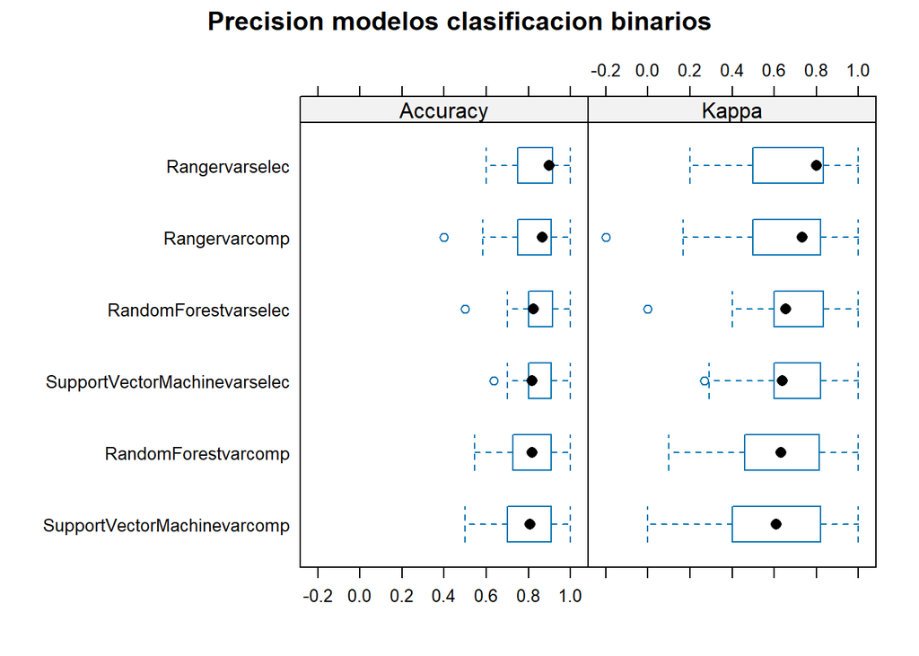

```r
bwplot(modelos.resampleS5133XA2198, main="Precision modelos clasificacion binarios")
```

Se observa que para problemas de clasificacion binaria, los algoritmos randomforest obtienen mejores resultados que los SVM. Además, observamos que cuando realizamos la seleccion de variables, se obtienen mejores resultados, sim embargo no hay mucha diferencia. Dado que nos interesa indicar todas las caracteristicas a nuestro almendro, utilizaremos todas las variables ya que no hay tanta diferencia en los resultados.

```r
difestS5133XA2198 <- diff(modelos.resampleS5133XA2198, adjustment = "none")
summary(difestS5133XA2198)
```

```
##
## Call:
## summary.diff.resamples(object = difestS5133XA2198)
##
## Upper diagonal: estimates of the difference
## Lower diagonal: p-value for H0: difference = 0
##
## Accuracy
##                              Rangervarselec RandomForestvarselec
## Rangervarselec                               0.013990
## RandomForestvarselec         0.65626
## SupportVectorMachinevarselec 0.76161        0.85101
## Rangervarcomp                0.49598        0.79156
## RandomForestvarcomp          0.18337        0.46175
## SupportVectorMachinevarcomp  0.09441        0.12383
##                              SupportVectorMachinevarselec Rangervarcomp
## Rangervarselec                0.008384                     0.023636
## RandomForestvarselec         -0.005606                     0.009646
## SupportVectorMachinevarselec                               0.015253
## Rangervarcomp                0.63337
## RandomForestvarcomp          0.28585                      0.66042
## SupportVectorMachinevarcomp  0.11557                      0.26915
##                              RandomForestvarcomp SupportVectorMachinevarcomp
## Rangervarselec                0.036768            0.063232
## RandomForestvarselec          0.022778            0.049242
## SupportVectorMachinevarselec  0.028384            0.054848
## Rangervarcomp                 0.013131            0.039596
## RandomForestvarcomp                               0.026465
## SupportVectorMachinevarcomp  0.31705
##
## Kappa
##                              Rangervarselec RandomForestvarselec
## Rangervarselec                               0.02715
## RandomForestvarselec         0.66773
## SupportVectorMachinevarselec 0.77507        0.85138
## Rangervarcomp                0.51808        0.80654
## RandomForestvarcomp          0.19359        0.46669
## SupportVectorMachinevarcomp  0.09945        0.12733
##                              SupportVectorMachinevarselec Rangervarcomp
## Rangervarselec                0.01592                      0.04503
## RandomForestvarselec         -0.01122                      0.01788
## SupportVectorMachinevarselec                               0.02910
## Rangervarcomp                0.64719
## RandomForestvarcomp          0.28478                      0.64837
## SupportVectorMachinevarcomp  0.11453                      0.26262
##                              RandomForestvarcomp SupportVectorMachinevarcomp
## Rangervarselec                0.07234             0.12539
## RandomForestvarselec          0.04519             0.09824
## SupportVectorMachinevarselec  0.05642             0.10947
## Rangervarcomp                 0.02731             0.08036
## RandomForestvarcomp                               0.05305
## SupportVectorMachinevarcomp  0.31626
```

Sabiendo que el mejor enfoque consiste en utilizar todos las variables y generar los modelos con el algoritmo ranger, vamos a llevar a cabo la prediccion

### 6.1.4 SELECCIÓN DEL MEJOR CRUZAMIENTO

```r
# Muestra optima de almendra
muestra <- data.frame(FLINT = 5, PRINT = 5, MADUR = 200, FRUTO = 25, CASCA = 80, CASC1 = 2, DUREZ = 3, GRANO = 30, GRAN1 = 1,2 , RENDI = 100, FALLO = 0, FALLP = 0, DOBLE = 0, DOBLP = 0, FORMA = 4, ESPES = 3, RUGOS = 2, COLOR = 3, SABOR = 3, NOTA = 5)

# Predicción del grupo de la muestra optima
prediccionoptima <- predict(modelorangercruceCbin, newdata = muestra)

# Resultado de la predicción
print(prediccionoptima)
```

```
## [1] OTROS
## Levels: S5133XA2198 OTROS
```

```r
# Muestra distinta
muestrados <- data.frame(FLINT = 3, PRINT = 3, MADUR = 220, FRUTO = 25, CASCA = 80, CASC1 = 2, DUREZ = 3, GRANO = 30, GRAN1 = 1,2 , RENDI = 80, FALLO = 0, FALLP = 0, DOBLE = 0, DOBLP = 0, FORMA = 4, ESPES = 3, RUGOS = 2, COLOR = 4, SABOR = 3, NOTA = 4)

# Predicción del grupo de la muestra optima
prediccionoptimados <- predict(modelorangercruceCbin, newdata = muestrados)

# Resultado de la predicción
print(prediccionoptimados)
```

```
## [1] OTROS
## Levels: S5133XA2198 OTROS
```

A partir de ahora se llevara a cabo un enfoque de clasificacion binario sin seleccion de variables, utilizando el algoritmo ranger y se usara rf para ver la importancia de las variables.

## 6.2 GENERACION DE MODELOS DE CLASIFICACION BINARIA PARA CLASE POSITIVA S5133XR1000.

```r
datos2 <- datosc
datos2$CRUZE <- fct_other(datos2$CRUZE, keep = "S5133XR1000", other_level = "OTROS")
table(datos2$CRUZE)
```

```
##
## S5133XR1000       OTROS
##          92         701
```

Balanceamos los datos.

```r
datos2.id <- createDataPartition(datos2$CRUZE, p=0.7, list = FALSE)
datos2.train <- datos2[datos2.id,]
datos2.test <- datos2[-datos2.id,]
```

Ahora balancearemos los datos del train de cara a entrenar los modelos.

```r
datos2.train_x = datos2.train

maskneg = which(datos2.train_x$CRUZE == "OTROS") #Seleccionamos las clases distintas de UTR
maskpos = which(datos2.train_x$CRUZE == "S5133XR1000") #Seleccinamos la clase UTR
datos2.train_x = datos2.train_x[c(maskpos,sample(maskneg,length(maskpos))),]

datos2.train_x = datos2.train_x[sample(1:nrow(datos2.train_x),nrow(datos2.train_x)),]

datos2.train_y = datos2.train_x$CRUZE

table(datos2.train_x$CRUZE)
```

```
##
## S5133XR1000       OTROS
##          65          65
```

```r
datos2.train_x$CRUZE=NULL
```

Caret define por defecto la tecnica de remuestreo en la mitica bootstrap, sin embargo nosotros utilizaremos la crossvalidacion cruzada, en este caso de 10 pliegues con 3 repeticiones cada una (number=numero de pliegues -> 10 , repeats=numero de repeticiones -> 3). Además, añadimos la linea de comando verboseIter=TRUE para poder observar el avance del remuestreo en el entrenamiento del modelo.

```r
modeloranger.3cv10.S5133XR1000 <- train(x = datos2.train_x,
                         y = datos2.train_y,
                         method = "ranger",  #En este caso el metodo ranger
                         trControl = TrainCtrlRanger.3cv10)
```

```r
saveRDS(modeloranger.3cv10.S5133XR1000, "modelorangercrucesS5133XR1000.rds")
```

```r
modelorangercrucesS5133XR1000 <- readRDS("C:/Users/gonza/Documents/TFM/modelorangercrucesS5133XR1000.rds")
modelorangercrucesS5133XR1000
```

```
## Random Forest
##
## 130 samples
##  20 predictor
##   2 classes: 'S5133XR1000', 'OTROS'
##
## No pre-processing
## Resampling: Cross-Validated (10 fold, repeated 3 times)
## Summary of sample sizes: 117, 116, 117, 117, 117, 118, ...
## Resampling results across tuning parameters:
##
##   mtry  splitrule   Accuracy   Kappa
##    2    gini        0.7028083  0.4095276
##    2    extratrees  0.7146215  0.4313308
##   11    gini        0.7059219  0.4151821
##   11    extratrees  0.7017705  0.4053155
##   20    gini        0.7118742  0.4267107
##   20    extratrees  0.6989927  0.4002358
##
## Tuning parameter 'min.node.size' was held constant at a value of 1
## Accuracy was used to select the optimal model using the largest value.
## The final values used for the model were mtry = 2, splitrule = extratrees
##  and min.node.size = 1.
```

```
## Confusion Matrix and Statistics
##
##              Reference
## Prediction    S5133XR1000 OTROS
##   S5133XR1000          25    66
##   OTROS                 2   144
##
##                Accuracy : 0.7131
##                  95% CI : (0.651, 0.7698)
##     No Information Rate : 0.8861
##     P-Value [Acc > NIR] : 1
##
##                   Kappa : 0.3009
##
##  Mcnemar's Test P-Value : 2.174e-14
##
##             Sensitivity : 0.9259
##             Specificity : 0.6857
##          Pos Pred Value : 0.2747
##          Neg Pred Value : 0.9863
##              Prevalence : 0.1139
##          Detection Rate : 0.1055
##    Detection Prevalence : 0.3840
##       Balanced Accuracy : 0.8058
##
##        'Positive' Class : S5133XR1000
##
```

Ahora algorimto rf para la importancia

```r
modelorf.3cv10.S5133XR1000 <- train(x = datos2.train_x,
                         y = datos2.train_y,
                         method = "rf",  #En este caso el metodo ranger
                         trControl = TrainCtrlRf.3cv10)
```

```r
saveRDS(modelorf.3cv10.S5133XR1000, "modelorfcrucesS5133XR1000.rds")
```

```r
modelorfcrucesS5133XR1000 <- readRDS("C:/Users/gonza/Documents/TFM/modelorfcrucesS5133XR1000.rds")
modelorfcrucesS5133XR1000
```

```
## Random Forest
##
## 130 samples
##  20 predictor
##   2 classes: 'S5133XR1000', 'OTROS'
##
## No pre-processing
## Resampling: Cross-Validated (10 fold, repeated 3 times)
## Summary of sample sizes: 116, 118, 116, 117, 116, 117, ...
## Resampling results across tuning parameters:
##
##   mtry  Accuracy   Kappa
##    2    0.7123321  0.4217783
##   11    0.7066239  0.4104993
##   20    0.7250611  0.4478741
##
## Accuracy was used to select the optimal model using the largest value.
## The final value used for the model was mtry = 20.
```

```r
caret::varImp(modelorfcrucesS5133XR1000)
```

```
## rf variable importance
##
##       Overall
## GRANO 100.000
## RENDI  43.896
## MADUR  31.860
## GRAN1  30.382
## CASC1  22.949
## CASCA  15.802
## ESPES  12.061
## FORMA  10.845
## COLOR  10.391
## PRINT   9.940
## DUREZ   9.682
## FALLP   6.629
## FLINT   5.591
## RUGOS   5.200
## NOTA    5.113
## DOBLE   3.789
## DOBLP   3.658
## FALLO   3.525
## SABOR   3.001
## FRUTO   0.000
```

```
## Confusion Matrix and Statistics
##
##              Reference
## Prediction    S5133XR1000 OTROS
##   S5133XR1000          25    81
##   OTROS                 2   129
##
##                Accuracy : 0.6498
##                  95% CI : (0.5854, 0.7104)
##     No Information Rate : 0.8861
##     P-Value [Acc > NIR] : 1
##
##                   Kappa : 0.2375
##
##  Mcnemar's Test P-Value : <2e-16
##
##             Sensitivity : 0.9259
##             Specificity : 0.6143
##          Pos Pred Value : 0.2358
##          Neg Pred Value : 0.9847
##              Prevalence : 0.1139
##          Detection Rate : 0.1055
##    Detection Prevalence : 0.4473
##       Balanced Accuracy : 0.7701
##
##        'Positive' Class : S5133XR1000
##
```

### 6.2.1 SELECCIÓN DEL MEJOR CRUZAMIENTO

```r
# Predicción del grupo de la muestra optima
prediccionoptima2 <- predict(modelorangercrucesS5133XR1000, newdata = muestra)

# Resultado de la predicción
print(prediccionoptima2)
```

```
## [1] OTROS
## Levels: S5133XR1000 OTROS
```

Perteneceria a otro cruzamiento nuestro almendro optimo.

```r
# Predicción del grupo de la muestra distinta
prediccionoptimados2 <- predict(modelorangercrucesS5133XR1000, newdata = muestrados)

# Resultado de la predicción
print(prediccionoptimados2)
```

```
## [1] OTROS
## Levels: S5133XR1000 OTROS
```

Pertenceria a otro cruzamiento

## 6.3 GENERACION DE MODELOS DE CLASIFICACION BINARIA PARA CLASE POSITIVA AntonetaXMarcona

```r
datos3 <- datosc
datos3$CRUZE <- fct_other(datos3$CRUZE, keep = "AntonetaXMarcona", other_level = "OTROS")
table(datos3$CRUZE)
```

```
##
## AntonetaXMarcona            OTROS
##               58              735
```

Balanceamos los datos.

```r
datos3.id <- createDataPartition(datos3$CRUZE, p=0.7, list = FALSE)
datos3.train <- datos3[datos3.id,]
datos3.test <- datos3[-datos3.id,]
```

Ahora balancearemos los datos del train de cara a entrenar los modelos.

```r
datos3.train_x = datos3.train

maskneg = which(datos3.train_x$CRUZE == "OTROS") #Seleccionamos las clases distintas de UTR
maskpos = which(datos3.train_x$CRUZE == "AntonetaXMarcona") #Seleccinamos la clase UTR
datos3.train_x = datos3.train_x[c(maskpos,sample(maskneg,length(maskpos))),]

datos3.train_x = datos3.train_x[sample(1:nrow(datos3.train_x),nrow(datos3.train_x)),]

datos3.train_y = datos3.train_x$CRUZE

table(datos3.train_x$CRUZE)
```

```
##
## AntonetaXMarcona            OTROS
##               41               41
```

```r
datos3.train_x$CRUZE=NULL
```

Caret define por defecto la tecnica de remuestreo en la mitica bootstrap, sin embargo nosotros utilizaremos la crossvalidacion cruzada, en este caso de 10 pliegues con 3 repeticiones cada una (number=numero de pliegues -> 10 , repeats=numero de repeticiones -> 3). Además, añadimos la linea de comando verboseIter=TRUE para poder observar el avance del remuestreo en el entrenamiento del modelo.

```r
modeloranger.3cv10.AntonetaXMarcona <- train(x = datos3.train_x,
                         y = datos3.train_y,
                         method = "ranger",  #En este caso el metodo ranger
                         trControl = TrainCtrlRanger.3cv10)
```

```r
saveRDS(modeloranger.3cv10.AntonetaXMarcona, "modelorangercrucesAntonetaXMarcona.rds")
```

```r
modelorangercrucesAntonetaXMarcona <- readRDS("C:/Users/gonza/Documents/TFM/modelorangercrucesAntonetaXMarcona.rds")
modelorangercrucesAntonetaXMarcona
```

```
## Random Forest
##
## 82 samples
## 20 predictors
##  2 classes: 'AntonetaXMarcona', 'OTROS'
##
## No pre-processing
## Resampling: Cross-Validated (10 fold, repeated 3 times)
## Summary of sample sizes: 74, 73, 74, 74, 74, 74, ...
## Resampling results across tuning parameters:
##
##   mtry  splitrule   Accuracy   Kappa
##    2    gini        0.8444444  0.6883052
##    2    extratrees  0.8652778  0.7299812
##   11    gini        0.8736111  0.7462727
##   11    extratrees  0.8689815  0.7372889
##   20    gini        0.8495370  0.6971592
##   20    extratrees  0.8657407  0.7306223
##
## Tuning parameter 'min.node.size' was held constant at a value of 1
## Accuracy was used to select the optimal model using the largest value.
## The final values used for the model were mtry = 11, splitrule = gini
##  and min.node.size = 1.
```

```
## Confusion Matrix and Statistics
##
##                   Reference
## Prediction         AntonetaXMarcona OTROS
##   AntonetaXMarcona               15    44
##   OTROS                           2   176
##
##                Accuracy : 0.8059
##                  95% CI : (0.7497, 0.8543)
##     No Information Rate : 0.9283
##     P-Value [Acc > NIR] : 1
##
##                   Kappa : 0.3189
##
##  Mcnemar's Test P-Value : 1.493e-09
##
##             Sensitivity : 0.88235
##             Specificity : 0.80000
##          Pos Pred Value : 0.25424
##          Neg Pred Value : 0.98876
##              Prevalence : 0.07173
##          Detection Rate : 0.06329
##    Detection Prevalence : 0.24895
##       Balanced Accuracy : 0.84118
##
##        'Positive' Class : AntonetaXMarcona
##
```

Ahora algorimto rf para la importancia

```r
modelorf.3cv10.AntonetaXMarcona <- train(x = datos3.train_x,
                         y = datos3.train_y,
                         method = "rf",  #En este caso el metodo rf
                         trControl = TrainCtrlRf.3cv10)
```

```r
saveRDS(modelorf.3cv10.AntonetaXMarcona, "modelorfcrucesAntonetaXMarcona.rds")
```

```r
modelorfcrucesAntonetaXMarcona <- readRDS("C:/Users/gonza/Documents/TFM/modelorfcrucesAntonetaXMarcona.rds")
modelorfcrucesAntonetaXMarcona
```

```
## Random Forest
##
## 82 samples
## 20 predictors
##  2 classes: 'AntonetaXMarcona', 'OTROS'
##
## No pre-processing
## Resampling: Cross-Validated (10 fold, repeated 3 times)
## Summary of sample sizes: 74, 74, 74, 73, 74, 74, ...
## Resampling results across tuning parameters:
##
##   mtry  Accuracy   Kappa
##    2    0.8611111  0.7230859
##   11    0.8606481  0.7213459
##   20    0.8569444  0.7150766
##
## Accuracy was used to select the optimal model using the largest value.
## The final value used for the model was mtry = 2.
```

```r
caret::varImp(modelorfcrucesAntonetaXMarcona)
```

```
## rf variable importance
##
##       Overall
## GRAN1 100.000
## GRANO  95.233
## CASC1  46.205
## MADUR  45.925
## CASCA  43.418
## RENDI  27.219
## NOTA   24.765
## FORMA  24.609
## RUGOS  18.639
## PRINT  16.672
## FLINT  16.422
## COLOR  16.108
## FALLO  15.603
## FALLP  13.213
## ESPES  12.759
## DOBLP  11.511
## DOBLE   9.713
## DUREZ   7.226
## SABOR   3.449
## FRUTO   0.000
```

```
## Confusion Matrix and Statistics
##
##                   Reference
## Prediction         AntonetaXMarcona OTROS
##   AntonetaXMarcona               16    43
##   OTROS                           1   177
##
##                Accuracy : 0.8143
##                  95% CI : (0.7589, 0.8617)
##     No Information Rate : 0.9283
##     P-Value [Acc > NIR] : 1
##
##                   Kappa : 0.3485
##
##  Mcnemar's Test P-Value : 6.37e-10
##
##             Sensitivity : 0.94118
##             Specificity : 0.80455
##          Pos Pred Value : 0.27119
##          Neg Pred Value : 0.99438
##              Prevalence : 0.07173
##          Detection Rate : 0.06751
##    Detection Prevalence : 0.24895
##       Balanced Accuracy : 0.87286
##
##        'Positive' Class : AntonetaXMarcona
##
```

### 6.3.1 SELECCIÓN DEL MEJOR CRUZAMIENTO

```r
# Predicción del grupo de la muestra inventada
prediccionoptima3 <- predict(modelorangercrucesAntonetaXMarcona, newdata = muestra)

# Resultado de la predicción
print(prediccionoptima3)
```

```
## [1] AntonetaXMarcona
## Levels: AntonetaXMarcona OTROS
```

Perteneceria a esta familia nuestro cruzamiento optimo.

```r
# Predicción del grupo de la muestra optima
prediccionoptimados3 <- predict(modelorangercrucesAntonetaXMarcona, newdata = muestrados)

# Resultado de la predicción
print(prediccionoptimados3)
```

```
## [1] OTROS
## Levels: AntonetaXMarcona OTROS
```

## 6.4 GENERACION DE MODELOS DE CLASIFICACION BINARIA PARA CLASE POSITIVA S4017XMarcona

Convertimos las clases

```r
datos4 <- datosc
datos4$CRUZE <- fct_other(datos4$CRUZE, keep = "S4017XMarcona", other_level = "OTROS")
table(datos4$CRUZE)
```

```
##
## S4017XMarcona         OTROS
##            50           743
```

Balanceamos los datos.

```r
datos4.id <- createDataPartition(datos4$CRUZE, p=0.7, list = FALSE)
datos4.train <- datos4[datos4.id,]
datos4.test <- datos4[-datos4.id,]
```

Ahora balancearemos los datos del train de cara a entrenar los modelos.

```r
datos4.train_x = datos4.train

maskneg = which(datos4.train_x$CRUZE == "OTROS") #Seleccionamos las clases distintas
maskpos = which(datos4.train_x$CRUZE == "S4017XMarcona") #Seleccinamos la clase
datos4.train_x = datos4.train_x[c(maskpos,sample(maskneg,length(maskpos))),]

datos4.train_x = datos4.train_x[sample(1:nrow(datos4.train_x),nrow(datos4.train_x)),]

datos4.train_y = datos4.train_x$CRUZE

table(datos4.train_x$CRUZE)
```

```
##
## S4017XMarcona         OTROS
##            35            35
```

```r
datos4.train_x$CRUZE=NULL
```

Caret define por defecto la tecnica de remuestreo en la mitica bootstrap, sin embargo nosotros utilizaremos la crossvalidacion cruzada, en este caso de 10 pliegues con 3 repeticiones cada una (number=numero de pliegues -> 10 , repeats=numero de repeticiones -> 3). Además, añadimos la linea de comando verboseIter=TRUE para poder observar el avance del remuestreo en el entrenamiento del modelo.

```r
modeloranger.3cv10.S4017XMarcona <- train(x = datos4.train_x,
                         y = datos4.train_y,
                         method = "ranger",  #En este caso el metodo ranger
                         trControl = TrainCtrlRanger.3cv10)
```

```r
saveRDS(modeloranger.3cv10.S4017XMarcona, "modelorangercrucesS4017XMarcona.rds")
```

```r
modelorangercrucesS4017XMarcona <- readRDS("C:/Users/gonza/Documents/TFM/modelorangercrucesS4017XMarcona.rds")
modelorangercrucesS4017XMarcona
```

```
## Random Forest
##
## 70 samples
## 20 predictors
##  2 classes: 'S4017XMarcona', 'OTROS'
##
## No pre-processing
## Resampling: Cross-Validated (10 fold, repeated 3 times)
## Summary of sample sizes: 62, 62, 63, 64, 64, 63, ...
## Resampling results across tuning parameters:
##
##   mtry  splitrule   Accuracy   Kappa
##    2    gini        0.7944444  0.5907206
##    2    extratrees  0.8063492  0.6149588
##   11    gini        0.8188492  0.6400186
##   11    extratrees  0.8384921  0.6767117
##   20    gini        0.8126984  0.6279075
##   20    extratrees  0.8434524  0.6875408
##
## Tuning parameter 'min.node.size' was held constant at a value of 1
## Accuracy was used to select the optimal model using the largest value.
## The final values used for the model were mtry = 20, splitrule = extratrees
##  and min.node.size = 1.
```

```
## Confusion Matrix and Statistics
##
##                Reference
## Prediction      S4017XMarcona OTROS
##   S4017XMarcona            15    33
##   OTROS                     0   189
##
##                Accuracy : 0.8608
##                  95% CI : (0.81, 0.9022)
##     No Information Rate : 0.9367
##     P-Value [Acc > NIR] : 1
##
##                   Kappa : 0.4203
##
##  Mcnemar's Test P-Value : 2.54e-08
##
##             Sensitivity : 1.00000
##             Specificity : 0.85135
##          Pos Pred Value : 0.31250
##          Neg Pred Value : 1.00000
##              Prevalence : 0.06329
##          Detection Rate : 0.06329
##    Detection Prevalence : 0.20253
##       Balanced Accuracy : 0.92568
##
##        'Positive' Class : S4017XMarcona
##
```

Ahora algorimto rf para la importancia

```r
modelorf.3cv10.S4017XMarcona <- train(x = datos4.train_x,
                         y = datos4.train_y,
                         method = "rf",  #En este caso el metodo rf
                         trControl = TrainCtrlRf.3cv10)
```

```r
saveRDS(modelorf.3cv10.S4017XMarcona, "modelorfcrucesS4017XMarcona.rds")
```

```r
modelorfcrucesS4017XMarcona <- readRDS("C:/Users/gonza/Documents/TFM/modelorfcrucesS4017XMarcona.rds")
modelorfcrucesS4017XMarcona
```

```
## Random Forest
##
## 70 samples
## 20 predictors
##  2 classes: 'S4017XMarcona', 'OTROS'
##
## No pre-processing
## Resampling: Cross-Validated (10 fold, repeated 3 times)
## Summary of sample sizes: 63, 63, 62, 62, 63, 63, ...
## Resampling results across tuning parameters:
##
##   mtry  Accuracy   Kappa
##    2    0.7940476  0.5909926
##   11    0.8005952  0.5984890
##   20    0.8103175  0.6195229
##
## Accuracy was used to select the optimal model using the largest value.
## The final value used for the model was mtry = 20.
```

```r
caret::varImp(modelorfcrucesS4017XMarcona)
```

```
## rf variable importance
##
##        Overall
## MADUR 100.0000
## FORMA   9.6604
## GRANO   7.6089
## PRINT   6.6629
## DUREZ   6.5915
## GRAN1   6.4784
## NOTA    4.4594
## RENDI   4.0712
## RUGOS   3.5642
## COLOR   3.2465
## DOBLP   2.7552
## DOBLE   2.4680
## CASCA   2.3227
## CASC1   2.3035
## ESPES   2.2619
## FRUTO   2.2295
## FLINT   1.1426
## FALLP   0.3642
## FALLO   0.3342
## SABOR   0.0000
```

```
## Confusion Matrix and Statistics
##
##                Reference
## Prediction      S4017XMarcona OTROS
##   S4017XMarcona            15    32
##   OTROS                     0   190
##
##                Accuracy : 0.865
##                  95% CI : (0.8148, 0.9058)
##     No Information Rate : 0.9367
##     P-Value [Acc > NIR] : 1
##
##                   Kappa : 0.4291
##
##  Mcnemar's Test P-Value : 4.251e-08
##
##             Sensitivity : 1.00000
##             Specificity : 0.85586
##          Pos Pred Value : 0.31915
##          Neg Pred Value : 1.00000
##              Prevalence : 0.06329
##          Detection Rate : 0.06329
##    Detection Prevalence : 0.19831
##       Balanced Accuracy : 0.92793
##
##        'Positive' Class : S4017XMarcona
##
```

### 6.4.1 SELECCIÓN DEL MEJOR CRUZAMIENTO

```r
# Predicción del grupo de la muestra inventada
prediccionoptima4 <- predict(modelorangercrucesS4017XMarcona, newdata = muestra)

# Resultado de la predicción
print(prediccionoptima4)
```

```
## [1] OTROS
## Levels: S4017XMarcona OTROS
```

El cruzamiento optimo seria el anterior a este, Antoneta x Marcona.

```r
# Predicción del grupo de la muestra inventada
prediccionoptimados4 <- predict(modelorangercrucesS4017XMarcona, newdata = muestrados)

# Resultado de la predicción
print(prediccionoptimados4)
```

```
## [1] S4017XMarcona
## Levels: S4017XMarcona OTROS
```

Nuestra segunda muestra pertenceria a este cruzamiento.

## 6.5 GENERACION DE MODELOS DE CLASIFICACION BINARIA PARA CLASE POSITIVA R1000 X D98i707

Convertimos las clases

```r
datos5 <- datosc
datos5$CRUZE <- fct_other(datos5$CRUZE, keep = "R1000XD98i707", other_level = "OTROS")
table(datos5$CRUZE)
```

```
##
## R1000XD98i707         OTROS
##            43           750
```

Balanceamos los datos.

```r
datos5.id <- createDataPartition(datos5$CRUZE, p=0.7, list = FALSE)
datos5.train <- datos5[datos5.id,]
datos5.test <- datos5[-datos5.id,]
```

Ahora balancearemos los datos del train de cara a entrenar los modelos.

```r
datos5.train_x = datos5.train

maskneg = which(datos5.train_x$CRUZE == "OTROS") #Seleccionamos las clases distintas de UTR
maskpos = which(datos5.train_x$CRUZE == "R1000XD98i707") #Seleccinamos la clase UTR
datos5.train_x = datos5.train_x[c(maskpos,sample(maskneg,length(maskpos))),]

datos5.train_x = datos5.train_x[sample(1:nrow(datos5.train_x),nrow(datos5.train_x)),]

datos5.train_y = datos5.train_x$CRUZE

table(datos5.train_x$CRUZE)
```

```
##
## R1000XD98i707         OTROS
##            31            31
```

```r
datos5.train_x$CRUZE=NULL
```

Caret define por defecto la tecnica de remuestreo en la mitica bootstrap, sin embargo nosotros utilizaremos la crossvalidacion cruzada, en este caso de 10 pliegues con 3 repeticiones cada una (number=numero de pliegues -> 10 , repeats=numero de repeticiones -> 3). Además, añadimos la linea de comando verboseIter=TRUE para poder observar el avance del remuestreo en el entrenamiento del modelo.

```r
modeloranger.3cv10.R1000XD98i707 <- train(x = datos5.train_x,
                         y = datos5.train_y,
                         method = "ranger",  #En este caso el metodo ranger
                         trControl = TrainCtrlRanger.3cv10)
```

```r
saveRDS(modeloranger.3cv10.R1000XD98i707, "modelorangercrucesR1000XD98i707.rds")
```

```r
modelorangercrucesR1000XD98i707 <- readRDS("C:/Users/gonza/Documents/TFM/modelorangercrucesR1000XD98i707.rds")
modelorangercrucesR1000XD98i707
```

```
## Random Forest
##
## 62 samples
## 20 predictors
##  2 classes: 'R1000XD98i707', 'OTROS'
##
## No pre-processing
## Resampling: Cross-Validated (10 fold, repeated 3 times)
## Summary of sample sizes: 56, 56, 55, 56, 56, 56, ...
## Resampling results across tuning parameters:
##
##   mtry  splitrule   Accuracy   Kappa
##    2    gini        0.8507937  0.6987382
##    2    extratrees  0.8785714  0.7527642
##   11    gini        0.8547619  0.7066087
##   11    extratrees  0.8952381  0.7852859
##   20    gini        0.8650794  0.7260202
##   20    extratrees  0.8944444  0.7870097
##
## Tuning parameter 'min.node.size' was held constant at a value of 1
## Accuracy was used to select the optimal model using the largest value.
## The final values used for the model were mtry = 11, splitrule = extratrees
##  and min.node.size = 1.
```

```
## Confusion Matrix and Statistics
##
##                Reference
## Prediction      R1000XD98i707 OTROS
##   R1000XD98i707            11    39
##   OTROS                     1   186
##
##                Accuracy : 0.8312
##                  95% CI : (0.7773, 0.8766)
##     No Information Rate : 0.9494
##     P-Value [Acc > NIR] : 1
##
##                   Kappa : 0.2975
##
##  Mcnemar's Test P-Value : 4.909e-09
##
##             Sensitivity : 0.91667
##             Specificity : 0.82667
##          Pos Pred Value : 0.22000
##          Neg Pred Value : 0.99465
##              Prevalence : 0.05063
##          Detection Rate : 0.04641
##    Detection Prevalence : 0.21097
##       Balanced Accuracy : 0.87167
##
##        'Positive' Class : R1000XD98i707
##
```

Ahora algorimto rf para la importancia

```r
modelorf.3cv10.R1000XD98i707 <- train(x = datos5.train_x,
                         y = datos5.train_y,
                         method = "rf",  #En este caso el metodo rf
                         trControl = TrainCtrlRf.3cv10)
```

```r
saveRDS(modelorf.3cv10.R1000XD98i707, "modelorfcrucesR1000XD98i707.rds")
```

```r
modelorfcrucesR1000XD98i707 <- readRDS("C:/Users/gonza/Documents/TFM/modelorfcrucesR1000XD98i707.rds")
modelorfcrucesR1000XD98i707
```

```
## Random Forest
##
## 62 samples
## 20 predictors
##  2 classes: 'R1000XD98i707', 'OTROS'
##
## No pre-processing
## Resampling: Cross-Validated (10 fold, repeated 3 times)
## Summary of sample sizes: 56, 56, 56, 56, 55, 56, ...
## Resampling results across tuning parameters:
##
##   mtry  Accuracy   Kappa
##    2    0.8777778  0.7567354
##   11    0.8873016  0.7747440
##   20    0.9134921  0.8267440
##
## Accuracy was used to select the optimal model using the largest value.
## The final value used for the model was mtry = 20.
```

```r
caret::varImp(modelorfcrucesR1000XD98i707)
```

```
## rf variable importance
##
##        Overall
## FORMA 100.0000
## ESPES  62.5192
## GRANO  50.1606
## CASC1  37.0269
## RUGOS  23.0598
## CASCA  21.4978
## FALLO  14.7389
## GRAN1  14.7159
## MADUR  13.3599
## RENDI  11.2203
## NOTA    8.3671
## COLOR   7.3890
## FALLP   4.4357
## DOBLP   3.3673
## FLINT   2.5807
## DOBLE   2.4358
## PRINT   1.8817
## SABOR   1.2951
## FRUTO   0.4447
## DUREZ   0.0000
```

```
## Confusion Matrix and Statistics
##
##                Reference
## Prediction      R1000XD98i707 OTROS
##   R1000XD98i707            11    37
##   OTROS                     1   188
##
##                Accuracy : 0.8397
##                  95% CI : (0.7866, 0.884)
##     No Information Rate : 0.9494
##     P-Value [Acc > NIR] : 1
##
##                   Kappa : 0.3108
##
##  Mcnemar's Test P-Value : 1.365e-08
##
##             Sensitivity : 0.91667
##             Specificity : 0.83556
##          Pos Pred Value : 0.22917
##          Neg Pred Value : 0.99471
##              Prevalence : 0.05063
##          Detection Rate : 0.04641
##    Detection Prevalence : 0.20253
##       Balanced Accuracy : 0.87611
##
##        'Positive' Class : R1000XD98i707
##
```

### 6.5.1 SELECCIÓN DEL MEJOR CRUZAMIENTO

```r
# Predicción del grupo de la muestra inventada
prediccionoptima5 <- predict(modelorangercrucesR1000XD98i707, newdata = muestra)

# Resultado de la predicción
print(prediccionoptima5)
```

```
## [1] OTROS
## Levels: R1000XD98i707 OTROS
```

El cruzamiento optimo seria el anterior a este, Antoneta x Marcona.

```r
# Predicción del grupo de la muestra inventada
prediccionoptimados5 <- predict(modelorangercrucesR1000XD98i707, newdata = muestrados)

# Resultado de la predicción
print(prediccionoptimados5)
```

```
## [1] OTROS
## Levels: R1000XD98i707 OTROS
```

## 6.6 GENERACION DE MODELOS DE CLASIFICACION BINARIA PARA CLASE POSITIVA D00i078 X D01i467

Convertimos las clases

```r
datos6 <- datosc
datos6$CRUZE <- fct_other(datos6$CRUZE, keep = "D00i078XD01i467", other_level = "OTROS")
table(datos6$CRUZE)
```

```
##
## D00i078XD01i467           OTROS
##              38             755
```

Balanceamos los datos.

```r
datos6.id <- createDataPartition(datos6$CRUZE, p=0.7, list = FALSE)
datos6.train <- datos6[datos6.id,]
datos6.test <- datos6[-datos6.id,]
```

Ahora balancearemos los datos del train de cara a entrenar los modelos.

```r
datos6.train_x = datos6.train

maskneg = which(datos6.train_x$CRUZE == "OTROS") #Seleccionamos las clases distintas
maskpos = which(datos6.train_x$CRUZE == "D00i078XD01i467") #Seleccinamos la clase
datos6.train_x = datos6.train_x[c(maskpos,sample(maskneg,length(maskpos))),]

datos6.train_x = datos6.train_x[sample(1:nrow(datos6.train_x),nrow(datos6.train_x)),]

datos6.train_y = datos6.train_x$CRUZE

table(datos6.train_x$CRUZE)
```

```
##
## D00i078XD01i467           OTROS
##              27              27
```

```r
datos6.train_x$CRUZE=NULL
```

Caret define por defecto la tecnica de remuestreo en la mitica bootstrap, sin embargo nosotros utilizaremos la crossvalidacion cruzada, en este caso de 10 pliegues con 3 repeticiones cada una (number=numero de pliegues -> 10 , repeats=numero de repeticiones -> 3). Además, añadimos la linea de comando verboseIter=TRUE para poder observar el avance del remuestreo en el entrenamiento del modelo.

```r
modeloranger.3cv10.D00i078XD01i467 <- train(x = datos6.train_x,
                         y = datos6.train_y,
                         method = "ranger",  #En este caso el metodo ranger
                         trControl = TrainCtrlRanger.3cv10)
```

```r
saveRDS(modeloranger.3cv10.D00i078XD01i467, "modelorangercrucesD00i078XD01i467.rds")
```

```r
modelorangercrucesD00i078XD01i467 <- readRDS("C:/Users/gonza/Documents/TFM/modelorangercrucesD00i078XD01i467.rds")
modelorangercrucesD00i078XD01i467
```

```
## Random Forest
##
## 54 samples
## 20 predictors
##  2 classes: 'D00i078XD01i467', 'OTROS'
##
## No pre-processing
## Resampling: Cross-Validated (10 fold, repeated 3 times)
## Summary of sample sizes: 49, 48, 48, 48, 49, 48, ...
## Resampling results across tuning parameters:
##
##   mtry  splitrule   Accuracy   Kappa
##    2    gini        0.6516667  0.3025641
##    2    extratrees  0.5888889  0.1778666
##   11    gini        0.7266667  0.4473193
##   11    extratrees  0.6333333  0.2688922
##   20    gini        0.7238889  0.4417638
##   20    extratrees  0.6250000  0.2461205
##
## Tuning parameter 'min.node.size' was held constant at a value of 1
## Accuracy was used to select the optimal model using the largest value.
## The final values used for the model were mtry = 11, splitrule = gini
##  and min.node.size = 1.
```

```
## Confusion Matrix and Statistics
##
##                  Reference
## Prediction        D00i078XD01i467 OTROS
##   D00i078XD01i467              11    74
##   OTROS                         0   152
##
##                Accuracy : 0.6878
##                  95% CI : (0.6246, 0.7462)
##     No Information Rate : 0.9536
##     P-Value [Acc > NIR] : 1
##
##                   Kappa : 0.1601
##
##  Mcnemar's Test P-Value : <2e-16
##
##             Sensitivity : 1.00000
##             Specificity : 0.67257
##          Pos Pred Value : 0.12941
##          Neg Pred Value : 1.00000
##              Prevalence : 0.04641
##          Detection Rate : 0.04641
##    Detection Prevalence : 0.35865
##       Balanced Accuracy : 0.83628
##
##        'Positive' Class : D00i078XD01i467
##
```

Obtenemos valores de precision del 68% lo cual indica no muy buenos resultados.

Ahora algorimto rf para la importancia

```r
modelorf.3cv10.D00i078XD01i467 <- train(x = datos6.train_x,
                         y = datos6.train_y,
                         method = "rf",  #En este caso el metodo rf
                         trControl = TrainCtrlRf.3cv10)
```

```r
saveRDS(modelorf.3cv10.D00i078XD01i467, "modelorfcrucesD00i078XD01i467.rds")
```

```r
modelorfcrucesD00i078XD01i467 <- readRDS("C:/Users/gonza/Documents/TFM/modelorfcrucesD00i078XD01i467.rds")
modelorfcrucesD00i078XD01i467
```

```
## Random Forest
##
## 54 samples
## 20 predictors
##  2 classes: 'D00i078XD01i467', 'OTROS'
##
## No pre-processing
## Resampling: Cross-Validated (10 fold, repeated 3 times)
## Summary of sample sizes: 49, 49, 49, 49, 48, 48, ...
## Resampling results across tuning parameters:
##
##   mtry  Accuracy   Kappa
##    2    0.6333333  0.2704407
##   11    0.7227778  0.4475580
##   20    0.7427778  0.4836885
##
## Accuracy was used to select the optimal model using the largest value.
## The final value used for the model was mtry = 20.
```

```r
caret::varImp(modelorfcrucesD00i078XD01i467)
```

```
## rf variable importance
##
##        Overall
## MADUR 100.0000
## RENDI  54.8507
## FORMA  27.4098
## GRAN1  19.6079
## COLOR  11.4133
## CASCA  10.3423
## CASC1   9.1836
## GRANO   8.1653
## FLINT   6.9889
## PRINT   6.9132
## DOBLP   5.5023
## NOTA    5.2298
## RUGOS   4.2211
## DOBLE   3.8628
## SABOR   3.2207
## ESPES   2.0509
## FALLP   1.5070
## DUREZ   1.1403
## FALLO   0.7627
## FRUTO   0.0000
```

```r
rf.prediction6 <- predict(modelorfcrucesD00i078XD01i467,datos6.test)
rf.confimatrix6 <- confusionMatrix(rf.prediction6, datos6.test$CRUZE)
rf.confimatrix6
```

```
## Confusion Matrix and Statistics
##
##                  Reference
## Prediction        D00i078XD01i467 OTROS
##   D00i078XD01i467              11    78
##   OTROS                         0   148
##
##                Accuracy : 0.6709
##                  95% CI : (0.6071, 0.7303)
##     No Information Rate : 0.9536
##     P-Value [Acc > NIR] : 1
##
##                   Kappa : 0.1498
##
##  Mcnemar's Test P-Value : <2e-16
##
##             Sensitivity : 1.00000
##             Specificity : 0.65487
##          Pos Pred Value : 0.12360
##          Neg Pred Value : 1.00000
##              Prevalence : 0.04641
##          Detection Rate : 0.04641
##    Detection Prevalence : 0.37553
##       Balanced Accuracy : 0.82743
##
##        'Positive' Class : D00i078XD01i467
##
```

### 6.6.1 SELECCIÓN DEL MEJOR CRUZAMIENTO

```r
# Predicción del grupo de la muestra inventada
prediccionoptima5 <- predict(modelorangercrucesD00i078XD01i467, newdata = muestra)

# Resultado de la predicción
print(prediccionoptima5)
```

```
## [1] OTROS
## Levels: D00i078XD01i467 OTROS
```

El cruzamiento optimo seria el anterior a este, Antoneta x Marcona.

```r
# Predicción del grupo de la muestra inventada
prediccionoptimados5 <- predict(modelorangercrucesD00i078XD01i467, newdata = muestrados)

# Resultado de la predicción
print(prediccionoptimados5)
```

```
## [1] OTROS
## Levels: D00i078XD01i467 OTROS
```

## 6.7 GENERACION DE MODELOS DE CLASIFICACION BINARIA PARA CLASE POSITIVA S5133 X Laureanne

Convertimos las clases

```r
datos7 <- datosc
datos7$CRUZE <- fct_other(datos7$CRUZE, keep = "S5133XLauranne", other_level = "OTROS")
table(datos7$CRUZE)
```

```
##
## S5133XLauranne          OTROS
##             35            758
```

Balanceamos los datos.

```r
datos7.id <- createDataPartition(datos7$CRUZE, p=0.7, list = FALSE)
datos7.train <- datos7[datos7.id,]
datos7.test <- datos7[-datos7.id,]
```

Ahora balancearemos los datos del train de cara a entrenar los modelos.

```r
datos7.train_x = datos7.train

maskneg = which(datos7.train_x$CRUZE == "OTROS") #Seleccionamos las clases distintas de UTR
maskpos = which(datos7.train_x$CRUZE == "S5133XLauranne") #Seleccinamos la clase UTR
datos7.train_x = datos7.train_x[c(maskpos,sample(maskneg,length(maskpos))),]

datos7.train_x = datos7.train_x[sample(1:nrow(datos7.train_x),nrow(datos7.train_x)),]

datos7.train_y = datos7.train_x$CRUZE

table(datos7.train_x$CRUZE)
```

```
##
## S5133XLauranne          OTROS
##             25             25
```

```r
datos7.train_x$CRUZE=NULL
```

Caret define por defecto la tecnica de remuestreo en la mitica bootstrap, sin embargo nosotros utilizaremos la crossvalidacion cruzada, en este caso de 10 pliegues con 3 repeticiones cada una (number=numero de pliegues -> 10 , repeats=numero de repeticiones -> 3). Además, añadimos la linea de comando verboseIter=TRUE para poder observar el avance del remuestreo en el entrenamiento del modelo.

```r
modeloranger.3cv10.S5133XLauranne <- train(x = datos7.train_x,
                         y = datos7.train_y,
                         method = "ranger",  #En este caso el metodo ranger
                         trControl = TrainCtrlRanger.3cv10)
```

```r
saveRDS(modeloranger.3cv10.S5133XLauranne, "modelorangercrucesS5133XLauranne.rds")
```

```r
modelorangercrucesS5133XLauranne <- readRDS("C:/Users/gonza/Documents/TFM/modelorangercrucesS5133XLauranne.rds")
modelorangercrucesS5133XLauranne
```

```
## Random Forest
##
## 50 samples
## 20 predictors
##  2 classes: 'S5133XLauranne', 'OTROS'
##
## No pre-processing
## Resampling: Cross-Validated (10 fold, repeated 3 times)
## Summary of sample sizes: 45, 46, 44, 46, 46, 44, ...
## Resampling results across tuning parameters:
##
##   mtry  splitrule   Accuracy   Kappa
##    2    gini        0.5916667  0.1738928
##    2    extratrees  0.6255556  0.2434010
##   11    gini        0.6333333  0.2605672
##   11    extratrees  0.5933333  0.1836053
##   20    gini        0.6394444  0.2679543
##   20    extratrees  0.6111111  0.2153513
##
## Tuning parameter 'min.node.size' was held constant at a value of 1
## Accuracy was used to select the optimal model using the largest value.
## The final values used for the model were mtry = 20, splitrule = gini
##  and min.node.size = 1.
```

```
## Confusion Matrix and Statistics
##
##                 Reference
## Prediction       S5133XLauranne OTROS
##   S5133XLauranne             10    61
##   OTROS                       0   166
##
##                Accuracy : 0.7426
##                  95% CI : (0.682, 0.797)
##     No Information Rate : 0.9578
##     P-Value [Acc > NIR] : 1
##
##                   Kappa : 0.1868
##
##  Mcnemar's Test P-Value : 1.564e-14
##
##             Sensitivity : 1.00000
##             Specificity : 0.73128
##          Pos Pred Value : 0.14085
##          Neg Pred Value : 1.00000
##              Prevalence : 0.04219
##          Detection Rate : 0.04219
##    Detection Prevalence : 0.29958
##       Balanced Accuracy : 0.86564
##
##        'Positive' Class : S5133XLauranne
##
```

Obtenemos valores de precision del 65% lo cual indica malos resultados.

Ahora algorimto rf para la importancia

```r
modelorf.3cv10.S5133XLauranne <- train(x = datos7.train_x,
                         y = datos7.train_y,
                         method = "rf",  #En este caso el metodo rf
                         trControl = TrainCtrlRf.3cv10)
```

```r
saveRDS(modelorf.3cv10.S5133XLauranne, "modelorfcrucesS5133XLauranne.rds")
```

```r
modelorfcrucesS5133XLauranne <- readRDS("C:/Users/gonza/Documents/TFM/modelorfcrucesS5133XLauranne.rds")
modelorfcrucesS5133XLauranne
```

```
## Random Forest
##
## 50 samples
## 20 predictors
##  2 classes: 'S5133XLauranne', 'OTROS'
##
## No pre-processing
## Resampling: Cross-Validated (10 fold, repeated 3 times)
## Summary of sample sizes: 46, 45, 44, 44, 44, 45, ...
## Resampling results across tuning parameters:
##
##   mtry  Accuracy   Kappa
##    2    0.6738889  0.3425907
##   11    0.7400000  0.4683816
##   20    0.7094444  0.4139583
##
## Accuracy was used to select the optimal model using the largest value.
## The final value used for the model was mtry = 11.
```

```r
caret::varImp(modelorfcrucesS5133XLauranne)
```

```
## rf variable importance
##
##       Overall
## MADUR 100.000
## GRANO  60.293
## COLOR  54.599
## GRAN1  49.793
## RENDI  49.585
## FORMA  32.348
## CASC1  25.681
## CASCA  22.525
## PRINT  19.465
## FLINT  12.595
## FALLO  11.440
## NOTA    9.532
## FALLP   9.012
## ESPES   8.146
## RUGOS   8.139
## DOBLE   5.155
## DOBLP   4.011
## SABOR   3.370
## DUREZ   3.043
## FRUTO   0.000
```

```r
rf.prediction7 <- predict(modelorfcrucesS5133XLauranne,datos7.test)
rf.confimatrix7 <- confusionMatrix(rf.prediction7, datos7.test$CRUZE)
rf.confimatrix7
```

```
## Confusion Matrix and Statistics
##
##                 Reference
## Prediction       S5133XLauranne OTROS
##   S5133XLauranne             10    81
##   OTROS                       0   146
##
##                Accuracy : 0.6582
##                  95% CI : (0.594, 0.7184)
##     No Information Rate : 0.9578
##     P-Value [Acc > NIR] : 1
##
##                   Kappa : 0.132
##
##  Mcnemar's Test P-Value : <2e-16
##
##             Sensitivity : 1.00000
##             Specificity : 0.64317
##          Pos Pred Value : 0.10989
##          Neg Pred Value : 1.00000
##              Prevalence : 0.04219
##          Detection Rate : 0.04219
##    Detection Prevalence : 0.38397
##       Balanced Accuracy : 0.82159
##
##        'Positive' Class : S5133XLauranne
##
```

### 6.7.1 SELECCIÓN DEL MEJOR CRUZAMIENTO

```r
# Predicción del grupo de la muestra inventada
prediccionoptima6 <- predict(modelorangercrucesS5133XLauranne, newdata = muestra)

# Resultado de la predicción
print(prediccionoptima6)
```

```
## [1] OTROS
## Levels: S5133XLauranne OTROS
```

El cruzamiento optimo seria el anterior a este, Antoneta x Marcona.

```r
# Predicción del grupo de la muestra inventada
prediccionoptimados6 <- predict(modelorangercrucesS5133XLauranne, newdata = muestrados)

# Resultado de la predicción
print(prediccionoptimados6)
```

```
## [1] OTROS
## Levels: S5133XLauranne OTROS
```

## 6.8 GENERACION DE MODELOS DE CLASIFICACION BINARIA PARA CLASE POSITIVA S5133 X Marta

Convertimos las clases

```r
datos8 <- datosc
datos8$CRUZE <- fct_other(datos8$CRUZE, keep = "S5133XMarta", other_level = "OTROS")
table(datos8$CRUZE)
```

```
##
## S5133XMarta       OTROS
##          34         759
```

Balanceamos los datos.

```r
datos8.id <- createDataPartition(datos8$CRUZE, p=0.7, list = FALSE)
datos8.train <- datos8[datos8.id,]
datos8.test <- datos8[-datos8.id,]
```

Ahora balancearemos los datos del train de cara a entrenar los modelos.

```r
datos8.train_x = datos8.train

maskneg = which(datos8.train_x$CRUZE == "OTROS") #Seleccionamos las clases distintas de UTR
maskpos = which(datos8.train_x$CRUZE == "S5133XMarta") #Seleccinamos la clase UTR
datos8.train_x = datos8.train_x[c(maskpos,sample(maskneg,length(maskpos))),]

datos8.train_x = datos8.train_x[sample(1:nrow(datos8.train_x),nrow(datos8.train_x)),]

datos8.train_y = datos8.train_x$CRUZE

table(datos8.train_x$CRUZE)
```

```
##
## S5133XMarta       OTROS
##          24          24
```

```r
datos8.train_x$CRUZE=NULL
```

Caret define por defecto la tecnica de remuestreo en la mitica bootstrap, sin embargo nosotros utilizaremos la crossvalidacion cruzada, en este caso de 10 pliegues con 3 repeticiones cada una (number=numero de pliegues -> 10 , repeats=numero de repeticiones -> 3). Además, añadimos la linea de comando verboseIter=TRUE para poder observar el avance del remuestreo en el entrenamiento del modelo.

```r
modeloranger.3cv10.S5133XMarta <- train(x = datos8.train_x,
                         y = datos8.train_y,
                         method = "ranger",  #En este caso el metodo ranger
                         trControl = TrainCtrlRanger.3cv10)
```

```r
saveRDS(modeloranger.3cv10.S5133XMarta, "modelorangercrucesS5133XMarta.rds")
```

```r
modelorangercrucesS5133XMarta <- readRDS("C:/Users/gonza/Documents/TFM/modelorangercrucesS5133XMarta.rds")
modelorangercrucesS5133XMarta
```

```
## Random Forest
##
## 48 samples
## 20 predictors
##  2 classes: 'S5133XMarta', 'OTROS'
##
## No pre-processing
## Resampling: Cross-Validated (10 fold, repeated 3 times)
## Summary of sample sizes: 43, 43, 43, 43, 43, 44, ...
## Resampling results across tuning parameters:
##
##   mtry  splitrule   Accuracy   Kappa
##    2    gini        0.7683333  0.5163947
##    2    extratrees  0.7611111  0.5249528
##   11    gini        0.7911111  0.5624709
##   11    extratrees  0.7494444  0.4883061
##   20    gini        0.7955556  0.5755356
##   20    extratrees  0.7683333  0.5270008
##
## Tuning parameter 'min.node.size' was held constant at a value of 1
## Accuracy was used to select the optimal model using the largest value.
## The final values used for the model were mtry = 20, splitrule = gini
##  and min.node.size = 1.
```

Obtenemos valores de precision del 79%.

```
## Confusion Matrix and Statistics
##
##              Reference
## Prediction    S5133XMarta OTROS
##   S5133XMarta          10    80
##   OTROS                 0   147
##
##                Accuracy : 0.6624
##                  95% CI : (0.5984, 0.7224)
##     No Information Rate : 0.9578
##     P-Value [Acc > NIR] : 1
##
##                   Kappa : 0.1342
##
##  Mcnemar's Test P-Value : <2e-16
##
##             Sensitivity : 1.00000
##             Specificity : 0.64758
##          Pos Pred Value : 0.11111
##          Neg Pred Value : 1.00000
##              Prevalence : 0.04219
##          Detection Rate : 0.04219
##    Detection Prevalence : 0.37975
##       Balanced Accuracy : 0.82379
##
##        'Positive' Class : S5133XMarta
##
```

Ahora algorimto rf para la importancia

```r
modelorf.3cv10.S5133XMarta <- train(x = datos8.train_x,
                         y = datos8.train_y,
                         method = "rf",  #En este caso el metodo rf
                         trControl = TrainCtrlRf.3cv10)
```

```r
saveRDS(modelorf.3cv10.S5133XMarta, "modelorfcrucesS5133XMarta.rds")
```

```r
modelorfcrucesS5133XMarta <- readRDS("C:/Users/gonza/Documents/TFM/modelorfcrucesS5133XMarta.rds")
modelorfcrucesS5133XMarta
```

```
## Random Forest
##
## 48 samples
## 20 predictors
##  2 classes: 'S5133XMarta', 'OTROS'
##
## No pre-processing
## Resampling: Cross-Validated (10 fold, repeated 3 times)
## Summary of sample sizes: 42, 44, 43, 44, 44, 44, ...
## Resampling results across tuning parameters:
##
##   mtry  Accuracy   Kappa
##    2    0.7927778  0.5838106
##   11    0.7855556  0.5727717
##   20    0.7450000  0.4937118
##
## Accuracy was used to select the optimal model using the largest value.
## The final value used for the model was mtry = 2.
```

```r
caret::varImp(modelorfcrucesS5133XMarta)
```

```
## rf variable importance
##
##       Overall
## RENDI  100.00
## MADUR   89.71
## GRAN1   53.51
## CASCA   50.42
## GRANO   49.88
## CASC1   47.27
## RUGOS   32.90
## NOTA    30.58
## FORMA   27.88
## DUREZ   23.14
## DOBLE   19.40
## DOBLP   18.77
## COLOR   18.16
## FLINT   17.65
## PRINT   14.28
## ESPES   11.88
## FALLO   11.17
## SABOR   10.61
## FALLP   10.03
## FRUTO    0.00
```

```r
rf.prediction8 <- predict(modelorfcrucesS5133XMarta,datos8.test)
rf.confimatrix8 <- confusionMatrix(rf.prediction8, datos8.test$CRUZE)
rf.confimatrix8
```

```
## Confusion Matrix and Statistics
##
##              Reference
## Prediction    S5133XMarta OTROS
##   S5133XMarta          10    79
##   OTROS                 0   148
##
##                Accuracy : 0.6667
##                  95% CI : (0.6027, 0.7264)
##     No Information Rate : 0.9578
##     P-Value [Acc > NIR] : 1
##
##                   Kappa : 0.1365
##
##  Mcnemar's Test P-Value : <2e-16
##
##             Sensitivity : 1.00000
##             Specificity : 0.65198
##          Pos Pred Value : 0.11236
##          Neg Pred Value : 1.00000
##              Prevalence : 0.04219
##          Detection Rate : 0.04219
##    Detection Prevalence : 0.37553
##       Balanced Accuracy : 0.82599
##
##        'Positive' Class : S5133XMarta
##
```

### 6.8.1 SELECCIÓN DEL MEJOR CRUZAMIENTO

```r
# Predicción del grupo de la muestra inventada
prediccionoptima7 <- predict(modelorangercrucesS5133XMarta, newdata = muestra)

# Resultado de la predicción
print(prediccionoptima7)
```

```
## [1] S5133XMarta
## Levels: S5133XMarta OTROS
```

```r
# Predicción del grupo de la muestra inventada
prediccionoptimados7 <- predict(modelorangercrucesS5133XMarta, newdata = muestrados)

# Resultado de la predicción
print(prediccionoptimados7)
```

```
## [1] OTROS
## Levels: S5133XMarta OTROS
```

## 6.9 GENERACION DE MODELOS DE CLASIFICACION BINARIA PARA CLASE POSITIVA S5133 X Pwebbi

Convertimos las clases

```r
datos9 <- datosc
datos9$CRUZE <- fct_other(datos9$CRUZE, keep = "S5133XPwebbi", other_level = "OTROS")
table(datos9$CRUZE)
```

```
##
## S5133XPwebbi        OTROS
##           33          760
```

Balanceamos los datos.

```r
datos9.id <- createDataPartition(datos9$CRUZE, p=0.7, list = FALSE)
datos9.train <- datos9[datos9.id,]
datos9.test <- datos9[-datos9.id,]
```

Ahora balancearemos los datos del train de cara a entrenar los modelos.

```r
datos9.train_x = datos9.train

maskneg = which(datos9.train_x$CRUZE == "OTROS") #Seleccionamos las clases distintas de UTR
maskpos = which(datos9.train_x$CRUZE == "S5133XPwebbi") #Seleccinamos la clase UTR
datos9.train_x = datos9.train_x[c(maskpos,sample(maskneg,length(maskpos))),]

datos9.train_x = datos9.train_x[sample(1:nrow(datos9.train_x),nrow(datos9.train_x)),]

datos9.train_y = datos9.train_x$CRUZE

table(datos9.train_x$CRUZE)
```

```
##
## S5133XPwebbi        OTROS
##           24           24
```

```r
datos9.train_x$CRUZE=NULL
```

Caret define por defecto la tecnica de remuestreo en la mitica bootstrap, sin embargo nosotros utilizaremos la crossvalidacion cruzada, en este caso de 10 pliegues con 3 repeticiones cada una (number=numero de pliegues -> 10 , repeats=numero de repeticiones -> 3). Además, añadimos la linea de comando verboseIter=TRUE para poder observar el avance del remuestreo en el entrenamiento del modelo.

```r
modeloranger.3cv10.S5133XPwebbi <- train(x = datos9.train_x,
                         y = datos9.train_y,
                         method = "ranger",  #En este caso el metodo ranger
                         trControl = TrainCtrlRanger.3cv10)
```

```r
saveRDS(modeloranger.3cv10.S5133XPwebbi, "modelorangercrucesS5133XPwebbi.rds")
```

```r
modelorangercrucesS5133XPwebbi <- readRDS("C:/Users/gonza/Documents/TFM/modelorangercrucesS5133XPwebbi.rds")
modelorangercrucesS5133XPwebbi
```

```
## Random Forest
##
## 48 samples
## 20 predictors
##  2 classes: 'S5133XPwebbi', 'OTROS'
##
## No pre-processing
## Resampling: Cross-Validated (10 fold, repeated 3 times)
## Summary of sample sizes: 43, 43, 43, 43, 43, 44, ...
## Resampling results across tuning parameters:
##
##   mtry  splitrule   Accuracy   Kappa
##    2    gini        0.9127778  0.8241647
##    2    extratrees  0.9261111  0.8519425
##   11    gini        0.8922222  0.7787102
##   11    extratrees  0.9522222  0.9036519
##   20    gini        0.8838889  0.7620435
##   20    extratrees  0.9588889  0.9164724
##
## Tuning parameter 'min.node.size' was held constant at a value of 1
## Accuracy was used to select the optimal model using the largest value.
## The final values used for the model were mtry = 20, splitrule = extratrees
##  and min.node.size = 1.
```

```
## Confusion Matrix and Statistics
##
##               Reference
## Prediction     S5133XPwebbi OTROS
##   S5133XPwebbi            9    14
##   OTROS                   0   214
##
##                Accuracy : 0.9409
##                  95% CI : (0.9029, 0.9673)
##     No Information Rate : 0.962
##     P-Value [Acc > NIR] : 0.961625
##
##                   Kappa : 0.5372
##
##  Mcnemar's Test P-Value : 0.000512
##
##             Sensitivity : 1.00000
##             Specificity : 0.93860
##          Pos Pred Value : 0.39130
##          Neg Pred Value : 1.00000
##              Prevalence : 0.03797
##          Detection Rate : 0.03797
##    Detection Prevalence : 0.09705
##       Balanced Accuracy : 0.96930
##
##        'Positive' Class : S5133XPwebbi
##
```

Obtenemos valores de precision del 95%.

Ahora algorimto rf para la importancia

```r
modelorf.3cv10.S5133XPwebbi <- train(x = datos9.train_x,
                         y = datos9.train_y,
                         method = "rf",  #En este caso el metodo rf
                         trControl = TrainCtrlRf.3cv10)
```

```r
saveRDS(modelorf.3cv10.S5133XPwebbi, "modelorfcrucesS5133XPwebbi.rds")
```

```r
modelorfcrucesS5133XPwebbi <- readRDS("C:/Users/gonza/Documents/TFM/modelorfcrucesS5133XPwebbi.rds")
modelorfcrucesS5133XPwebbi
```

```
## Random Forest
##
## 48 samples
## 20 predictors
##  2 classes: 'S5133XPwebbi', 'OTROS'
##
## No pre-processing
## Resampling: Cross-Validated (10 fold, repeated 3 times)
## Summary of sample sizes: 43, 43, 44, 43, 43, 43, ...
## Resampling results across tuning parameters:
##
##   mtry  Accuracy   Kappa
##    2    0.9283333  0.8530303
##   11    0.8922222  0.7789044
##   20    0.8800000  0.7528361
##
## Accuracy was used to select the optimal model using the largest value.
## The final value used for the model was mtry = 2.
```

```r
caret::varImp(modelorfcrucesS5133XPwebbi)
```

```
## rf variable importance
##
##       Overall
## GRAN1 100.000
## GRANO  95.796
## MADUR  88.472
## SABOR  79.530
## NOTA   59.996
## RENDI  55.530
## CASCA  33.893
## CASC1  29.649
## FLINT  25.796
## FORMA  17.176
## DUREZ  14.530
## RUGOS  12.022
## PRINT  10.927
## FALLO  10.685
## ESPES   9.222
## COLOR   8.783
## FALLP   7.670
## DOBLE   6.724
## DOBLP   4.718
## FRUTO   0.000
```

```
## Confusion Matrix and Statistics
##
##               Reference
## Prediction     S5133XPwebbi OTROS
##   S5133XPwebbi            9    30
##   OTROS                   0   198
##
##                Accuracy : 0.8734
##                  95% CI : (0.8243, 0.9129)
##     No Information Rate : 0.962
##     P-Value [Acc > NIR] : 1
##
##                   Kappa : 0.3339
##
##  Mcnemar's Test P-Value : 1.192e-07
##
##             Sensitivity : 1.00000
##             Specificity : 0.86842
##          Pos Pred Value : 0.23077
##          Neg Pred Value : 1.00000
##              Prevalence : 0.03797
##          Detection Rate : 0.03797
##    Detection Prevalence : 0.16456
##       Balanced Accuracy : 0.93421
##
##        'Positive' Class : S5133XPwebbi
##
```

### 6.9.1 SELECCIÓN DEL MEJOR CRUZAMIENTO

```r
# Predicción del grupo de la muestra inventada
prediccionoptima8 <- predict(modelorangercrucesS5133XPwebbi, newdata = muestra)

# Resultado de la predicción
print(prediccionoptima8)
```

```
## [1] OTROS
## Levels: S5133XPwebbi OTROS
```

Perteneceria a otro cruce

```r
# Predicción del grupo de la muestra inventada
prediccionoptimados8 <- predict(modelorangercrucesS5133XPwebbi, newdata = muestrados)

# Resultado de la predicción
print(prediccionoptimados8)
```

```
## [1] OTROS
## Levels: S5133XPwebbi OTROS
```

## 6.10 GENERACION DE MODELOS DE CLASIFICACION BINARIA PARA CLASE POSITIVA S2332 X Ramillete

Convertimos las clases

```r
datos10 <- datosc
datos10$CRUZE <- fct_other(datos10$CRUZE, keep = "S2332XRamillete", other_level = "OTROS")
table(datos10$CRUZE)
```

```
##
## S2332XRamillete           OTROS
##              33             760
```

Balanceamos los datos.

```r
datos10.id <- createDataPartition(datos10$CRUZE, p=0.7, list = FALSE)
datos10.train <- datos10[datos10.id,]
datos10.test <- datos10[-datos10.id,]
```

Ahora balancearemos los datos del train de cara a entrenar los modelos.

```r
datos10.train_x = datos10.train

maskneg = which(datos10.train_x$CRUZE == "OTROS") #Seleccionamos las clases distintas de UTR
maskpos = which(datos10.train_x$CRUZE == "S2332XRamillete") #Seleccinamos la clase UTR
datos10.train_x = datos10.train_x[c(maskpos,sample(maskneg,length(maskpos))),]

datos10.train_x = datos10.train_x[sample(1:nrow(datos10.train_x),nrow(datos10.train_x)),]

datos10.train_y = datos10.train_x$CRUZE

table(datos10.train_x$CRUZE)
```

```
##
## S2332XRamillete           OTROS
##              24              24
```

```r
datos10.train_x$CRUZE=NULL
```

Caret define por defecto la tecnica de remuestreo en la mitica bootstrap, sin embargo nosotros utilizaremos la crossvalidacion cruzada, en este caso de 10 pliegues con 3 repeticiones cada una (number=numero de pliegues -> 10 , repeats=numero de repeticiones -> 3). Además, añadimos la linea de comando verboseIter=TRUE para poder observar el avance del remuestreo en el entrenamiento del modelo.

```r
modeloranger.3cv10.S2332XRamillete <- train(x = datos10.train_x,
                         y = datos10.train_y,
                         method = "ranger",  #En este caso el metodo ranger
                         trControl = TrainCtrlRanger.3cv10)
```

```r
saveRDS(modeloranger.3cv10.S2332XRamillete, "modelorangercrucesS2332XRamillete.rds")
```

```r
modelorangercrucesS2332XRamillete <- readRDS("C:/Users/gonza/Documents/TFM/modelorangercrucesS2332XRamillete.rds")
modelorangercrucesS2332XRamillete
```

```
## Random Forest
##
## 48 samples
## 20 predictors
##  2 classes: 'S2332XRamillete', 'OTROS'
##
## No pre-processing
## Resampling: Cross-Validated (10 fold, repeated 3 times)
## Summary of sample sizes: 44, 44, 43, 43, 43, 43, ...
## Resampling results across tuning parameters:
##
##   mtry  splitrule   Accuracy   Kappa
##    2    gini        0.7666667  0.5390498
##    2    extratrees  0.8061111  0.6167055
##   11    gini        0.7600000  0.5265956
##   11    extratrees  0.7844444  0.5764236
##   20    gini        0.7955556  0.5986458
##   20    extratrees  0.7927778  0.5889277
##
## Tuning parameter 'min.node.size' was held constant at a value of 1
## Accuracy was used to select the optimal model using the largest value.
## The final values used for the model were mtry = 2, splitrule = extratrees
##  and min.node.size = 1.
```

Obtenemos valores de precision del 80%.

```
## Confusion Matrix and Statistics
##
##                  Reference
## Prediction        S2332XRamillete OTROS
##   S2332XRamillete               8    59
##   OTROS                         1   169
##
##                Accuracy : 0.7468
##                  95% CI : (0.6865, 0.8009)
##     No Information Rate : 0.962
##     P-Value [Acc > NIR] : 1
##
##                   Kappa : 0.1539
##
##  Mcnemar's Test P-Value : 1.858e-13
##
##             Sensitivity : 0.88889
##             Specificity : 0.74123
##          Pos Pred Value : 0.11940
##          Neg Pred Value : 0.99412
##              Prevalence : 0.03797
##          Detection Rate : 0.03376
##    Detection Prevalence : 0.28270
##       Balanced Accuracy : 0.81506
##
##        'Positive' Class : S2332XRamillete
##
```

Ahora algorimto rf para la importancia

```r
modelorf.3cv10.S2332XRamillete <- train(x = datos10.train_x,
                         y = datos10.train_y,
                         method = "rf",  #En este caso el metodo rf
                         trControl = TrainCtrlRf.3cv10)
```

```r
saveRDS(modelorf.3cv10.S2332XRamillete, "modelorfcrucesS2332XRamillete.rds")
```

```r
modelorfcrucesS2332XRamillete <- readRDS("C:/Users/gonza/Documents/TFM/modelorfcrucesS2332XRamillete.rds")
modelorfcrucesS2332XRamillete
```

```
## Random Forest
##
## 48 samples
## 20 predictors
##  2 classes: 'S2332XRamillete', 'OTROS'
##
## No pre-processing
## Resampling: Cross-Validated (10 fold, repeated 3 times)
## Summary of sample sizes: 44, 42, 43, 42, 44, 44, ...
## Resampling results across tuning parameters:
##
##   mtry  Accuracy   Kappa
##    2    0.7461111  0.4839938
##   11    0.7850000  0.5690365
##   20    0.7900000  0.5754856
##
## Accuracy was used to select the optimal model using the largest value.
## The final value used for the model was mtry = 20.
```

```r
caret::varImp(modelorfcrucesS2332XRamillete)
```

```
## rf variable importance
##
##        Overall
## GRAN1 100.0000
## MADUR  75.0882
## FORMA  69.4499
## GRANO  54.1630
## RENDI  24.8786
## CASCA  18.5302
## ESPES  18.4949
## CASC1  18.4778
## COLOR  16.4677
## DOBLP  11.5238
## DOBLE   6.8683
## FALLO   5.6700
## RUGOS   5.5549
## FALLP   4.7671
## DUREZ   4.4200
## NOTA    2.3831
## SABOR   1.4345
## FLINT   0.9840
## PRINT   0.9426
## FRUTO   0.0000
```

```
## Confusion Matrix and Statistics
##
##                  Reference
## Prediction        S2332XRamillete OTROS
##   S2332XRamillete               8    36
##   OTROS                         1   192
##
##                Accuracy : 0.8439
##                  95% CI : (0.7913, 0.8876)
##     No Information Rate : 0.962
##     P-Value [Acc > NIR] : 1
##
##                   Kappa : 0.2549
##
##  Mcnemar's Test P-Value : 2.276e-08
##
##             Sensitivity : 0.88889
##             Specificity : 0.84211
##          Pos Pred Value : 0.18182
##          Neg Pred Value : 0.99482
##              Prevalence : 0.03797
##          Detection Rate : 0.03376
##    Detection Prevalence : 0.18565
##       Balanced Accuracy : 0.86550
##
##        'Positive' Class : S2332XRamillete
##
```

### 6.10.1 SELECCIÓN DEL MEJOR CRUZAMIENTO

```r
# Predicción del grupo de la muestra inventada
prediccionoptima9 <- predict(modelorangercrucesS2332XRamillete, newdata = muestra)

# Resultado de la predicción
print(prediccionoptima9)
```

```
## [1] OTROS
## Levels: S2332XRamillete OTROS
```

Perteneceria a otro cruce

```r
# Predicción del grupo de la muestra inventada
prediccionoptimados9 <- predict(modelorangercrucesS2332XRamillete, newdata = muestrados)

# Resultado de la predicción
print(prediccionoptimados9)
```

```
## [1] OTROS
## Levels: S2332XRamillete OTROS
```

## 6.11 GENERACION DE MODELOS DE CLASIFICACION BINARIA PARA CLASE POSITIVA R1000 X S5133

Convertimos las clases

```r
datos11 <- datosc
datos11$CRUZE <- fct_other(datos11$CRUZE, keep = "R1000XS5133", other_level = "OTROS")
table(datos11$CRUZE)
```

```
##
## R1000XS5133       OTROS
##          30         763
```

Balanceamos los datos.

```r
datos11.id <- createDataPartition(datos11$CRUZE, p=0.7, list = FALSE)
datos11.train <- datos11[datos11.id,]
datos11.test <- datos11[-datos11.id,]
```

Ahora balancearemos los datos del train de cara a entrenar los modelos.

```r
datos11.train_x = datos11.train

maskneg = which(datos11.train_x$CRUZE == "OTROS") #Seleccionamos las clases distintas
maskpos = which(datos11.train_x$CRUZE == "R1000XS5133") #Seleccinamos la clase
datos11.train_x = datos11.train_x[c(maskpos,sample(maskneg,length(maskpos))),]

datos11.train_x = datos11.train_x[sample(1:nrow(datos11.train_x),nrow(datos11.train_x)),]

datos11.train_y = datos11.train_x$CRUZE

table(datos11.train_x$CRUZE)
```

```
##
## R1000XS5133       OTROS
##          21          21
```

```r
datos11.train_x$CRUZE=NULL
```

Caret define por defecto la tecnica de remuestreo en la mitica bootstrap, sin embargo nosotros utilizaremos la crossvalidacion cruzada, en este caso de 10 pliegues con 3 repeticiones cada una (number=numero de pliegues -> 10 , repeats=numero de repeticiones -> 3). Además, añadimos la linea de comando verboseIter=TRUE para poder observar el avance del remuestreo en el entrenamiento del modelo.

```r
modeloranger.3cv10.R1000XS5133 <- train(x = datos11.train_x,
                         y = datos11.train_y,
                         method = "ranger",  #En este caso el metodo ranger
                         trControl = TrainCtrlRanger.3cv10)
```

```r
saveRDS(modeloranger.3cv10.R1000XS5133, "modelorangercrucesR1000XS5133.rds")
```

```r
modelorangercrucesR1000XS5133 <- readRDS("C:/Users/gonza/Documents/TFM/modelorangercrucesR1000XS5133.rds")
modelorangercrucesR1000XS5133
```

```
## Random Forest
##
## 42 samples
## 20 predictors
##  2 classes: 'R1000XS5133', 'OTROS'
##
## No pre-processing
## Resampling: Cross-Validated (10 fold, repeated 3 times)
## Summary of sample sizes: 38, 37, 38, 38, 37, 38, ...
## Resampling results across tuning parameters:
##
##   mtry  splitrule   Accuracy   Kappa
##    2    gini        0.6466667  0.3038961
##    2    extratrees  0.6900000  0.3910756
##   11    gini        0.6800000  0.3705628
##   11    extratrees  0.6800000  0.3705628
##   20    gini        0.6566667  0.3225774
##   20    extratrees  0.6800000  0.3705628
##
## Tuning parameter 'min.node.size' was held constant at a value of 1
## Accuracy was used to select the optimal model using the largest value.
## The final values used for the model were mtry = 2, splitrule = extratrees
##  and min.node.size = 1.
```

```
## Confusion Matrix and Statistics
##
##              Reference
## Prediction    R1000XS5133 OTROS
##   R1000XS5133           8    68
##   OTROS                 1   160
##
##                Accuracy : 0.7089
##                  95% CI : (0.6465, 0.7659)
##     No Information Rate : 0.962
##     P-Value [Acc > NIR] : 1
##
##                   Kappa : 0.1291
##
##  Mcnemar's Test P-Value : 1.935e-15
##
##             Sensitivity : 0.88889
##             Specificity : 0.70175
##          Pos Pred Value : 0.10526
##          Neg Pred Value : 0.99379
##              Prevalence : 0.03797
##          Detection Rate : 0.03376
##    Detection Prevalence : 0.32068
##       Balanced Accuracy : 0.79532
##
##        'Positive' Class : R1000XS5133
##
```

Ahora algorimto rf para la importancia

```r
modelorf.3cv10.R1000XS5133 <- train(x = datos11.train_x,
                         y = datos11.train_y,
                         method = "rf",  #En este caso el metodo rf
                         trControl = TrainCtrlRf.3cv10)
```

```r
saveRDS(modelorf.3cv10.R1000XS5133, "modelorfcrucesR1000XS5133.rds")
```

```r
modelorfcrucesR1000XS5133 <- readRDS("C:/Users/gonza/Documents/TFM/modelorfcrucesR1000XS5133.rds")
modelorfcrucesR1000XS5133
```

```
## Random Forest
##
## 42 samples
## 20 predictors
##  2 classes: 'R1000XS5133', 'OTROS'
##
## No pre-processing
## Resampling: Cross-Validated (10 fold, repeated 3 times)
## Summary of sample sizes: 37, 38, 38, 38, 38, 38, ...
## Resampling results across tuning parameters:
##
##   mtry  Accuracy   Kappa
##    2    0.5666667  0.1419414
##   11    0.5850000  0.1739316
##   20    0.5916667  0.1846154
##
## Accuracy was used to select the optimal model using the largest value.
## The final value used for the model was mtry = 20.
```

```r
caret::varImp(modelorfcrucesR1000XS5133)
```

```
## rf variable importance
##
##       Overall
## GRAN1 100.000
## GRANO  51.480
## MADUR  41.990
## RENDI  29.850
## FLINT  27.836
## DUREZ  20.107
## CASC1  20.003
## CASCA  18.067
## NOTA   13.493
## PRINT  10.057
## FORMA   9.117
## COLOR   8.943
## FALLP   5.858
## FALLO   4.889
## DOBLE   4.690
## ESPES   4.132
## RUGOS   3.348
## DOBLP   1.966
## FRUTO   1.123
## SABOR   0.000
```

```r
rf.prediction11 <- predict(modelorfcrucesR1000XS5133,datos11.test)
rf.confimatrix11 <- confusionMatrix(rf.prediction11, datos11.test$CRUZE)
rf.confimatrix11
```

```
## Confusion Matrix and Statistics
##
##              Reference
## Prediction    R1000XS5133 OTROS
##   R1000XS5133           9    81
##   OTROS                 0   147
##
##                Accuracy : 0.6582
##                  95% CI : (0.594, 0.7184)
##     No Information Rate : 0.962
##     P-Value [Acc > NIR] : 1
##
##                   Kappa : 0.1211
##
##  Mcnemar's Test P-Value : <2e-16
##
##             Sensitivity : 1.00000
##             Specificity : 0.64474
##          Pos Pred Value : 0.10000
##          Neg Pred Value : 1.00000
##              Prevalence : 0.03797
##          Detection Rate : 0.03797
##    Detection Prevalence : 0.37975
##       Balanced Accuracy : 0.82237
##
##        'Positive' Class : R1000XS5133
##
```

### 6.11.1 SELECCIÓN DEL MEJOR CRUZAMIENTO

```r
# Predicción del grupo de la muestra inventada
prediccionoptima10 <- predict(modelorangercrucesR1000XS5133, newdata = muestra)

# Resultado de la predicción
print(prediccionoptima10)
```

```
## [1] OTROS
## Levels: R1000XS5133 OTROS
```

Perteneceria a otro cruce

```r
# Predicción del grupo de la muestra inventada
prediccionoptimados10 <- predict(modelorangercrucesR1000XS5133, newdata = muestrados)

# Resultado de la predicción
print(prediccionoptimados10)
```

```
## [1] OTROS
## Levels: R1000XS5133 OTROS
```

## 6.12 GENERACION DE MODELOS DE CLASIFICACION BINARIA PARA CLASE POSITIVA Marta X Antoneta

Convertimos las clases

```r
datos12 <- datosc
datos12$CRUZE <- fct_other(datos12$CRUZE, keep = "MartaXAntoneta", other_level = "OTROS")
table(datos12$CRUZE)
```

```
##
## MartaXAntoneta          OTROS
##             30            763
```

Balanceamos los datos.

```r
datos12.id <- createDataPartition(datos12$CRUZE, p=0.7, list = FALSE)
datos12.train <- datos12[datos12.id,]
datos12.test <- datos12[-datos12.id,]
```

Ahora balancearemos los datos del train de cara a entrenar los modelos.

```r
datos12.train_x = datos12.train

maskneg = which(datos12.train_x$CRUZE == "OTROS") #Seleccionamos las clases distintas de UTR
maskpos = which(datos12.train_x$CRUZE == "MartaXAntoneta") #Seleccinamos la clase UTR
datos12.train_x = datos12.train_x[c(maskpos,sample(maskneg,length(maskpos))),]

datos12.train_x = datos12.train_x[sample(1:nrow(datos12.train_x),nrow(datos12.train_x)),]

datos12.train_y = datos12.train_x$CRUZE

table(datos12.train_x$CRUZE)
```

```
##
## MartaXAntoneta          OTROS
##             21             21
```

```r
datos12.train_x$CRUZE=NULL
```

Caret define por defecto la tecnica de remuestreo en la mitica bootstrap, sin embargo nosotros utilizaremos la crossvalidacion cruzada, en este caso de 10 pliegues con 3 repeticiones cada una (number=numero de pliegues -> 10 , repeats=numero de repeticiones -> 3). Además, añadimos la linea de comando verboseIter=TRUE para poder observar el avance del remuestreo en el entrenamiento del modelo.

```r
modeloranger.3cv10.MartaXAntoneta <- train(x = datos12.train_x,
                         y = datos12.train_y,
                         method = "ranger",  #En este caso el metodo ranger
                         trControl = TrainCtrlRanger.3cv10)
```

```r
saveRDS(modeloranger.3cv10.MartaXAntoneta, "modelorangercrucesMartaXAntoneta.rds")
```

```r
modelorangercrucesMartaXAntoneta <- readRDS("C:/Users/gonza/Documents/TFM/modelorangercrucesMartaXAntoneta.rds")
modelorangercrucesMartaXAntoneta
```

```
## Random Forest
##
## 42 samples
## 20 predictors
##  2 classes: 'MartaXAntoneta', 'OTROS'
##
## No pre-processing
## Resampling: Cross-Validated (10 fold, repeated 3 times)
## Summary of sample sizes: 38, 38, 38, 38, 38, 36, ...
## Resampling results across tuning parameters:
##
##   mtry  splitrule   Accuracy   Kappa
##    2    gini        0.8055556  0.6131757
##    2    extratrees  0.7922222  0.5898657
##   11    gini        0.7655556  0.5275835
##   11    extratrees  0.7783333  0.5620879
##   20    gini        0.7805556  0.5594017
##   20    extratrees  0.7888889  0.5821734
##
## Tuning parameter 'min.node.size' was held constant at a value of 1
## Accuracy was used to select the optimal model using the largest value.
## The final values used for the model were mtry = 2, splitrule = gini
##  and min.node.size = 1.
```

```
## Confusion Matrix and Statistics
##
##                 Reference
## Prediction       MartaXAntoneta OTROS
##   MartaXAntoneta              9    43
##   OTROS                       0   185
##
##                Accuracy : 0.8186
##                  95% CI : (0.7635, 0.8655)
##     No Information Rate : 0.962
##     P-Value [Acc > NIR] : 1
##
##                   Kappa : 0.2463
##
##  Mcnemar's Test P-Value : 1.504e-10
##
##             Sensitivity : 1.00000
##             Specificity : 0.81140
##          Pos Pred Value : 0.17308
##          Neg Pred Value : 1.00000
##              Prevalence : 0.03797
##          Detection Rate : 0.03797
##    Detection Prevalence : 0.21941
##       Balanced Accuracy : 0.90570
##
##        'Positive' Class : MartaXAntoneta
##
```

Ahora algorimto rf para la importancia

```r
modelorf.3cv10.MartaXAntoneta <- train(x = datos12.train_x,
                         y = datos12.train_y,
                         method = "rf",  #En este caso el metodo rf
                         trControl = TrainCtrlRf.3cv10)
```

```r
saveRDS(modelorf.3cv10.MartaXAntoneta, "modelorfcrucesMartaXAntoneta.rds")
```

```r
modelorfcrucesMartaXAntoneta <- readRDS("C:/Users/gonza/Documents/TFM/modelorfcrucesMartaXAntoneta.rds")
modelorfcrucesMartaXAntoneta
```

```
## Random Forest
##
## 42 samples
## 20 predictors
##  2 classes: 'MartaXAntoneta', 'OTROS'
##
## No pre-processing
## Resampling: Cross-Validated (10 fold, repeated 3 times)
## Summary of sample sizes: 38, 38, 38, 38, 37, 38, ...
## Resampling results across tuning parameters:
##
##   mtry  Accuracy   Kappa
##    2    0.7700000  0.5465812
##   11    0.7811111  0.5636752
##   20    0.7894444  0.5803419
##
## Accuracy was used to select the optimal model using the largest value.
## The final value used for the model was mtry = 20.
```

```r
caret::varImp(modelorfcrucesMartaXAntoneta)
```

```
## rf variable importance
##
##        Overall
## MADUR 100.0000
## CASCA   9.4835
## GRAN1   8.6963
## COLOR   8.4954
## CASC1   7.7383
## GRANO   5.8910
## FORMA   5.5389
## PRINT   4.5156
## FLINT   3.9934
## RENDI   3.1821
## ESPES   2.2019
## FALLO   1.7802
## FALLP   0.9266
## FRUTO   0.7774
## SABOR   0.6299
## DUREZ   0.5917
## NOTA    0.4276
## DOBLE   0.3301
## DOBLP   0.1645
## RUGOS   0.0000
```

```
## Confusion Matrix and Statistics
##
##                 Reference
## Prediction       MartaXAntoneta OTROS
##   MartaXAntoneta              9    45
##   OTROS                       0   183
##
##                Accuracy : 0.8101
##                  95% CI : (0.7543, 0.858)
##     No Information Rate : 0.962
##     P-Value [Acc > NIR] : 1
##
##                   Kappa : 0.236
##
##  Mcnemar's Test P-Value : 5.412e-11
##
##             Sensitivity : 1.00000
##             Specificity : 0.80263
##          Pos Pred Value : 0.16667
##          Neg Pred Value : 1.00000
##              Prevalence : 0.03797
##          Detection Rate : 0.03797
##    Detection Prevalence : 0.22785
##       Balanced Accuracy : 0.90132
##
##        'Positive' Class : MartaXAntoneta
##
```

### 6.12.1 SELECCIÓN DEL MEJOR CRUZAMIENTO

```r
# Predicción del grupo de la muestra inventada
prediccionoptima11 <- predict(modelorangercrucesMartaXAntoneta, newdata = muestra)

# Resultado de la predicción
print(prediccionoptima11)
```

```
## [1] MartaXAntoneta
## Levels: MartaXAntoneta OTROS
```

Perteneceria a este cruce nuestro almendro optimo, observamos en ambos casos la presencia de antoñeta

```r
# Predicción del grupo de la muestra inventada
prediccionoptimados11 <- predict(modelorangercrucesMartaXAntoneta, newdata = muestrados)

# Resultado de la predicción
print(prediccionoptimados11)
```

```
## [1] OTROS
## Levels: MartaXAntoneta OTROS
```

## 6.13 COMPARACIÓN DE MODELOS

```r
listamodelos <- list(S4017XMarcona = modelorangercrucesS4017XMarcona, AntonetaXMarcona = modelorangercrucesAntonetaXMarcona, S5133XR1000 = modelorfcrucesS5133XR1000, S5133XA2198 = modelorangercruceCbin, R1000XD98i707 = modelorangercrucesR1000XD98i707, D00i078XD01i467 = modelorangercrucesD00i078XD01i467, S5133XLauranne = modelorangercrucesS5133XLauranne, S5133XMarta = modelorangercrucesS5133XMarta , S5133XPwebbi = modelorangercrucesS5133XPwebbi, S2332XRamillete = modelorangercrucesS2332XRamillete, R1000XS5133 = modelorangercrucesR1000XS5133, MartaXAntoneta = modelorangercrucesMartaXAntoneta)
modelos.resample <- resamples(listamodelos)
summary(modelos.resample)
```

```
##
## Call:
## summary.resamples(object = modelos.resample)
##
## Models: S4017XMarcona, AntonetaXMarcona, S5133XR1000, S5133XA2198, R1000XD98i707, D00i078XD01i467, S5133XLauranne, S5133XMarta, S5133XPwebbi, S2332XRamillete, R1000XS5133, MartaXAntoneta
## Number of resamples: 30
##
## Accuracy
##                       Min.   1st Qu.    Median      Mean   3rd Qu.      Max.
## S4017XMarcona    0.6666667 0.7232143 0.8571429 0.8434524 0.8750000 1.0000000
## AntonetaXMarcona 0.6250000 0.8750000 0.8750000 0.8736111 0.8888889 1.0000000
## S5133XR1000      0.3076923 0.6488095 0.7692308 0.7250611 0.8333333 0.9230769
## S5133XA2198      0.4000000 0.7500000 0.8666667 0.8296465 0.9090909 1.0000000
## R1000XD98i707    0.4285714 0.8333333 0.9285714 0.8952381 1.0000000 1.0000000
## D00i078XD01i467  0.2500000 0.6666667 0.8000000 0.7266667 0.8333333 1.0000000
## S5133XLauranne   0.0000000 0.5000000 0.6333333 0.6394444 0.8000000 1.0000000
## S5133XMarta      0.5000000 0.6666667 0.8000000 0.7955556 1.0000000 1.0000000
## S5133XPwebbi     0.7500000 1.0000000 1.0000000 0.9588889 1.0000000 1.0000000
## S2332XRamillete  0.4000000 0.7500000 0.8000000 0.8061111 0.9583333 1.0000000
## R1000XS5133      0.2500000 0.5000000 0.7500000 0.6900000 0.7875000 1.0000000
## MartaXAntoneta   0.5000000 0.7500000 0.7500000 0.8055556 1.0000000 1.0000000
##                  NA's
## S4017XMarcona       0
## AntonetaXMarcona    0
## S5133XR1000         0
## S5133XA2198         0
## R1000XD98i707       0
## D00i078XD01i467     0
## S5133XLauranne      0
## S5133XMarta         0
## S5133XPwebbi        0
## S2332XRamillete     0
## R1000XS5133         0
## MartaXAntoneta      0
##
## Kappa
##                        Min.   1st Qu.    Median      Mean   3rd Qu.      Max.
## S4017XMarcona     0.3333333 0.4711538 0.7200000 0.6875408 0.7500000 1.0000000
## AntonetaXMarcona  0.2500000 0.7500000 0.7500000 0.7462727 0.7776735 1.0000000
## S5133XR1000      -0.3764706 0.2976190 0.5464503 0.4478741 0.6666667 0.8470588
## S5133XA2198      -0.2000000 0.5000000 0.7333333 0.6594187 0.8196721 1.0000000
## R1000XD98i707    -0.2727273 0.6666667 0.8600000 0.7852859 1.0000000 1.0000000
## D00i078XD01i467  -0.5000000 0.3333333 0.5454545 0.4473193 0.6666667 1.0000000
## S5133XLauranne   -1.0000000 0.0000000 0.3095238 0.2679543 0.6153846 1.0000000
## S5133XMarta       0.0000000 0.3333333 0.5454545 0.5755356 1.0000000 1.0000000
## S5133XPwebbi      0.5000000 1.0000000 1.0000000 0.9164724 1.0000000 1.0000000
## S2332XRamillete   0.0000000 0.5000000 0.6153846 0.6167055 0.9166667 1.0000000
## R1000XS5133      -0.5000000 0.0000000 0.5000000 0.3910756 0.5340909 1.0000000
## MartaXAntoneta    0.0000000 0.5000000 0.5000000 0.6131757 1.0000000 1.0000000
##                  NA's
## S4017XMarcona       0
## AntonetaXMarcona    0
## S5133XR1000         0
## S5133XA2198         0
## R1000XD98i707       0
## D00i078XD01i467     0
## S5133XLauranne      0
## S5133XMarta         0
## S5133XPwebbi        0
## S2332XRamillete     0
## R1000XS5133         0
## MartaXAntoneta      0
```

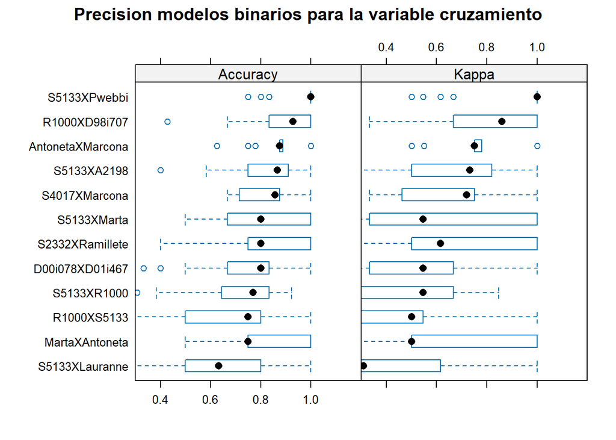

```r
bwplot(modelos.resample, main="Precision modelos binarios para la variable cruzamiento",  xlim = c(0.3, 1.2))
```

```r
difest <- diff(modelos.resample, adjustment = "none")
summary(difest)
```

```
##
## Call:
## summary.diff.resamples(object = difest)
##
## Upper diagonal: estimates of the difference
## Lower diagonal: p-value for H0: difference = 0
##
## Accuracy
##                  S4017XMarcona AntonetaXMarcona S5133XR1000 S5133XA2198
## S4017XMarcona                  -0.0301587        0.1183913   0.0138059
## AntonetaXMarcona 0.2690637                       0.1485501   0.0439646
## S5133XR1000      0.0012230     2.015e-05                    -0.1045854
## S5133XA2198      0.6531583     0.1255429        0.0166020
## R1000XD98i707    0.0887093     0.3820363        0.0001676   0.0934131
## D00i078XD01i467  0.0035681     0.0012409        0.9702796   0.0229517
## S5133XLauranne   5.727e-05     3.879e-05        0.0855815   0.0009082
## S5133XMarta      0.1808263     0.0292925        0.0851334   0.3339488
## S5133XPwebbi     6.566e-05     0.0001700        2.232e-08   5.568e-05
## S2332XRamillete  0.3032362     0.0349015        0.0314615   0.5556002
## R1000XS5133      0.0102196     0.0001482        0.4750536   0.0097622
## MartaXAntoneta   0.3502234     0.0821890        0.0713331   0.5868053
##                  R1000XD98i707 D00i078XD01i467 S5133XLauranne S5133XMarta
## S4017XMarcona    -0.0517857     0.1167857       0.2040079      0.0478968
## AntonetaXMarcona -0.0216270     0.1469444       0.2341667      0.0780556
## S5133XR1000      -0.1701770    -0.0016056       0.0856166     -0.0704945
## S5133XA2198      -0.0655916     0.1029798       0.1902020      0.0340909
## R1000XD98i707                   0.1685714       0.2557937      0.0996825
## D00i078XD01i467  0.0034801                      0.0872222     -0.0688889
## S5133XLauranne   2.365e-05     0.0903586                      -0.1561111
## S5133XMarta      0.0177304     0.1713556       0.0098372
## S5133XPwebbi     0.0283909     4.359e-06       1.010e-07      4.656e-05
## S2332XRamillete  0.0333332     0.0459870       0.0031269      0.8001276
## R1000XS5133      0.0002097     0.5832942       0.4344575      0.0464792
## MartaXAntoneta   0.0339112     0.1250437       0.0116072      0.7918623
##                  S5133XPwebbi S2332XRamillete R1000XS5133 MartaXAntoneta
## S4017XMarcona    -0.1154365    0.0373413       0.1534524   0.0378968
## AntonetaXMarcona -0.0852778    0.0675000       0.1836111   0.0680556
## S5133XR1000      -0.2338278   -0.0810501       0.0350611  -0.0804945
## S5133XA2198      -0.1292424    0.0235354       0.1396465   0.0240909
## R1000XD98i707    -0.0636508    0.0891270       0.2052381   0.0896825
```

[output cut: 33 more lines]

```
## R1000XS5133      0.0003304     0.6698338       0.3461596      0.0846909
## MartaXAntoneta   0.0447322     0.1084720       0.0091459      0.6307598
##                  S5133XPwebbi S2332XRamillete R1000XS5133 MartaXAntoneta
## S4017XMarcona    -0.2289317    0.0708352       0.2964652   0.0743650
## AntonetaXMarcona -0.1701997    0.1295672       0.3551971   0.1330970
## S5133XR1000      -0.4685983   -0.1688314       0.0567985  -0.1653016
## S5133XA2198      -0.2570537    0.0427132       0.2683431   0.0462430
## R1000XD98i707    -0.1311865    0.1685804       0.3942103   0.1721102
## D00i078XD01i467  -0.4691531   -0.1693862       0.0562438  -0.1658564
## S5133XLauranne   -0.6485181   -0.3487512      -0.1231213  -0.3452214
## S5133XMarta      -0.3409368   -0.0411699       0.1844600  -0.0376401
## S5133XPwebbi                   0.2997669       0.5253968   0.3032967
## S2332XRamillete  2.119e-05                     0.2256299   0.0035298
## R1000XS5133      1.746e-06    0.0200199                   -0.2221001
## MartaXAntoneta   0.0002537    0.9638071       0.0198541
```